# Recursive Industrial Intelligence

## II.2 The crossover model

Unit: **dollars per frontier-equivalent kilowatt-year of delivered IT load** — defined as one kilowatt-year of IT electrical load powering accelerators of frontier-generation efficiency, delivered at the case’s utilization; older-node capacity is converted by its J/FLOP penalty, so a frontier-equivalent kilowatt-year buys the same computational output regardless of which hardware generation supplies it. Three reference cases: a LEO inference service; high-orbit/cislunar batch compute; and Earth-supplied lunar-surface compute, with local manufacture entering only through the closure sweep. Mass and power budgets resolve from anchored ranges — launch price sheets (company_statement), flexible-array specific power and deployable-radiator specific mass (technical_report), accelerator system cost and lives (reporting), DC capex, PUE, WACC (reporting), qualification multiplier and utilization (ASSUMPTION, evidence-tempered) — each with a source class and per-run provenance. The space cost is affine in launch $/kg, so break-even launch prices are exact. Chip efficiency is a first-class parameter: off Earth, every watt not computed must be radiated, and radiator, PV, storage, and structure are launched mass, so a FLOPS/W advantage scales the entire power side per unit of delivered compute — efficiency and launch price enter the crossover multiplicatively, with a quantitative refinement below. This makes the popular framing of orbital compute as a launch-price race incomplete and supplies a thermodynamic rationale for internalizing chip *design*, not merely fabrication or supply security: the most efficient accelerator can tolerate a higher launch price because it carries less power and heat-rejection mass per useful computation.

Two lifecycle architectures are reported separately:

- **Integrated disposable satellite:** compute, PV, radiator, storage, structure, and original launch spend retire together.
- **Serviceable/reusable platform:** the compute payload refreshes on its hardware life while the power/thermal/structure platform and its original launch spend amortize over a longer infrastructure life. This is an explicit scenario assumption; modularity alone does not demonstrate serviceability.

For WACC $r$, useful life $T$, annual operations fraction $f_o$, insurance fraction $f_{\mathrm{ins}}$, and terminal residual fraction $\rho$,

$$\operatorname{CRF}(r,T)=\frac{r}{1-(1+r)^{-T}},
\qquad
a_s(T)=\operatorname{CRF}(r,T)
+\!f_o+f_{\mathrm{ins}}
-\operatorname{CRF}(r,T)\frac{\rho}{(1+r)^T}.$$

Scroll equation →

(40)

**Explain equation (40)**

**Annualized capital recovery**

The capital-recovery factor converts up-front cost into an equivalent annual charge, while the space annualization factor adds operations and insurance and subtracts discounted residual value.

**Terms**

**$t,\Delta t,T$**

elapsed time, discrete step, and declared horizon. **Units/domain:** years; $\Delta t,T>0$.

**$\operatorname{CRF}(r,T),f_o,a(T)$**

capital-recovery factor, fixed annual opex fraction, and annualization factor. **Units/domain:** yr$^{-1}$.

**$a_s(T),f_o,f_{\mathrm{ins}},\rho,C_{\mathrm{reg}}$**

space annualization multiplier, annual operations and insurance fractions, residual fraction, and regulatory flow. **Units/domain:** dimensionless except $C_{\mathrm{reg}}$ in constant-2025 USD/kW-yr.

**Indices and local domains**

- None.

**Operators**

- Discounting uses compound annual rates over the declared service life.

**Validity and assumptions**

- The discount rate and life are positive and all rate add-ons use annual fractions of installed capital.

**Relation:** accounting identity. **Model layer:** comparative lifecycle economics. **Implementation:** Implemented in the lifecycle-cost calculator.

Canonical definitions and scoped units.

Let $C_h$ be qualified accelerator capex, $C_I$ the sum of PV, radiator, and storage capex, $M_h$ accelerator mass, $M_I$ launched non-hardware mass after local closure, $\mu$ the destination launch multiplier, $p_L$ the LEO launch price, $U_s$ delivered utilization, and $C_{\mathrm{reg}}$ the annual spectrum and regulatory flow per installed kilowatt. The complete space expression is

$$L_s =
\frac{C_h a_s(T_h)+C_I a_s(T_I)
+p_L\mu[M_h a_s(T_h)+M_I a_s(T_I)]
+C_{\mathrm{reg}}}{U_s}
=\alpha+\beta p_L.$$

Scroll equation →

(41)

**Explain equation (41)**

**Space lifecycle cost**

Annualized orbital service cost includes compute hardware, infrastructure, launch mass, regulatory flow, and delivered utilization. Its affine form separates launch-price-sensitive cost from the non-launch intercept.

**Terms**

**$\operatorname{CRF}(r,T),f_o,a(T)$**

capital-recovery factor, fixed annual opex fraction, and annualization factor. **Units/domain:** yr$^{-1}$.

**$a_s(T),f_o,f_{\mathrm{ins}},\rho,C_{\mathrm{reg}}$**

space annualization multiplier, annual operations and insurance fractions, residual fraction, and regulatory flow. **Units/domain:** dimensionless except $C_{\mathrm{reg}}$ in constant-2025 USD/kW-yr.

**$L_s,L_E$**

space and Earth levelized lifecycle cost. **Units/domain:** constant-2025 USD per delivered kW-year.

**$C_h,C_I,M_h,M_I,T_h,T_I$**

space hardware/infrastructure capital, launch mass, and component lives. **Units/domain:** USD/kW; kg/kW; years.

**$p_L,\mu,U_s,\alpha,\beta$**

launch price, launch mass multiplier, utilization/availability factor, affine intercept, and slope. **Units/domain:** USD/kg; dimensionless; dimensionless; USD/kW-yr; kg/kW-yr.

**Indices and local domains**

- None.

**Operators**

- The affine decomposition groups all launch-independent terms into alpha and launch-mass exposure into beta.

**Validity and assumptions**

- All costs are measured per delivered frontier-equivalent kilowatt-year with matched real-dollar and utilization conventions.

**Relation:** implemented model equation. **Model layer:** comparative lifecycle economics. **Implementation:** Implemented for disposable and serviceable orbital architectures.

Canonical definitions and scoped units.

The integrated-disposable case sets $T_I=T_h$. The serviceable/reusable-platform case sets $T_I=\max(T_{I,\mathrm{anchor}},T_h)$. For Earth scenario $e$, PUE $\psi_e$, electricity price $p_e$, data-center shell capex $C_{DC}$, utilization $U_E$, and frontier-equivalent node penalty $\phi_e$,

$$L_E =
\frac{\phi_e\left[
C_{h,e}\operatorname{CRF}(r,T_{h,e})
+C_{DC}\operatorname{CRF}(r,15)
+8760p_e\psi_e\right]}{U_E}.$$

Scroll equation →

(42)

**Explain equation (42)**

**Earth lifecycle cost**

The terrestrial counterfactual annualizes accelerators and data-center infrastructure, adds electricity, adjusts for frontier-equivalent performance, and divides by utilization.

**Terms**

**$\operatorname{CRF}(r,T),f_o,a(T)$**

capital-recovery factor, fixed annual opex fraction, and annualization factor. **Units/domain:** yr$^{-1}$.

**$\phi_e,C_{h,e},C_{DC},p_e,\psi_e,U_E$**

Earth financing multiplier, hardware/data-center capital, electricity price, PUE, and utilization/availability. **Units/domain:** dimensionless; USD/kW; USD/kWh; dimensionless.

**Indices and local domains**

- None.

**Operators**

- None.

**Validity and assumptions**

- The Earth and space cases use the same delivered-compute functional unit and currency year.

**Relation:** implemented model equation. **Model layer:** comparative lifecycle economics. **Implementation:** Implemented with responsive frontier and older-node hardware cases.

Canonical definitions and scoped units.

The responsive Earth case evaluates frontier and older-node hardware and selects the lower $L_E$. Because $L_s$ is affine in launch price, the exact break-even is

$$p_L^*=\frac{L_E-\alpha}{\beta};$$

Scroll equation →

(43)

**Explain equation (43)**

**Launch-price break-even**

The break-even launch price is the price at which affine space lifecycle cost equals the matched Earth cost. A negative result means non-launch space costs already exceed the terrestrial counterfactual.

**Terms**

**$L_s,L_E$**

space and Earth levelized lifecycle cost. **Units/domain:** constant-2025 USD per delivered kW-year.

**$p_L,\mu,U_s,\alpha,\beta$**

launch price, launch mass multiplier, utilization/availability factor, affine intercept, and slope. **Units/domain:** USD/kg; dimensionless; dimensionless; USD/kW-yr; kg/kW-yr.

**$\phi_e,C_{h,e},C_{DC},p_e,\psi_e,U_E$**

Earth financing multiplier, hardware/data-center capital, electricity price, PUE, and utilization/availability. **Units/domain:** dimensionless; USD/kW; USD/kWh; dimensionless.

**$p_L^\ast$**

launch-price break-even under the affine space-cost model. **Units/domain:** constant-2025 USD/kg.

**Indices and local domains**

- None.

**Operators**

- None.

**Validity and assumptions**

- The launch-mass coefficient beta is positive and the affine cost boundary remains valid over the tested range.

**Relation:** definition. **Model layer:** comparative lifecycle economics. **Implementation:** Implemented across orbital regimes and uncertainty draws.

Canonical definitions and scoped units.

a negative value means non-launch costs alone exceed the Earth counterfactual.

For the central LEO serviceable-platform case, $C_h=\$63{,}640/\mathrm{kW}$, $C_I=\$15{,}003/\mathrm{kW}$, $M_h=17.3$ and $M_I=36.9\ \mathrm{kg/kW}$, $p_L=\$2{,}366/\mathrm{kg}$, $a_h=0.3584$, $a_I=0.2277$, $C_{\mathrm{reg}}=\$158/\mathrm{kW\!-\!yr}$, and $U_s=0.786$. Substitution gives

$$\begin{aligned}
L_s
&=
\frac{
\begin{aligned}
&63{,}640(0.3584)+15{,}003(0.2277)\\
&+2{,}366[17.3(0.3584)+36.9(0.2277)]+158
\end{aligned}
}{0.786}\\
&=\$77{,}559/\mathrm{kW\!-\!yr}.
\end{aligned}$$

Scroll equation →

(44)

**Explain equation (44)**

**Central space-cost substitution**

The central LEO serviceable-platform parameters are substituted into the space lifecycle equation to expose the arithmetic behind the reported annual cost.

**Terms**

**$a_s(T),f_o,f_{\mathrm{ins}},\rho,C_{\mathrm{reg}}$**

space annualization multiplier, annual operations and insurance fractions, residual fraction, and regulatory flow. **Units/domain:** dimensionless except $C_{\mathrm{reg}}$ in constant-2025 USD/kW-yr.

**$L_s,L_E$**

space and Earth levelized lifecycle cost. **Units/domain:** constant-2025 USD per delivered kW-year.

**$C_h,C_I,M_h,M_I,T_h,T_I$**

space hardware/infrastructure capital, launch mass, and component lives. **Units/domain:** USD/kW; kg/kW; years.

**$p_L,\mu,U_s,\alpha,\beta$**

launch price, launch mass multiplier, utilization/availability factor, affine intercept, and slope. **Units/domain:** USD/kg; dimensionless; dimensionless; USD/kW-yr; kg/kW-yr.

**Indices and local domains**

- None.

**Operators**

- None.

**Validity and assumptions**

- The displayed value uses the named central case and real-2025 USD per delivered kilowatt-year.

**Relation:** numerical substitution. **Model layer:** comparative lifecycle economics. **Implementation:** Generated from the same parameterized lifecycle-cost calculation used in the tables.

Canonical definitions and scoped units.

The matched lifecycle decomposition tests what “the cost changes kind” actually means. Values below are central annualized USD/frontier-equivalent-kW-year, with paired Monte Carlo p10–p90 in parentheses. “Omitted” is not zero social cost or a favorable result; it means that the implemented Part II boundary does not price the category.

Table 14. Matched central lifecycle-cost contributions for terrestrial and orbital compute. Download original CSV (5 KB).

| common lifecycle category | Earth base | LEO serviceable | space − Earth |
| --- | --- | --- | --- |
| site or access rights | omitted | omitted | +0 |
| regulation and permitting | omitted | 201 (74–526) | +201 |
| transport and logistics | omitted | 35,042 (21,053–60,624) | +35,042 |
| energy | 936 (651–1,302) | 260 (148–467) | −675 |
| feedstock and materials | omitted | omitted | +0 |
| extraction and processing | omitted | omitted | +0 |
| manufacturing and hardware | 11,448 (8,116–15,175) | 25,589 (15,115–42,016) | +14,142 |
| construction and commissioning | 2,286 (1,708–3,154) | 2,403 (1,609–4,585) | +117 |
| labor or human intervention | omitted | omitted | +0 |
| maintenance, replacement and insurance | omitted | 16,570 (10,588–33,290) | +16,570 |
| coordination and verification | omitted | 453 (235–1,071) | +453 |
| decommissioning and disposal | omitted | 74 (27–199) | +74 |
| externalities | omitted | omitted | +0 |
| financing | allocated within annualized asset terms | allocated within annualized asset terms | +0 |
| residual-value credit | omitted | −3,033 (−7,312–−1,358) | −3,033 |
| **implemented total** | **14,669** | **77,559** | **+62,890** |

The contribution shares do change materially: hardware is about 78% of the implemented Earth total, whereas the LEO total is led by transport (45%), hardware (33%), and maintenance/replacement/insurance (21%), before the negative residual-value credit. In this central case, changing the composition does **not** create an advantage—the space/Earth ratio is 5.29. The machine-readable table Download original CSV (5 KB) preserves all 15 categories, paired ranges, shares, and difference ranks. Its omission flags prevent the result from being read as a complete societal-cost comparison.

### The SpaceXAI economic thesis

**The strongest documented case is broader than cheap solar.** SpaceX defines cost per token as a function of the model, compute hardware, and energy. Its filings argue that near-continuous orbital solar can lower the energy term; radiative rejection can reduce cooling power; reusable launch, satellite mass production, and Starlink links can lower deployment and distribution costs; and faster access to power can put newer, more efficient chips into service before a terrestrial facility clears construction and interconnection queues. Proprietary chips and prospective vertical integration are meant to attack compute depreciation, which SpaceX itself calls the largest current cost-per-token component [S37] [S38] [S102].

That is a testable thesis, not a disclosed cost result. SpaceX tells the SEC that it does **not** publish a specific comparable cost-per-token figure, that the metric was not then used by management to evaluate performance or allocate resources, and that the filed comparison does not promise the industry’s lowest cost per token [S102]. The public record also lacks a fixed workload and quality boundary, full lifecycle bill, achieved AI1 availability and life, delivered communications goodput, and a commissioning/replacement record.

Musk supplied a separate dated prediction at the World Economic Forum on **January 22, 2026**: space would become the lowest-cost place to put AI “within two years, maybe three, three at the latest” [S103]. The comparison window is therefore January 22, 2028 through January 22, 2029. “Place to put AI” leaves the denominator ambiguous—it may mean marginal energy, installed compute, inference service, accepted output, or full lifecycle cost—so the statement is retained as a falsifiable comparison target, never as an engineering input.

Table 15. SpaceXAI proponent claim, model term, required observable, and current evidence boundary. Download original CSV (4 KB).

| proponent claim | model term | observable that would discriminate | current boundary |
| --- | --- | --- | --- |
| continuous solar lowers energy cost | energy, utilization, power overhead | delivered IT kWh, losses, degradation, achieved availability | nameplate values disclosed; full energy cost and availability absent |
| radiative rejection lowers cooling overhead | radiator and thermal-loop mass, capex, pumping | sustained heat rejection, junction temperature, full-loop mass/power/life | 110 m² disclosed; system performance and cost absent |
| reuse lowers deployment cost | launch $/kg, cadence, vehicle depreciation | achieved reusable payload, allocated cost/kg, turnaround, reliability | $185/kg is a target-derived ceiling; flight-asset depreciation remains a cost |
| satellite mass production lowers cost | manufacturing, bus, NRE | recurring factory cost/kW, yield, throughput, acceptance cost | scale asserted; unit cost and yield absent |
| high kW/t lowers launch mass | kg per sustained average delivered kW | as-flown mass and sustained service-quality IT load | AI1 states 70 kW/t; long-run target 100 kW/t; independent conventional range 34–59 kg/kW |
| proprietary chips lower depreciation | qualified hardware capex, efficiency, refresh life | qualified cost, accepted tokens/W, yield, failures, economic life | depreciation called largest component; no comparable value disclosed |
| orbital hardware amortizes long enough | hardware/infrastructure life | cohort survival, radiation faults, repair, retirement | AI1 achieved life absent |
| laser links deliver useful output | service goodput, communications capex, latency | application goodput, latency, contention, outage and gateway cost | architecture described; service result absent |
| modular replacement preserves value | replacement launch, serviceability, residual value | demonstrated exchange/repair, downtime, recovered value | no AI1 orbital repair or replacement record |
| orbit reaches useful power faster | production, launch, commissioning, ramp | matched contract-to-service and accepted-output trajectories | possible 2028 deployment; commissioning and ramp absent |
| terrestrial scarcity widens the gap | Earth power, PUE, site and schedule | matched forward power and construction trajectories | responsive/tight model cases exist; no company-matched path |
| space is lowest cost by 2028–2029 | lifecycle and accepted-output ratios plus schedule | frozen comparator, workload, quality, bill and commissioned output | company-only comparison is not computable |

#### Matching the denominator

The engineering reference remains 2026 USD per frontier-equivalent kW-year: it exposes spacecraft mass, qualification, life, replacement, availability, communications, and financing. The commercial translation is **inference-only**. It fixes one reference model, FP8 precision, batch 64, 1,024 input and 256 output tokens, a frozen held-out acceptance rule, and the same lifecycle boundary. For environment $e$, accepted annual output is defined inline as $N_{\mathrm{acc},e}=8760q_{\mathrm{req}}n_{\mathrm{out}} a_Qg_e$, and accepted-output cost as $C_{\mathrm{acc},e}=10^6C_e/N_{\mathrm{acc},e}$. Here $q_{\mathrm{req}}$ is raw fixed-workload requests per delivered kWh, $n_{\mathrm{out}}$ is output tokens per request, $a_Q$ is the held-out quality-pass fraction, and $g_e$ is the fraction delivered inside the latency, network, and service boundary. Training tokens and changes in model quality are excluded. Because $C_e$ already divides by physical utilization, $g_e$ does not count physical uptime twice.

Table 16. Denominator-matched SpaceXAI economic comparison under one fixed inference workload and lifecycle boundary. Download original CSV (3 KB).

| case | evidence boundary | lifecycle $/kW-yr | versus Earth | $/million accepted output tokens | accepted-output ratio |
| --- | --- | --- | --- | --- | --- |
| terrestrial reference | generic Earth base | 14,669 | 1.00× | 12.10 | 1.00× |
| generic orbital model | generic serviceable LEO | 77,559 | 5.29× | 81.01 | 6.70× |
| independent conventional-mass reference | 46.5 kg/kW midpoint of 34–59 kg/kW; other terms held common | 71,304 | 4.86× | 69.82 | 5.77× |
| `spacexai_proponent_case` | dated company quantities only | not computable | — | not computable | — |
| `spacexai_proponent_hybrid` | company targets plus visible model completions | 15,957 | 1.09× | 14.71 | 1.22× |

The company-only case is deterministic but incomplete: every dated company quantity is retained, while hardware capex, manufacturing cost, life, availability, communications goodput, replacement, and useful-capacity ramp remain `not_disclosed`. Its Download original CSV (4 KB) therefore does not produce a cost. The Download original CSV (5 KB) separately exposes the $185/kg and 100 kW/t company targets and the non-company completions—1.2× qualification, seven-year life, 0.95 utilization, 0.85 service goodput, and a nine-month ramp. It is a model boundary, not “Musk’s cost estimate.”

#### Time to useful compute and joint conditions

Ordinary WACC does not price the option value of earlier useful capacity. A separate schedule calculation therefore starts at January 22, 2026, applies a common 10% discount rate, and integrates accepted output through both forecast deadlines. The Earth scenario assumes two years for construction, interconnection, and commissioning followed by a six-month ramp. The company-only case preserves the possible-2028 deployment statement but returns `not_computable` because commissioning and useful-output ramp are undisclosed. The hybrid starts useful output on January 22, 2028 and assumes a nine-month ramp. Through January 22, 2029, it supplies 0.528 billion discounted accepted tokens per final kW versus Earth’s 0.710 billion, or 0.743×. Matching Earth’s dated output requires, one axis at a time, first useful output within about **1.79 years** of the statement or a ramp below about **0.33 years**. These are thresholds, not forecasts. The complete Download original CSV (2 KB) keeps every schedule class and missing value visible.

Table 17. One-at-a-time sensitivity around `spacexai_proponent_hybrid`; every unvaried term remains at the registered hybrid boundary. Download original CSV (5 KB).

| one-at-a-time condition | tested range | lifecycle ratio range | accepted-output ratio range | parity threshold within range |
| --- | --- | --- | --- | --- |
| launch price | $0–3,000/kg | 1.05–1.59× | 1.18–1.77× | none |
| total mass | 5–20 kg/kW | 1.07–1.12× | 1.20–1.25× | none |
| qualification | 1.0–3.0× | 0.94–2.46× | 1.05–2.75× | LCO at 1.085×; no accepted-token parity |
| hardware life | 3–10 yr | 1.60–0.98× | 1.78–1.10× | LCO at 9.29 yr; no accepted-token parity |
| utilization | 0.65–0.99 | 1.59–1.04× | 1.78–1.17× | none |
| hardware capex | $20,000–45,000/kW | 0.72–1.40× | 0.80–1.56× | LCO at $30,319; accepted output at $26,456 |
| space WACC | 0.08–0.22 | 0.89–1.31× | 0.99–1.47× | LCO at 0.119; accepted output at 0.082 |
| service goodput | 0.50–1.00 | 1.09× | 2.07–1.03× | none |

Figure 8 shows the full one-at-a-time accepted-output spread, including schedule variables that affect dated output without changing steady-state LCO.

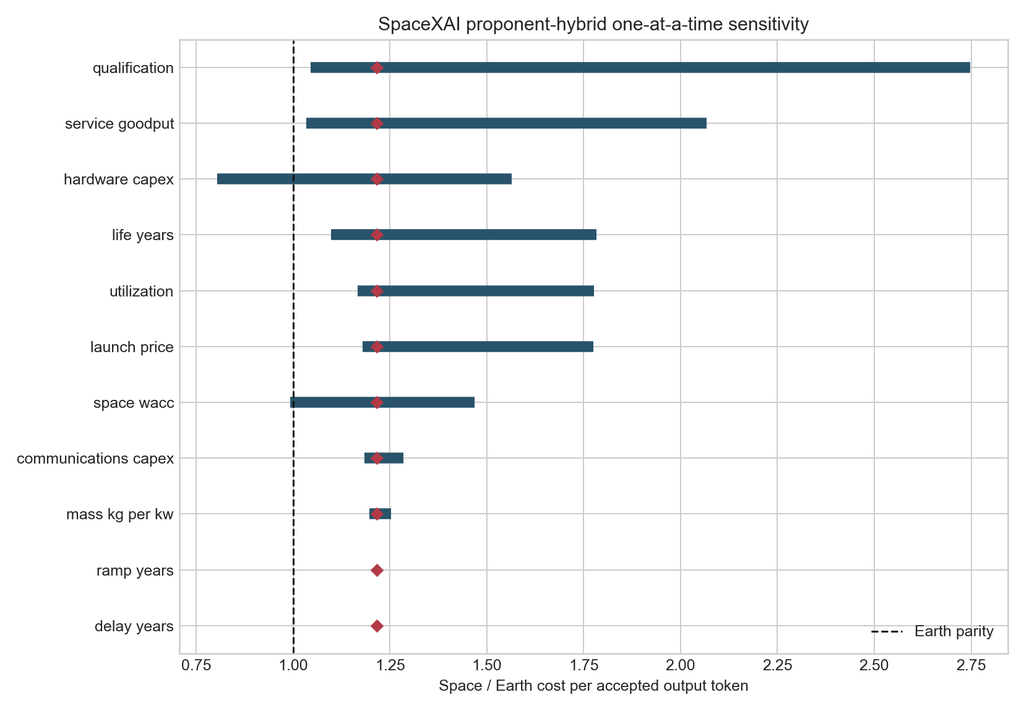

Figure 8. One-at-a-time SpaceXAI proponent-hybrid sensitivity. Horizontal spans show the accepted-output cost ratio produced by each registered low and high endpoint; diamonds mark the hybrid base and the dashed line marks Earth parity.

No single launch-price, mass, utilization, communication, or goodput change in the registered range makes the hybrid cheaper on both denominators. An explicitly **joint** favorable corner—$0/kg launch, 5 kg/kW, 1.0× qualification, ten-year life, 0.99 utilization, zero communications capex, $20,000/kW hardware, 8% space WACC, full service goodput, first output in 1.75 years, and a three-month ramp—does reach 0.39× Earth LCO, 0.37× accepted-output cost, and 1.61× Earth’s discounted output by January 2029. That corner establishes genuine agreement: orbital solar and an extremely favorable integrated architecture can win. The present disagreement is over the simultaneous achievement of qualification, hardware cost, lifetime, availability, thermal-system mass, replacement, communications, and schedule—not over personalities and not over solar’s direction of effect.

A fourth, explicitly conditional **SpaceXAI — AI1 disclosed design** does not replace those references. SpaceX publishes a 150 kW peak / 120 kW average compute payload, 150 kW solar array, 70 kW/tonne vehicle efficiency, 110 m² liquid radiator, and deployed dimensions of 20 by 70 m [S38]. The model uses the array/average-load ratio of 1.25. Because the page does not say whether the 70 kW/tonne numerator is peak or average, aggregate vehicle mass is sampled over the derived **14.3–17.9 kg per average kW** range and the direct disclosures retain `company_statement` provenance while the interpretation range is labeled `ASSUMPTION`. Radiator area, dimensions, redundant loops, shielding, and laser links are recorded but receive no invented mass or cost where none is disclosed. Hardware cost, qualification, life, achieved availability, and launch price retain the existing anchors.

The lifecycle split is explicit and assumption-class. AI1 publishes only aggregate vehicle mass, so the model first constructs the generic accelerator/PV/radiator/storage/structure mass budget and then scales every component by one common factor until its sum equals the sampled AI1 total. The resulting generic **hardware-versus-infrastructure proportion** assigns accelerator mass to the hardware refresh life and the balance to the infrastructure life in the serviceable case; the disposable case amortizes both on the hardware life. Capex is not inferred from vehicle mass: qualified generic accelerator capex is retained, while generic PV, radiator, and storage capex is evaluated at AI1’s disclosed 1.25 array-to-average-load ratio. The aspirational 10 kg/kW case uses the same proportional split. Neither that mass decomposition nor physical serviceability is disclosed by SpaceX; both are `ASSUMPTION`, and the serviceable AI1 and 0.76× boundary depend on them.

A fifth case is a deliberately optimistic, deterministic boundary rather than a new baseline: **SpaceXAI — long-term targets plus favorable model assumptions**. It uses SpaceX’s formal ≥99% launch-cost-reduction target as **$185/kg** and the prospectus’s long-term **100 kW/t** orbital-compute scaling assumption (10 kg per average kW) [S37]. Because the company does not publish achieved AI1 qualification cost, useful life, or compute availability, the case separately labels as `ASSUMPTION` the favorable existing model bounds: 1.2× qualification, seven-year hardware life, and 0.95 utilization. It is excluded from Monte Carlo. Treating a target and three selected favorable bounds as probability distributions would manufacture a spurious probability of success.

**Dated scenario policy.** The named line is retained for the specificity of its public design inputs, not because SpaceXAI is the only orbital-AI program. As of July 28, 2026, the comparison class is publicly documented programs proposing or demonstrating space-based machine-learning or data-center compute, together with the launch, spacecraft, communications, and industrial capabilities of their named legal entities or disclosed partners. In that class, Google and Planet target two Project Suncatcher prototype satellites for early 2027 [S92]; Starcloud reports an H100 demonstrator launched in November 2025 [S93]; and Blue Origin’s Project Sunrise application was accepted for filing, not authorized or deployed [S94].

Every relevant model family therefore keeps the same ordered tracks: `generic_reference`, `independent_reference`, `spacexai_disclosed_design`, `spacexai_stated_aspiration`, and an affiliate hybrid only where a separately identified input is necessary. An independent result appears only when units and denominators match; otherwise the registry publishes `not_parameterizable` and the missing fields. The Download original CSV (9 KB), Download original CSV (43 KB), and Download original CSV (10 KB) preserve stable scenario identifiers, evidence classes, source snapshots, parameter completeness, actor boundaries, and the reasons a numerical line cannot be constructed. The disclosed design supplies six of the 24 full-lifecycle fields; the target case supplies nine only after its analyst-selected completion values are counted. No target, specification, or filing is represented as commissioned capacity.

**Thermal closure is a system, not a radiator-panel coefficient.** NASA’s flight and mission studies distinguish 2.75 kg/m² ISS radiator panels from **8.8 kg/m²** after fluid loops and deployment are included; a JIMO study estimated **5 kg/m²** for the complete system. At 353 K radiator temperature, 0.86 emissivity, and a 173 K environmental sink, the cited sizing is about 1.4 m²/kW, implying roughly **7–12 kg/kW** for the complete heat-rejection system [S43]. This supports the middle and upper part of the model’s 3–12 kg/kW range, but shows that its low end represents advanced emitters, not a demonstrated full stack of cold plates, pumps, transport lines, deployment, and controls.

AI1 makes the ambiguity visible. Its published 110 m² radiator for 120 kW average compute is 0.92 m²/kW of quoted area [S38]. The one-face versus two-face convention alone moves the idealized surface-temperature result materially.[^2] The disclosure is not thermodynamically impossible, but its area convention, coolant temperature, and full thermal-system mass are crossover-critical unresolved measurements.

The terrestrial counterfactual **responds** — the epistemic requirement the static comparison missed. Three scenarios: *tight* prices scarcity (the politics-binds branch: permitting and climate commitments hold); *base* takes the anchors; *responsive* prices induced supply at the cheapest permitted firm-power floor — nuclear PPA, or the politically conditional natural-gas floor at $0.04–0.06/kWh (CCGT under $1,000/kW, ~2-year builds [S35]) — with an older-node hardware option taken when it wins on compute-normalized cost. Aspirational launch targets are sweep axes except in the explicitly labeled deterministic best case above; they never enter the probabilistic baseline.

**Starship V3/V4 aspiration, normalized.** SpaceX’s June 2026 prospectus does not quote a V3 or V4 customer price or a vehicle-specific cost per flight. It states instead that fully reusable V3 is designed to carry 100 metric tonnes to orbit, that a future generation could reach 200 tonnes as soon as V4, and that mature Starship is intended to reduce the historical $18,500/kg cost benchmark by 99% or more [S37]. Exactly 99% implies **$185/kg**; “or more” implies a lower value. Table 18 converts that formal aspiration and three more aggressive sensitivity cases into full-payload flight-cost equivalents:

Table 18. Mature-Starship launch-cost sensitivity axes and full-load equivalents.

| LEO sensitivity case | $/kg | V3: 100 t full-load equivalent | V4: 200 t full-load equivalent | status |
| --- | --- | --- | --- | --- |
| formal corporate aspiration | ≤$185 | ≤$18.5M | ≤$37M | derived from the stated ≥99% reduction; not a price quote |
| aggressive mature-Starship case | $100 | $10M | $20M | scenario axis |
| extreme fuel-like case | $50 | $5M | $10M | scenario axis |
| extreme lower case | $30 | $3M | $6M | scenario axis |

The dollar-per-flight columns are arithmetic (`$/kg × full payload`), not company forecasts.[^3] Under-filled flights cost more per delivered kilogram; external customer prices can exceed internal marginal cost; and none of these figures includes a demonstrated cadence, reuse count, refurbishment burden, or capital-recovery schedule. This analysis therefore uses **$185/kg as the traceable corporate aspiration, $100/kg as an aggressive case, and $30–50/kg only as an extreme fuel-like sensitivity band**. All remain comparison axes; $185/kg also enters the quarantined deterministic best case, never the Monte Carlo.

Two financing caveats are deliberate modeling choices. Earth uses an 8–15% WACC range and space a separate 10–22% range. Qualification multiplier, service life, repairability, and utilization are still sampled as separate anchored quantities; the favorable corner likely has correlated engineering causes, so its deterministic result is a boundary rather than a joint probability claim. Calibration: the Earth base case works out to ≈$1.7/kWh, matching published accelerator rental rates.

**Cost accounting — included and excluded.** Included: IT hardware with qualification premium; PV, radiators, storage, structure and their launched mass (with cislunar/lunar delivery multipliers); pumping power, rejection temperature, chip-to-radiator temperature drop, environmental view factor, and a thermal-reliability mass margin; spacecraft bus, communications, ground network, program NRE, insurance, spectrum/regulatory cost, disposal, and residual value; capital recovery at the architecture-specific WACC with component-specific lives; compute-hardware replacement and its launch mass on the refresh cycle; an operations fraction for ongoing ground segment, downlink, and station-keeping; utilization derating; Earth-side DC capex, PUE, hardware refresh, and firm-power floors. Excluded: launch-site, landing, turnaround, and fleet infrastructure beyond whatever is implicit in the $/kg target; launch failure beyond the insurance proxy; collision externalities and constellation-replenishment logistics; tax treatment; and architecture-specific link budgets or regulatory outcomes. Turyshev’s independent inequality remains a useful cross-check: at 40 kg/kW, a terrestrial infrastructure allowance of $10,000–40,000/kW permits only **$250–1,000/kg for launch and spacecraft build combined** before communications, operations, utilization, and finite-life penalties [S39]. The net direction of the remaining exclusions is **not** claimed to be uniformly conservative. The reported multiples are stylized-architecture outputs with wide `ASSUMPTION` ranges; the robust conclusion is structural — *which* terms dominate — not the exact ratios.

[^2]: If 110 m² is physical footprint and both faces emit, the mean flux is about 545 W/m² and the ideal surface is about 332 K (59 °C); if it is total emitting area, the values are about 1,090 W/m² and 391 K (118 °C). The check uses $q=\epsilon\sigma(T^4-T_{\mathrm{env}}^4)$ with the NASA reference conditions [S43], and omits view factors, degradation, nonuniformity, pumping, and the chip-to-radiator temperature drop.
[^3]: The V4 full-load totals rise because Table 18 holds dollars per kilogram constant while payload doubles. Holding flight cost instead constant gives the inverse comparison: a $10 million flight is $100/kg on a full 100-tonne V3 and $50/kg on a full 200-tonne V4.

## II.3 Results

Central reference values plus the deterministic aspiration case ($ per kW-yr, rounded to three significant figures — these are assumption-conditioned outputs, not measurements; exact machine-readable values regenerate in `outputs/`):

Table 19. Deterministic lifecycle-cost results across modeled architectures and scenarios.

| case | architecture | LCO | launched mass | vs Earth base (≈14,700) |
| --- | --- | --- | --- | --- |
| LEO inference | serviceable/reusable platform | 77,559 | 54 kg/kW | 5.29× |
| LEO inference | integrated disposable satellite | 98,871 | 54 kg/kW | 6.74× |
| cislunar batch | serviceable/reusable platform | 131,524 | 54 kg/kW | 8.97× |
| cislunar batch | integrated disposable satellite | 175,418 | 54 kg/kW | 11.96× |
| lunar surface (Earth-supplied) | serviceable/reusable platform | 3,864,754 | 480 kg/kW | 263× |
| lunar surface (Earth-supplied) | integrated disposable satellite | 6,209,841 | 480 kg/kW | 423× |
| SpaceXAI — AI1 disclosed design | serviceable/reusable platform | 46,523 | 16 kg/kW | 3.17× |
| SpaceXAI — AI1 disclosed design | integrated disposable satellite | 55,748 | 16 kg/kW | 3.80× |
| SpaceXAI — long-term targets plus favorable model assumptions | serviceable/reusable platform | 15,957 | 10 kg/kW | 1.09× |
| Earth tight | — | 15,980 | — | — |
| Earth responsive | — | 12,783 | — | — |

The integrated-disposable and serviceable-platform rows use different lifecycle boundaries.[^4] The lunar case is labeled **Earth-supplied** because its central closure fraction is zero; local manufacture enters only through the closure sweep axis.

Monte Carlo over anchored ranges, shared draws both sides (n = 2,000 sampled runs per row; frequencies under this ensemble, not empirical probabilities). The stated-aspiration case is excluded because its company targets and favorable unpublished assumptions are point sensitivities, not probability distributions:

Table 20. Paired Monte Carlo lifecycle-cost ratios and break-even launch prices.

| case | architecture | vs Earth | ratio p10/p50/p90 | space-cheaper runs | break-even $/kg p50 (p90) |
| --- | --- | --- | --- | --- | --- |
| LEO inference | serviceable/reusable | base | 3.6 / 5.7 / 8.8 | 0 / 2,000 | −987 (−385) |
| LEO inference | serviceable/reusable | responsive | 4.5 / 7.1 / 11.4 | 0 / 2,000 | −1,129 (−543) |
| LEO inference | integrated disposable | base | 4.6 / 7.3 / 11.5 | 0 / 2,000 | −883 (−425) |
| LEO inference | integrated disposable | responsive | 5.5 / 9.0 / 14.8 | 0 / 2,000 | −980 (−491) |
| cislunar batch | serviceable/reusable | base | 5.8 / 9.7 / 16.6 | 0 / 2,000 | −291 (−96) |
| cislunar batch | serviceable/reusable | responsive | 6.9 / 12.1 / 20.8 | 0 / 2,000 | −349 (−136) |
| cislunar batch | integrated disposable | base | 7.4 / 12.8 / 22.7 | 0 / 2,000 | −277 (−108) |
| cislunar batch | integrated disposable | responsive | 9.0 / 16.0 / 28.3 | 0 / 2,000 | −308 (−145) |
| lunar surface (Earth-supplied) | serviceable/reusable | base | 112.0 / 263.9 / 652.8 | 0 / 2,000 | −21 (−9) |
| lunar surface (Earth-supplied) | serviceable/reusable | responsive | 138.5 / 343.8 / 821.2 | 0 / 2,000 | −22 (−10) |
| lunar surface (Earth-supplied) | integrated disposable | base | 183.3 / 449.4 / 1,092.7 | 0 / 2,000 | −16 (−7) |
| lunar surface (Earth-supplied) | integrated disposable | responsive | 232.4 / 562.4 / 1,313.0 | 0 / 2,000 | −17 (−8) |
| SpaceXAI — AI1 disclosed design | serviceable/reusable | base | 2.3 / 3.3 / 4.9 | 0 / 2,000 | −3,567 (−1,624) |
| SpaceXAI — AI1 disclosed design | serviceable/reusable | responsive | 2.7 / 4.2 / 6.4 | 0 / 2,000 | −4,087 (−1,964) |
| SpaceXAI — AI1 disclosed design | integrated disposable | base | 2.7 / 4.0 / 5.9 | 0 / 2,000 | −3,097 (−1,590) |
| SpaceXAI — AI1 disclosed design | integrated disposable | responsive | 3.3 / 4.9 / 8.0 | 0 / 2,000 | −3,579 (−1,924) |

Earth and space see the same sampled hardware properties in every draw, while their WACC anchors remain deliberately separate.[^5] The frequencies belong to this declared ensemble and are not empirical probabilities.

All sixteen architecture/reference rows have zero sampled points below parity in 2,000 draws. This is a design-space statement under the declared sampling measure, not a confidence bound on real-world success. Figure 9 shows the separation from parity across the sampled cells without assigning real-world probabilities to them.

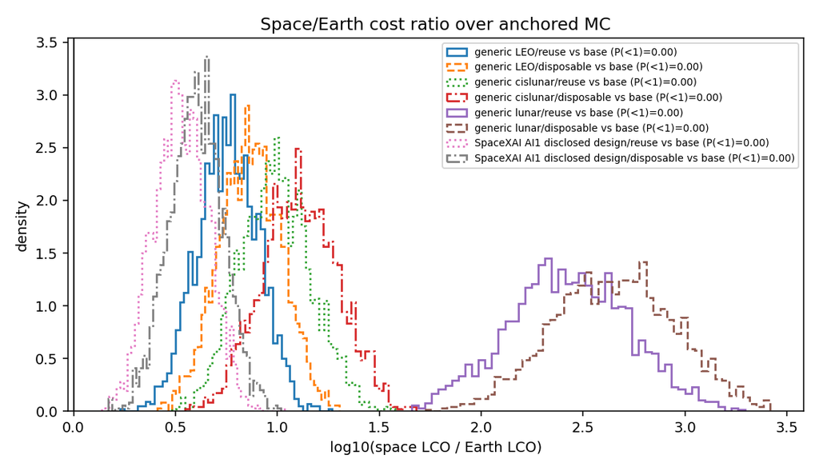

Figure 9. Distribution of the space/Earth cost ratio over the anchored Monte Carlo, shared draws both sides. No draw crosses parity in any architecture/reference cell.

AI1’s aggregate mass disclosure is material but not sufficient at the retained central values: it cuts launched mass from about 54 to 16 kg/kW and LCO from about $77,600 to $46,500/kW-yr, yet fixed non-launch costs still exceed Earth base (central break-even approximately −$3,460/kg). With the remaining anchors simultaneously favorable — qualification ×1.2, seven-year life, and 0.95 utilization — AI1 is 1.74× Earth at the central launch anchor, has no positive break-even launch price (approximately −$191/kg), and reaches 1.13× at $250/kg. Completing communications, bus, NRE, insurance, spectrum, disposal, thermal-margin, and financing terms leaves no favorable-corner crossover at these assumptions.

The aspirational case makes that conditionality explicit. The two company numbers alone—$185/kg and 100 kW/t—still produce about **$34,200/kW-yr, 2.33× Earth base** when qualification, life, and utilization remain at their central values. Selecting the three favorable non-company bounds as well produces about **$16,000/kW-yr, 1.09× Earth base**. The incomplete-cost boundary produces 0.76×; including the omitted system terms reverses that result. All five favorable conditions must hold together, and the model assigns no probability to them.

The company’s own scale target exposes the feasibility burden. At 100 GW deployed annually and 100 kW/t, the flow is **one million tonnes/year**: 10,000 full 100-t V3 launches (27.4/day), or 5,000 full 200-t V4 launches (13.7/day), and roughly 833,000 AI1-sized 120-kW-average spacecraft. Even at $185/kg, launch cost alone is $185 billion/year before spacecraft manufacture. At the later AI1 page’s disclosed 70 kW/t, the same flow rises to 1.43 million tonnes and 14,286 full V3 launches/year. The current design is therefore 30% below the older 100 kW/t assumption; reaching it requires 43% more kW/t. Full rapid reuse, daily turnaround at unprecedented cadence, upper-stage recovery, fleet size, range capacity, and manufacturing are load-bearing. So are seven-year whole-system reliability and 95% compute utilization, neither published for AI1. Collision externalities, constellation replenishment logistics, and landing/turnaround infrastructure remain excluded, while terrestrial energy, chips, cooling, permitting, and construction can also improve. The prospectus itself identifies approvals and spectrum as dependencies and warns that better terrestrial energy could reduce the orbital advantage [S37].

The lifetime interpretation is architecture-dependent. The model’s 10–25-year infrastructure life is defensible only if the power and thermal platform survives multiple accelerator generations and the compute payload can actually be exchanged, serviced, or economically separated. For an integrated, non-serviceable LEO vehicle, the relevant infrastructure life is instead close to the spacecraft or compute life—typically about five years in the studies reviewed here [S39–S42]. The serviceable-platform and integrated-disposable results above expose both lifecycle readings. Shortening every component to five years is appropriate for an integrated vehicle, but too pessimistic once modular payload replacement is demonstrated. Platform reuse is a named architecture gate, not an innocuous amortization choice.

A negative break-even means fixed, non-launch costs alone exceed the Earth cost: at those draws no launch price, even zero, closes the gap. The structural finding: **the crossover is gated by the space-qualification premium, equipment life, and utilization — not launch price alone.** The generic-LEO crossover surface (launch $/kg × life × qualification × radiator × closure × chip efficiency) shows no ratio-below-1 region at published prices on any single axis, and near-parity only in the defined Starship aspiration cases ($185/kg formal; $100/kg aggressive; $30–50/kg extreme) combined with favorable values on at least two other axes. AI1’s disclosed aggregate mass is a multi-parameter architecture constraint rather than a single-axis point on that generic surface; it produces the conditional near-published break-even above while leaving no competitive draw in either lifecycle ensemble. At the central LEO architecture’s approximately 54 kg/kW, those prices correspond to initial launch expenditures of about **$9,990, $5,400, $2,700, and $1,620 per installed IT kW**, respectively, before annualization. They largely remove the current launch bill, but a negative break-even still means they cannot overcome the fixed qualification/life/utilization gap on their own. Lunar closure is the weakest lever: chips are never closed, so even 95% closure of non-chip mass leaves the lunar case roughly 15–30× Earth at published prices — still more than an order of magnitude from parity. Figure 10 displays the five one-axis sweeps on a common logarithmic cost-ratio scale.

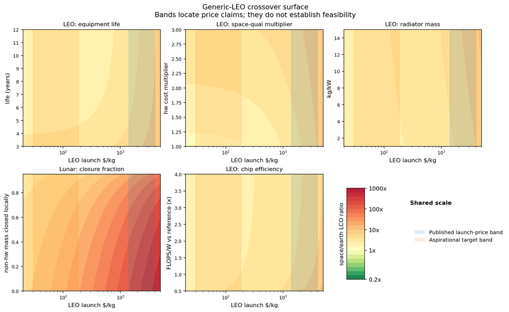

Figure 10. The generic-LEO crossover surface: space/Earth cost ratio against launch price with each companion axis varied over its anchored range. No single-axis path reaches parity at published prices.

The mass-multiplier refinement: at anchored values a 2× FLOPS/W advantage buys about 50% of the benefit of halving launch price (ratio 5.1 vs 4.2 at $3,000/kg, both from 6.1), because the hardware term — untouched by efficiency — dominates both mass and capex. “The compute tax outweighs the launch tax” [S34] becomes true only after the qualification premium and hardware $/kW fall; near-term, both taxes are subordinate to qualification and life.

[^4]: Integrated-disposable rows annualize PV, radiators, storage, structure, and emplacement launch on the short compute-refresh life. Serviceable-platform rows instead use the declared `infrastructure_life_years` range of 10–25 years, while replacement chips and their launch mass recur on the compute life; Appendix B gives the full cost boundary.
[^5]: Each anchor draw is cached per iteration and keyed by a process-stable seed, making the tables deterministic across processes. Appendix C specifies the keyed-draw and seed protocol.

## II.4 External claim and independent-study checks

The public crossover claims are recorded as comparison targets (never inputs). The completed-cost model does not reproduce the stronger Google/Planet crossover claim, even at its favorable anchored corner; this converts the disagreement into an architecture- and accounting-wide, testable one. The post-IPO review of independent studies below then checks the model rather than merely restating corporate claims. The Suncatcher design study does **not** claim system-level parity. Its cost section states twice that it is not a full economic analysis and not a comprehensive economic feasibility study, and its comparison sets the **amortised launch component alone** (≈$810/kW-yr for a Starlink-v2-class mass-to-power ratio at $200/kg; $810–7,500 across satellite classes) beside terrestrial data-center **electricity spend** (≈$570–3,000/kW-yr), explicitly excluding infrastructure, building, and chip costs [S32]. That is a launch-cost feasibility marker — the finding that launch need not remain independently prohibitive — not a parity claim, and it is consistent with this model, which reproduces launch as a minor term. The crossover claim this model contradicts is the stronger reading in circulation [S34], not the study’s own.

- **The Google/Planet study** (reported: crossover at $200–300/kg [S34]). At $250/kg with central anchors: space/Earth = 2.61 — no crossover. Under the favorable corner *within anchored ranges* (qualification ×1.2, 7-year life, 0.95 utilization, 3 kg/kW radiators): **1.26** — still no crossover. The disagreement is no longer localized to launch price or three performance inputs; the completed non-launch system boundary is load-bearing.
- **The Suncatcher design study** [S32] describes an 81-satellite dawn-dusk sun-synchronous cluster near 650 km with terabit-class optical links (an 800 Gbps unidirectional bench demonstration against a stated ~10 Tbps per-link requirement) and a learning-curve projection of ≲$200/kg by the mid-2030s — itself conditional on roughly 370,000 tonnes of additional cumulative mass launched, on the order of 1,800 Starship-class flights averaging ~180 per year, which the authors call ambitious. Its engineering results should be read precisely (arXiv v2, 17 June 2026):
  - HBM was the most **TID**-sensitive subsystem — irregularities from ~2 krad(Si) against a ~750 rad(Si) shielded five-year requirement, with no hard total-dose failures to 15 krad(Si) — while core logic and on-chip SRAM were the most **SEE**-sensitive. The reported inference error probability is roughly one per three million inferences under the stated assumptions, with the effect on **training** explicitly reserved.
  - At ~150 rad(Si)/yr, a seven-year dose (~1.05 krad) sits below the ~2 krad irregularity onset — the radiation results support five-year TID survivability with margin and *do not obviously contradict seven-year TID survival*.
  - What they do not establish is seven-year **system** reliability: SEE-induced corruption, host interruptions, training sensitivity, thermal management, and whole-spacecraft failure remain unresolved, with orbital repair called impracticable and redundant provisioning proposed instead — a cost, not an absence of one. The COTS practice supporting a low qualification premium (unmodified accelerators flying on imaging satellites [S34]) demonstrates cheapness, not five-year reliability.

The independent checks localize four additional gates:

- **Conventional mass and economic closure.** Turyshev closes PV, eclipse reserve, thermal rejection, fixed spacecraft functions, sustained communication, utilization, and finite life in a single framework [S39]. Its 34–59 kg/kW total independently brackets and supports the generic central mass at the order-of-magnitude level. Its more important result is the combined launch-plus-build ceiling: $250–1,000/kg at 40 kg/kW before communications and lifecycle penalties. Every additional $1,000/kW of communication or operations cost reduces that allowance by $25/kg. Current public launch prices consume more than the entire allowance before a spacecraft is built.
- **Low-mass architectures are conditional, not contradictory.** The integrated-panel and tether studies reach 8.9 and roughly 5 kg/kW respectively [S40], demonstrating that mass is an architecture variable rather than a universal constant. Both target inference and both exchange conventional subsystem maturity for deployment, structural, thermal, and custom-silicon risk. They justify explicit stretch scenarios; they do not justify assigning conventional spacecraft a five-kilogram prior.
- **Inference and training are different products.** Van Berkel compares a terrestrial 8,000-accelerator Clos fabric with orbital meshes: about 28,800 TB/s of terrestrial bisection bandwidth versus approximately 2.25 TB/s for a two-dimensional and 10 TB/s for a three-dimensional orbital mesh at 100 Gbps links, with network latency 150–450 times higher [S41]. Even much faster optical links do not remove multi-hop diameter and collective-communication latency. The appropriate early comparison is therefore per-satellite or loosely coupled **inference**, preprocessing, and communication-integrated edge work—not frontier distributed training. Training should receive a network-performance model, not an ordinary utilization scalar.
- **Small space-native nodes already have a different cost structure.** The peer-reviewed HPCA microdatacenter study finds power and thermal systems dominate bespoke small-satellite TCO, while compute hardware can be less than one percent; energy-efficiency improvements can reduce TCO by about two-thirds and are up to 2.5 times more valuable in space [S42]. This is encouraging for 0.5–10 kW Earth-observation preprocessing, where data originates in orbit and downlink is avoided. It is not evidence that a megawatt terrestrial-substitution service has the same economics.

The broader policy cross-check reaches the same conditional result by a different route. A University of Virginia assessment reports a simplified five-year 1 GW case at $135.6 billion in orbit versus $16.6 billion on Earth under present-style assumptions; near-parity appears only when launch falls to $30/kg, satellite hardware to $10/W, specific power rises to 100 W/kg, sunlight availability to 80%, and degradation and GPU failure both fall to 1% [S44]. Its model omits GPU cost, financing, insurance, logistics, and downtime and should not be treated as a precise forecast. Its contribution is the joint-condition result: parity emerges from several simultaneous improvements, not from launch price alone.

Consequence for the staircase, stated within the model’s service definition: **the modeled orbital architectures are not cost-competitive as substitutes for terrestrial frontier compute at the stated assumptions.** That conclusion has a workload boundary: it applies directly to per-node inference in the cost model, while the cited network evidence makes frontier distributed training less favorable than the scalar model shows. It does not price differentiated orbital products (in-orbit sensor processing, sovereign or military demand, resilience niches), which could be profitable while losing the commodity comparison. What follows for the staircase is correspondingly bounded: *commodity-scale* deployment ahead of the enabling corner is strategic positioning or learning investment rather than substitute-compute profit — an observation Part III converts into a discriminating test.

The electrical comparison is also reported in workload-specific units so a kW-year is not silently treated as equivalent computational output:

Table 21. Workload-normalized costs for central terrestrial and orbital service cases.

| central service case | cost per million defined inferences | cost per network-effective training kW-year |
| --- | --- | --- |
| Earth base | $3,197 | $17,989 |
| generic LEO, serviceable | $16,902 | $490,528 |
| SpaceXAI — AI1 disclosed design, serviceable | $10,138 | $294,235 |

The inference denominator is an `ASSUMPTION`-class workload requiring a named model, latency, accuracy, batch, memory, precision, and availability envelope. The training denominator applies explicit central network efficiencies of 0.158 in space and 0.815 on Earth. These values expose the interconnect gate; they are not benchmark measurements.

## II.5 Competition and milestone order

A one-dimensional “takeoff speed” label hides the relative order of digital, embodied, capital, and control milestones. The branch screen therefore crosses fast/slow digital progress with fast/slow physical closure. Its years are named `ASSUMPTION` coordinates, not forecasts:

Table 22. Milestone order under fast and slow digital and physical progress branches. Download original CSV (3 KB).

| branch | $T_{\mathrm{AIR\&D}}$ | $T_{\mathrm{emb}}$ | $T_{\mathrm{cl},E}$ | $T_{\mathrm{cl},S}$ | consequence |
| --- | --- | --- | --- | --- | --- |
| fast digital / slow physical | 4 | 12 | 16 | 26 | eight-year intelligence overhang before embodiment; off-world closure is post-AI construction |
| slow digital / fast physical | 18 | 6 | 9 | 14 | bounded intelligence can accompany physical closure; off-world closure precedes AI-R&D closure |
| fast digital / fast physical | 4 | 5 | 7 | 9 | both loops advance, but Earth still closes first |
| slow digital / slow physical | 18 | 14 | 20 | 28 | bridge capital and depreciation dominate both clocks |

Fast digital progress does not remove experiment, actuator, factory, material, deployment, or commissioning latency. It creates an intelligence overhang whose useful product is limited by those complementary stocks. Conversely, fast physical closure can compound with a bounded controller. The article’s off-world pathway is strategically causal rather than solely a post-AI construction program only in orderings where off-world closure changes the growth path before $T_{\mathrm{AIR\&D}}$; the sufficient screen used here is $T_{\mathrm{cl},S}<T_{\mathrm{AIR\&D}}$. The matrix does not assign that ordering a probability.

The fast-digital/slow-physical branch is a stress test against *AI 2027*, not a copy of its calendar [S80]. That source explicitly focuses on a software-driven feedback loop because improved hardware takes longer to produce at scale, distinguishes coding execution from research taste, and publishes wide uncertainty. Its site later corrected a plotted trajectory and moved a median back while retaining a fast branch. Versioning is therefore substantive: no date or compute allocation from that scenario enters this model. [S35] supplies a separate fast-takeoff and capital-mobilization countercase under its existing source entry. Its ordering permits AI-R&D automation to precede broad robotics; the article’s embodied-closure path instead asks when physical tasks and capital reproduction pass their own gates. Amodei’s complement taxonomy [S79] explains why both can be coherent: digital capability may move first while hardware, data, experiments, human constraints, and physical law continue to set the realized rate.

Control is an independent feasibility gate:

$$\Gamma_{\mathrm{ctrl}}
=\mathbf 1\!\left[T_{\mathrm{ctrl}}\le T_{\mathrm{AIR\&D}}\right]
\mathbf 1\!\left[T_{\mathrm{ctrl}}\le T_{\mathrm{cl},E}\right]
\mathbf 1\!\left[T_{\mathrm{ctrl}}\le T_{\mathrm{cl},S}\right].$$

Scroll equation →

(45)

**Explain equation (45)**

**Milestone control gate**

A branch is control-admissible only if control readiness arrives no later than AI-R&D closure and both terrestrial and space industrial closure. Capability that outruns these controls is not counted as a successful endpoint.

**Terms**

**$T_{\mathrm{AIR\&D}},T_{\mathrm{emb}},T_{\mathrm{cl},E},T_{\mathrm{cl},S},T_{\mathrm{ctrl}}$**

verified AI-R&D closure, embodiment closure, Earth/space reproductive-capital closure, and control-readiness milestones. **Units/domain:** elapsed years, each $\ge0$.

**$\Gamma_{\mathrm{ctrl}}$**

branch-level control-admissibility indicator. **Units/domain:** $\{0,1\}$.

**Indices and local domains**

- None.

**Operators**

- Each indicator tests one ordering condition; their product implements logical AND.

**Validity and assumptions**

- Milestone times share the same baseline and operational definitions.

**Relation:** constraint. **Model layer:** milestone-order screen. **Implementation:** Implemented in the milestone-order branch analysis.

Canonical definitions and scoped units.

$\Gamma_{\mathrm{ctrl}}\in\{0,1\}$ is the branch-level control-admissibility indicator and $\mathbf 1[\cdot]$ is one when its condition holds. Gross capability or capacity that arrives before the relevant authorization and verification regime is not counted as a successful endpoint.

A fifth branch makes the terrestrial counterfactual explicit. Powerful AI first accelerates terrestrial robotics, fabs, power, and launch supply; the illustrative screen closes Earth at year 10 and space at year 18 while reducing the off-world bridge-cost index to 0.65. Lower bridge cost helps space, but earlier Earth compounding raises the benchmark it must beat. Machine-readable: Download original CSV (3 KB). The fast AI-R&D countercase remains represented by [S35], without treating its calendar as established.

The system is not alone. China is the closest existing implementation of the terrestrial stages at national scale (solar, batteries, robotics, rare-earth refining, trailing-edge fabrication) lacking, for now, a reusable heavy-lift economy. Hyperscalers close the same inputs with capital rather than ownership — power agreements, custom silicon, supply contracts — which works until aggregate demand outruns what markets can scale. State programs hold ISRU roadmaps but iterate slowly.

Two corrections to the launch-chokepoint assumption, both cutting against a durable launch monopoly: payload cost-performance improved by two to three orders of magnitude over the decade against a smaller multiple for launch price [S34] — a crossover model treating launch as the primary axis mis-weights its own sensitivity analysis (borne out in II.3, where the crossover is not launch-gated); and chemical rockets are a local optimum — mass-manufactured vehicles, electromagnetic or kinetic launch, and mass drivers from a low-gravity surface (named in the fabrication initiative’s own material [S29]) would reset the launch axis rather than move along it.

**Externally induced supply versus internally controlled reproduction.** Expansion purchased through markets can pay stacked scarcity rents when demand outruns supply. Properly qualified: markets are not static — the right formulation is a race between demand growth and induced supply with multi-year capacity lags as the binding term, and whether internal replication beats inducing market expansion is a *rate comparison* (which is what the responsive counterfactual of II.2 implements on the power axis). A self-replicating base escapes *mandatory dependence on external Earth markets* — not economic allocation, opportunity cost, or internal pricing, which persist in any multi-firm or internally-priced closed ecology: expansion re-denominates from currency into materials, energy, and time. Two caveats: the entry ticket is still paid in dollars — the first self-replicating unit is bought, not grown, which is what the bridge economy exists to finance — and the logic predicts *convergence, not uniqueness*: every serious actor eventually verticalizes or plateaus; the durable advantage is the shortest hardware doubling time once everyone is. Historical reference classes calibrate “unprecedented”: Manhattan and Apollo peaked near 0.4% of GDP; British railway investment ran ~40% of GDP over a decade; wartime borrowing far exceeded either [S35]. Trillion-scale buildout is extreme but inside the envelope. The relevant question is therefore the relative rate, financing, and dependency structure—not escape from capital itself. The symmetric dynamic diagnostic gives both Earth and space endogenous investment and finds that physical space compounding does not become self-financing in either declared 40-year case.

**Integration versus modularity (the Coasean resolution).** Markets scaled semiconductors a billionfold through *dis*integration; why would this time differ? A firm’s boundary sits where internal coordination costs exceed market transaction costs [S25]. AI attacks the internal term (Part I.6) — but it attacks the external one too, improving supplier discovery, specification, contracting, monitoring, quality assurance, pricing, logistics, and modular interface design. The correct conditional is therefore that **AI moves the efficient boundary toward integration only if it reduces internal coordination costs faster than it reduces interfirm transaction costs**, an empirical question this document does not settle; what does survive is that the market interface retains an irreducible capital requirement efficiency gains do not remove. The defensible conclusion is bounded: AI may move the efficient boundary toward integration — not that ownership integration outperforms modular ecosystems in general. Three qualifications are central: markets also supply experimentation, selection, redundancy, and price signals, which an integrated complex must replicate internally or decay into soft-budget pathologies; technical closure (the network can produce its inputs) must not be conflated with contractual or ownership closure — this thesis requires only the first; and the in-domain integration success story confounds integration with reusability, cadence, and incentives [S1].

**The threshold-model argument.** If RSI capability is a threshold — a base model good enough to run verified improvement loops — a smarter starting model confers a head start that the loop erodes; the durable variable becomes who runs more loops, which is hardware. Mid-2026 evidence supports continued benchmark compression between open and proprietary models (open-weight releases benchmarking near the frontier [S12]); it does not establish commoditization at an autonomous-R&D threshold, so hardware dominance is the small-α branch of the model rather than the established trajectory. If RSI-grade capability does arrive in open weights, model advantage weakens sharply without evaporating — post-training, proprietary data, evaluation systems, inference infrastructure, tool integration, operational reliability, distribution, and the capacity to run physical experiments all persist as differentiators — and to that extent the contest shifts onto the physical loop, the strongest form of the verticalization thesis. The counterpoint: the argument holds only if capability is threshold-like rather than continuously compounding (L_RSI ∝ A<sup>α·C</sup>β·V^γ, with α unknown); benchmark convergence does not establish that autonomous R&D capability is threshold-like. And the structural counterweight: models converge because they train on the same public data, so residual differentiation concentrates exactly in proprietary physical-process data (Part I.2) — if general capability commoditizes, the model contest narrows to the domains where training data is generated by owned industry, folding the model race back into the physical loop.

# Part III — Strategy Interpretation and Governance

## III.1 Orbital compute and the physical-stack hypothesis

SpaceX’s orbital data centers may be more ambitious than the product category suggests. The hypothesis examined here is that Starmind could function as an industrial seed: an initially expensive, Earth-supplied deployment that creates anchor demand and operating experience across the physical stack for a larger AI-driven space economy. In this reading, orbital compute is the opening use case rather than the endpoint. It exercises reusable launch, spacecraft production, power, thermal management, communications, specialized chips, autonomy, servicing, and eventually materials recovery as one operating system [S27] [S38].

The associated high-conviction bet has two parts: transformative AI arrives, and its binding constraints increasingly become physical rather than purely algorithmic. Energy, chips, factories, robots, transport, and communications both support AI and give it the means to expand its own substrate. Some early assets may be above the cost-optimal frontier when built. Their strategic value would lie in establishing suppliers, factories, interfaces, operating data, and deployment cadence before more capable AI can improve them.

AI could shorten design, scheduling, yield-improvement, and maintenance cycles, although construction, qualification, heat rejection, and material flows retain physical time constants. The proposed compounding is coupled: better intelligence improves industrial capacity, and additional industrial capacity supports more intelligence.

The following mapping tests that interpretation against the public actor and capability boundary. It is an analytical interpretation of how existing companies could supply layers of the proposed system, not evidence that they share one program.

The 2026 developments (the Terafab initiative; SpaceX’s absorption of xAI) bind the transport, communications, intelligence, and fabrication layers by overlapping control, strategic coordination, and contractual collaboration. Tesla remains a separate public company; a shared controlling figure and a framework agreement are not common ownership (Form S-1 pp. 7, 10, 154) [S27].

Table 23. Publicly documented portfolio layers relevant to recursive industry.

| layer | contributor | capability | role in recursion |
| --- | --- | --- | --- |
| Intelligence | xAI (within SpaceX) | AI research, large-scale compute [S3] | design, coordination, recursive digital improvement |
| Energy | Tesla Energy | generation, storage, power electronics [S2] | power for compute, factories, robots |
| Robotic labor | Optimus | manipulation, maintenance; stated Terafab construction role | manufactured labor capacity |
| Manufacturing | Tesla | high-volume factories, batteries, motors | factory design, machine production at scale |
| Fabrication | Terafab (Tesla, SpaceX, xAI; Intel from Apr 2026) | declared: chip design, lithography operation, fabrication, memory, packaging [S6–S10, S27, S29] | declared compute-substrate layer; framework stage |
| Transport | SpaceX / Starship | reusable heavy lift | seed deployment, materials movement |
| Communications | Starlink | distributed connectivity | coordination across remote nodes |
| Compute deployment | planned D3 constellation | radiation-tolerant silicon | space-based compute as stated product |
| Data | fleet, factories, test programs | telemetry, process parameters, failure archives | the physical loop’s exhaust (I.2) |
| Industrial knowledge | Tesla / SpaceX / xAI / Terafab | CAD/CAM, simulation, software toolchains, process recipes, material models, build records, and failure archives | portable digital seed and industrial memory |
| Settlement | Mars objective | self-sufficient city as stated goal | demand center; survival independent of Earth |

**The dated comparative claim.** As of July 28, 2026, and within the comparison class of publicly documented programs proposing or demonstrating space-based machine-learning or data-center compute, SpaceXAI presents the broadest and most tightly coupled publicly disclosed **closure-seeking** stack. Its core combines reusable launch, spacecraft manufacturing, orbital communications, terrestrial AI compute and models, an AI1 vehicle design, and a filed orbital-data-center proposal. This is a comparative hypothesis about breadth and coupling, not a claim that competitors do not exist or that a complete self-sustaining stack operates. Google/Planet Project Suncatcher has planned prototypes and a technical study [S32] [S92]; Starcloud reports an orbital H100 demonstration [S93]; and Blue Origin has filed Project Sunrise [S94].

The actor boundary is load-bearing. The **SpaceXAI core** is Space Exploration Technologies Corp. and xAI within SpaceX. Tesla remains a separate public company over which SpaceXAI has no control [S95]. Its stationary storage, grid controls, battery-material work, terrestrial manufacturing, chip collaboration, and Optimus program may enter only the explicitly labelled affiliate-hybrid ecosystem. No transfer, availability, orbital qualification, or joint control is presumed. The same discipline applies to every disclosed partner.

The provenance-backed Download original CSV (64 KB) compares that bounded ecosystem with Google/Planet, Starcloud, and Blue Origin. It records the responsible legal entity, relationship, operating environment, maturity, demonstrated capacity, target, missing dependencies, source date, evidence class, common-control status, and off-world reproductive closure. Its Download original CSV (3 KB) puts the bounded SpaceXAI ecosystem first on evidence-weighted breadth: qualifying evidence appears in 17 of 18 layers, with 13 operational, two under development, two stated aspirations, and one `no_evidence` row. Only 10 of those 17 evidenced layers are under common control. The missing capital-equipment-reproduction layer is itself a minimum cut, and the published filing still records dependence on external materials, components, semiconductors, memory, and compute hardware [S27]. Terafab-specific projects and commitments remain prospective. Consequently, every program has zero demonstrated off-world-closed layers and fails dependency-aware reproductive closure. The 17-layer breadth result is not 94% closure.

The unresolved physical set includes extraterrestrial mining and beneficiation, feedstock-specific refining beyond narrow battery-material routes, qualified bulk metals and polymers, semiconductor fabrication and packaging independent of Earth suppliers, autonomous construction, in-space repair and recycling, and reproduction of machine tools, metrology, optics, bearings, and semiconductor process equipment. Biological life support is outside this article’s uncrewed machine-industry boundary; any settlement or crew-support claim would require a separate closed biological layer rather than inheriting credit from this matrix.

**The 18-function evidence crosswalk.** Table 23 is an 11-layer descriptive strategy map; it is not a coverage audit. The capacity model has ten coarse sectors. The integrated-bootstrap model resolves the nearest existing minimum-production crosswalk into 18 functions:

- bulk material: power, mining, refining, and recycling;
- industrial equipment: robotics, machine tools, construction, thermal, and process equipment/metrology;
- electronics: interconnects/boards, passives/power, sensors/control, packaging/test, mature logic, and advanced logic/memory;
- operations and maintenance: transport and repair; and
- intelligence and compute: compute.

These are **model buckets for minimum viable production and service functions**, not “the 18 industries that must move off-planet.” Network closure requires enough off-world capacity to reproduce or validly substitute every indispensable node. It does not require relocating every terrestrial firm or all output in an industry.

Nor is 18 an exhaustive count of industrial closure. The same integrated model tracks 17 material categories, while the process-closure gap register still requires species-level chemistry, gases, resists, optics, bearings, calibration artifacts, parent-tool ancestry, qualified source lots, and reproduction of the transport fleet. Thus sector adjacency is a screen over a deeper source–grade–process–tool–fleet graph, not a replacement for it.

The versioned row audit uses Tesla’s current filings and impact disclosures [S90] [S91]. Tesla is a separate public company: shared control, supply agreements, and the Terafab framework make a portfolio crosswalk analytically relevant, but they do not create common ownership or guarantee access to its resources.

SpaceX evidence comes from filing-backed operating and forward-looking disclosures [S27] and the published AI1 specification [S38].

For each sector the audit records the initiative, demonstrated output, location, scale, suppliers, required parent tools, off-world relevance, evidence tier, source locator and date, and residual gap. It then scores seven separate dimensions: capability existence, relevant terrestrial scale, space qualification, off-world operation, local inputs, locally reproducible production equipment, and locally supported repair/verification. These dimensions are never collapsed into one “covered” checkbox.

Table 24. Evidence-tier counts and the separate off-world-closure result. Download original CSV (811 B).

| mutually exclusive evidence tier or separate closure result | sectors | interpretation |
| --- | --- | --- |
| documented operating | 12 | operating terrestrial capability plausibly adjacent somewhere in the portfolio |
| demonstrated but not scaled | 0 | no row currently falls in this tier |
| announced or under development | 5 | mining, robotics, packaging/test, mature logic, and advanced logic/memory |
| adjacent capability only | 0 | no row currently falls in this tier |
| no qualifying public evidence | 1 | semiconductor process equipment/metrology reproduction |
| demonstrated off-world reproductively closed | **0** | separate dependency-aware closure result, not an evidence tier |

This is the provisional public-evidence vector **12 operating / 0 demonstrated-but-unscaled / 5 announced-development / 0 adjacent-only / 1 not evidenced / 0 off-world reproductively closed**, current to July 28, 2026. The evidence categories are terrestrial-adjacency labels, not closure credit. Some power, thermal, transport, board, passive/power, and sensor/control hardware operates in space, but its inputs, production equipment, repair chain, and verification standards are still Earth-supplied. Even a hypothetical 17 partially covered rows out of 18 would not mean “94% closed”: process-equipment/metrology is a parent-tool minimum cut, so one missing indispensable chain can stop reproduction.

The Download original CSV (18 KB), Download original CSV (811 B), and Download original CSV (735 B) all regenerate from `params/portfolio_sector_coverage.json`. The article’s table viewer exposes filters for entity, evidence tier, sector group, and residual gap. A `no_evidence` label means only that no qualifying evidence was found in the declared search of current filings, technical and facility disclosures, and supplier announcements. Job advertisements, generic “aerospace companies must do this” inference, and operation of purchased equipment are insufficient. Absence of public evidence is not proof of absence.

Every row remains linked to acceptance gates C01–C08 and the Download original CSV (7 KB). A sector can be called closed only when source, material-grade, unit-process, critical-part and parent-tool, fleet, failure/substitution, and empirical calibration evidence passes. Portfolio adjacency could reduce coordination or transition cost; it does not prove off-world recipes, yields, autonomous task coverage, commissioning, verification, or economics.

The theoretical advantage is not ownership of complementary companies but a shorter verified end-to-end loop across design → manufacture → deploy → learn. Orbital compute could supply anchor demand and a harsh operating environment for that loop even before it reaches commodity parity. Its strategic value would have to appear in attributable cumulative learning, faster activation of capacity, reuse across programs, or declining external inputs; none receives an automatic credit. The closure race rewards the shortest verified loop, not the largest stock of any single input.

For this portfolio, the proposed sequence is the actor-specific instance of Equation (3): xAI would improve intelligence and automation; factories would expand energy and hardware; Terafab would expand chips; and the resulting terrestrial or orbital compute would feed another verified intelligence-improvement cycle.

Section III.1 therefore establishes a capability map, not a unified plan. The portfolio crosswalk records 12 operating terrestrial-adjacent functions, five announced or under development, one without qualifying public evidence, and zero demonstrated off-world reproductively closed. The shorter design–manufacture–deploy–learn loop remains a physical-stack hypothesis; shared interfaces, attributable learning, cross-program reuse, and declining external inputs would strengthen it. Financing capacity can enable that loop, but it is not evidence of either seeding or closure intent.

## III.2 Terafab and the fabrication frontier

**What was announced**: a Tesla–SpaceX–xAI chip fabrication initiative (March 2026), joined by Intel in April; declared scope from chip design through lithography operation, fabrication, memory, packaging, and test; reported $20B initial plant with a filing-based ceiling near $119B; 2-nm target; mass production stated for 2028 [S6–S10]. **What the primary source says** [S27]: a general framework with Tesla — timelines, milestones, and capital expenditures for specific projects not yet determined and subject to separate agreements; a stated orbital data-center plan from as early as 2028; and an aim to alleviate potential future chip shortages for orbital AI (Form S-1 pp. 7, 10, 154). **First-party messaging versus legal commitment** [S29]: the initiative’s own site frames the effort on the Kardashev scale, publishes scaling figures (~1B robots, ~10 Mt/yr launched, >1 TW solar), names chip lines for vehicles, robots, and space (AI5, AI6, D3), publishes an explicit orbital-versus-terrestrial cost decomposition, and names lunar mass drivers as the next step. The divergence between site and filing is itself informative: a strongly space-oriented declared strategy resting on unsettled implementation.

The implementation detail matters. Reporting describes a roughly $3B research fab producing a few thousand wafers per month before any scaled phase, with ambitions moving from about 100,000 wafer starts per month toward one million [S6–S10]. Those figures evidence intended scale, not comparable output: wafer starts cannot be compared with a foundry’s global production without node, wafer diameter, product mix, yield, and effective die output. Planned products include AI5/AI6 chips for vehicles and robots and radiation-tolerant D3 silicon for orbital deployment; Optimus robots have been assigned a stated construction and operating role. Each remains a target rather than demonstrated capacity.

**What it changes**: fabrication moves from missing term to declared target; the residual dependency moves one layer down (EUV lithography, deposition, etch, metrology, ultra-pure feedstocks — sole-supplier equipment, not foundries); the fab-to-space link becomes explicit (D3). **What it does not change**: no wafers have been produced; the timeline is faster than any historical ramp; industry skepticism is on record.

The competence question is precise: Tesla, SpaceX, and xAI have no advanced-fab operating record, but **Intel plainly does**, and the reported process plan is Intel 14A — so the open question is whether that experience transfers into this organizational structure and what obligations Intel has actually accepted, not whether anyone involved has run a fab.

Executed county tax and economic-development agreements strengthen site-level commitment without establishing construction, funding, production, or a definitive operating agreement [S6–S10].[^6] Wafer-start counts remain incomparable with foundry output without wafer diameter, node, product mix, yield, and effective die output. “One terawatt per year” is a claimed hardware-production rate whose aggregate nameplate power draw would total a terawatt, not a national-electricity-consumption measure.

**The lithography question**: for terrestrial operation, purchased lithography is an acceptable permanent dependency; for high space closure it must eventually be reproduced, substituted (older nodes at volume; nanoimprint; e-beam), or accepted as designed permanent import — the deepest single closure problem in this framework (and precisely where the Part I strategic-material gap lives). The analysis adds the bottleneck convergence: the AGI-buildout literature identifies advanced packaging and HBM memory as the near-term chip constraints [S35], and HBM is what the Suncatcher radiation testing found most dose-sensitive [S32] — the same component class is the terrestrial scaling bottleneck and the space reliability weak point.

**Terafab-specific observables.** The milestones that would change this assessment are: the first research-fab wafer and disclosed yield at any node; visible order flow from lithography, deposition, etch, and metrology suppliers; evidence that memory and advanced packaging are actually produced in-house rather than outsourced; radiation-qualified D3 silicon with disclosed orbital-compute unit economics; and definitive agreements that commit capital and counterparties. Industry skepticism is therefore a testable forecast, not a rhetorical counterweight [S10].

[^6]: The smaller Tesla research fab is at the Giga Texas campus; the proposed scaled SpaceX-led facility is in Grimes County. The distinction matters for interpreting which entity, site, and agreement each source actually covers.

## III.3 Competing hypotheses: the evidence table

The hypotheses are nested rather than exclusive, since a long-run off-world strategy can be *pursued through* vertical integration and supply hedging — those are mechanisms, not alternatives. **H0** is the matched standalone- commercial and portfolio-adjacency baseline: projects may share ownership, branding, finance, suppliers, data, bilateral interfaces, and ordinary commercial or supply-security motives without sharing one off-world systems architecture. Standalone orbital compute, launch demand, a domestic fab, launch/AI consolidation, and cross-selling are all H0-compatible.

**H1** is the physical-stack seeding hypothesis. It adds deliberate coordinated space–AI–industrial development in which orbital compute is an anchor project for capabilities with value beyond the compute service itself. The P4a — Documented portfolio direction finding is a necessary but insufficient observation under H1; the seeding mechanism would be evidenced most strongly by shared technical interfaces, common architecture documents, binding cross-program milestones, learning targets, cross-subsidy, or joint resource allocation, not by co-ownership alone.

H1 predicts that management would evaluate early orbital systems partly through time-to-capacity, cumulative production learning, and reuse across launch, power, communications, silicon, robotics, and servicing, rather than only first-generation cost per token.

**H2** adds an explicit intended transition from physical-stack seeding to recursive industrial closure — the P4b — Recursive-closure intent claim — with closure metrics, a seed bill of materials, minimum-cut work, or locally reproducible production equipment as its distinctive observables.

Because the hypotheses nest, each evidence item is assessed on two separate margins — does it separate H1 from H0, and does it separate H2 from H1? The assessments are **ordinal, not numerical**. Several items derive from the same corporate communications, absence-items depend on assumed observability, and declared intent is cheap. Multiplying judgmental ratings would imply a probabilistic model that does not exist.

Ratings are *neutral* (equally expected under both), *weak*, *moderate*, *strong* (difficult to explain under the alternative).

A distinct motive reading cuts across the nest: heavy industry moves off Earth to *protect the biosphere* rather than escape a constrained platform [S34] — same physics, different telos — which supplies an additional non-H2 explanation for any orbital-compute observation.

Per the propositions ladder, everything here concerns P4, and P3 is decoupled from it: the migration case requires no claim about any company’s intentions.

Table 25. Evidence ledger for the strategy hypotheses.

| # | evidence item | status / class | H1 vs H0 | H2 vs H1 | note |
| --- | --- | --- | --- | --- | --- |
| E1 | Reusable launch, declining $/kg | documented | neutral | neutral | predates thesis; expected under any hypothesis with a launch business |
| E2 | Mars-city rhetoric | documented / company_statement | neutral | neutral | long predates the thesis; expected as portfolio branding under H0 |
| E3 | Battery/vehicle/robot vertical integration | documented | neutral | neutral | canonical H0 |
| E4 | Humanoid robot program, scale targets | announced / company_statement | neutral | neutral | targets are intent, not capacity |
| E5 | Starlink constellation ops competence | documented | neutral | neutral | profitable on its own terms |
| E6 | Initiative list in SEC-filed offering materials associated with the S-1 (Rule 433 FWP and incorporated materials): orbital compute, lunar manufacturing and energy, in-orbit and Moon/Mars manufacturing… | documented / SEC-filed offering materials [S27] | **moderate** | neutral | strong evidence of declared portfolio direction, but the matched H0 also predicts a portfolio narrative; no shared technical architecture or closure program is disclosed |
| E7 | Terafab initiative; Intel joining; executed county agreements | announced→partly advanced / company_statement | weak | neutral | chip-supply hedging (inside H0) predicts a domestic fab about as well |
| E8 | SpaceX absorption of xAI | documented | neutral | neutral | consolidation, capital access, and shared infrastructure are expected under matched H0 unless technical coordination is shown |
| E9 | Rad-tolerant orbital silicon as a named fab line | announced / company_statement | moderate | neutral | H1 predicts it distinctly; a D3-supply commercial reading covers it too |
| E10 | No closure metrics, no seed BOM, no closure program | absent | neutral | **moderate against H2** | a deliberate closure strategy mildly predicts visible closure engineering by now; observability caveat applies |
| E11 | No export-scoped internal model variant, and no reported compliance apparatus for controlled-data training | absent | neutral | weak against H2 | the observable is the compliance architecture, not the model, which may be deliberately unpublicized |
| E13 | FCC **acceptance for filing** of an application for an orbital-data-center system of up to ~1M satellites [S50] | documented application; pending regulatory review — not an authorization | weak | neutral | filing a large option is far cheaper than receiving permission to deploy it |
| E14 | First-party Terafab messaging: Kardashev framing, ~10 Mt/yr to orbit, lunar mass drivers, orbital-vs-terrestrial cost decomposition | documented / company_statement [S29] | **moderate** (declared direction only) | weak | unusually explicit off-world framing, but messaging is cheap, H0 permits portfolio promotion, and binding filings commit to no shared architecture |

E12 and E15 (the Google/Planet Suncatcher prototype program and the design study’s content) are removed from Table 25: they are actions of *independent* actors and bear on no hypothesis about the Musk-associated complex’s intentions. They are retained as engineering reference-class observations under external cross-checks below — an announced prototype program (satellites slated for early 2027 [S33]), and radiation results bounding the qualification corner (5-yr TID survivability supported with margin; 7-yr *system* reliability unresolved; II.4).

**What the models add to interpretation.** A rational H2 actor facing Part I would visibly invest in the electronics closure layer — rad-tolerant lines, stockpile logistics, shelf-life-rated spares, off-world packaging/test — because that is the most frequently observed minimum cut in the sampled ensemble. A rational H1-or-H2 actor facing Part II would run orbital compute at a loss for positioning, or privately believe the COTS/long-life corner; sustained scaled deployment after the unit economics are publicly evident is a *moderate-to-strong* discriminator between the strategic (H1/H2) and commercial (H0) readings — and conversely, quiet retreat after the demonstration phase is what H0 predicts. On-orbit *materials-recovery* recycling at scale (not debris-compliance servicing) would be *moderate-to-strong for H2 specifically*: Part I’s structural result that the LEO architecture lives on its recovered-mass feed loop (capture/mining receives ~98% of central co-binding credit; the analysis withdraws the stronger stale claim that the recycling *sector* was knockout-indispensable) makes building that loop the rational early move of a LEO-first closure strategy and of no one else.

**External cross-checks** [S35]: the canonical AGI-buildout analysis resolves the power wall terrestrially without mentioning orbit — non-space-interested corroboration of Part II from outside; its chip bottleneck converges with the space radiation weak point (III.2); and its fast-takeoff thesis, if right, weakens the H1/H2 rationale regardless of the evidence — an effect on the prior, reported separately from the item-level assessments. A provisional July 2026 frontier-lab hiring sweep is quarantined as an appendix note (A.7), not used as an evidence-table item or model input.

**Cumulative assessment** (ordinal synthesis, not multiplication — the items are correlated and the ratings judgmental): the evidence **supports a necessary condition for H1 at the level of declared direction but does not establish the physical-stack seeding mechanism or a coordinated technical architecture**.

The initiative list in the SEC-filed offering materials (E6) and the first-party messaging (E14) establish an off-world portfolio narrative, while E7/E9/E13 are consistent implementation steps.

The matched H0 explains all of them through adjacent commercial, supply-security, financing, and promotional motives unless shared interfaces, milestones, or resource allocation appear.

## III.4 Control and governance of a self-expanding system

A self-expanding autonomous industrial network is, formally, a governed macroscale von Neumann replicator; the property that makes it valuable — compounding physical replication — makes its failure modes compound too. Verification and authorization must scale with expansion; throttle authority must be explicit (rate limits, hardware-level authorization of replication steps, clarity about who holds them); the legal frame is unsettled and first movers set precedent. Equation (13) therefore counts only capacity admitted by the slowest required reliability, adversarial-verification, secure-command, environmental, treaty, and human-comprehension channel. Reporting gross capacity without this parallel authorized trajectory would hide the governance bottleneck.

The milestone gate in Eq. (45) makes timing non-negotiable: $T_{\mathrm{ctrl}}\le T_{\mathrm{AIR\&D}}$ and $T_{\mathrm{ctrl}}\le T_{\mathrm{cl},e}$ for each environment $e$ whose capacity can replicate. A faster capability or production state is gross capacity, not authorized success, when independent evaluation, command, or stop bandwidth lags it.

The gates depend on consequence, authority, reversibility, containment, and exposure—not on the label “internal” alone. The recursive pipeline has three distinct decisions:

1. **Technical validation:** does the proposed change improve the intended held-out capability without unacceptable regression?
2. **Bounded internal authorization:** may it advise or act on this monitored, reversible internal task under specified access and rollback limits?
3. **External/public authorization:** may it be exposed to broader users, environments, misuse paths, legal duties, and uncontrolled distribution?

Each decision has its own evidence, independence, latency, rollback, and authority requirements. Technical validation is always required before an increment enters the compounding capability account. Internal authorization adds organization-specific controls for privileged data, infrastructure, tools, compute, model-development access, and the consequence of the proposed role. Public authorization adds heterogeneous users and environments, uncontrolled copying, external misuse, product and regulatory obligations, and behavior outside the monitored boundary. Those concerns can overlap without being interchangeable, so one undifferentiated verification yield cannot represent all three gates.

Replication needs a second distinction: productive capacity is not automatically legitimate capacity. The governance sensitivity keeps the accounts separate:

$$\begin{aligned}
K_{\mathrm{prod}}(t)
&=K_{\mathrm{auth}}(t)+K_{\mathrm{unauth}}(t),\\
\Gamma_{\mathrm{gov}}
&=\mathbb 1\!\left[
\begin{gathered}
\frac{K_{\mathrm{unauth}}(T)}{K_{\mathrm{prod}}(T)}
\le \bar u
\;\land\;
\frac{K_{\mathrm{preempt}}(T)}{K_{\mathrm{prod}}(T)}
\le \bar p
\\
\land\;
L_{\mathrm{claim}}\ge\bar L
\;\land\;
\phi_{\mathrm{ext}}\ge\bar\phi
\\
\land\;
\prod_{j\in\mathcal G}g_j=1
\end{gathered}
\right].
\end{aligned}$$

Scroll equation →

(46)

**Explain equation (46)**

**Replication governance gate**

Productive capacity is split into authorized and unauthorized stocks, and a branch passes only when unauthorized and preemptive shares, legitimacy, externality internalization, and every governance gate meet declared thresholds.

**Terms**

**$t,\Delta t,T$**

elapsed time, discrete step, and declared horizon. **Units/domain:** years; $\Delta t,T>0$.

**$K_{\mathrm{gross}},K_{\mathrm{auth}},K_{\mathrm{unauth}}$**

gross, authorized, and unauthorized operating capacity. **Units/domain:** capacity units, each $\ge0$.

**$K_{\mathrm{prod}},K_{\mathrm{auth}},K_{\mathrm{unauth}},K_{\mathrm{preempt}}$**

productive, legitimately authorized, unauthorized, and contested-resource-preempting capacity. **Units/domain:** capacity units, each $\ge0$.

**$\Gamma_{\mathrm{gov}},\bar u,\bar p$**

governance-endpoint indicator and maximum unauthorized/preemptive capacity shares. **Units/domain:** $\{0,1\}$; fractions in $[0,1]$.

**$L_{\mathrm{claim}},\bar L,\phi_{\mathrm{ext}},\bar\phi$**

resource-claim legitimacy and its floor; externality-cost internalization and its floor. **Units/domain:** normalized fractions in $[0,1]$.

**$\mathcal G,g_j$**

required governance-gate set and gate-$j$ pass indicator. **Units/domain:** finite set; $g_j\in\{0,1\}$.

**Indices and local domains**

- j indexes required governance gates.

**Operators**

- The outer indicator converts the conjunction of all endpoint conditions to a binary result.

**Validity and assumptions**

- Thresholds and required gates are normative scenario inputs, not empirical constants.

**Relation:** constraint. **Model layer:** replication governance. **Implementation:** Implemented in governance-externality and threat-control traceability analyses.

Canonical definitions and scoped units.

$K_{\mathrm{prod}}$, $K_{\mathrm{auth}}$, and $K_{\mathrm{unauth}}$ are total productive, legitimately authorized, and unauthorized capacity; $K_{\mathrm{preempt}}$ is capacity that has preempted contested resources; $T$ is the declared horizon; and $\bar u$ and $\bar p$ are maximum unauthorized and preemptive shares. $L_{\mathrm{claim}}$ is resource-claim legitimacy with required floor $\bar L$; $\phi_{\mathrm{ext}}$ is the fraction of externality costs internalized with required floor $\bar\phi$; and each binary $g_j$ in the gate set $\mathcal G$ covers update authority, liability, audit rights, succession of control, or representation of future affected parties. $\Gamma_{\mathrm{gov}}=1$ is a governance endpoint, not an engineering performance score.

The declared private-race stress case makes the distinction concrete. It reaches 126.222 productive-capacity units after 15 years, so the engineering and owner-objective endpoints pass. Only 2.200 units are legitimately authorized, 124.022 are unauthorized, all 20 contested-resource units are preempted, and the debris-externality stock reaches 85.151. The owner account receives 322.000 cumulative output units while the current-public and future-affected-party accounts receive 28.622 and 7.156. Private net value is positive at 133.300, but social net value is −3,040.566 after the declared externality costs: a negative-sum race and a governance failure despite engineering success. The cooperative and treaty-limited branches both pass the engineering and governance endpoints. These are transparent **ASSUMPTION** stress tests, not forecasts, legal-title conclusions, or a prescribed distributive ethic.

The claim shares also expose a dynamic institutional risk. Material governance leverage falls from 1.0 to 0.050 in the private-race branch as closure advances. If owner-heavy claims and weak audit or succession rules are fixed during the Earth-dependent bridge, later physical independence can entrench that allocation while removing an effective material control. The control surface must therefore include update authority, resource-claim rules, liability, audit rights, succession of control, and representation of future affected parties—not only stop hardware. Extrasolar abundance and post-ASI allocation remain outside the article’s evidentiary core; they motivate nearer-term institutional design under irreversible scale but do not supply evidence for it. *AI 2040* explicitly labels Plan A primarily a recommendation rather than a prediction [S85]; its space supplement motivates the category of claim allocation but supplies no empirical support for the stress-test coefficients. Machine-readable summaries and trajectories are in Download original CSV (3 KB) and Download original CSV (18 KB).

Offline search, simulation, and draft recommendations can use lighter, human-mediated internal gates. Live infrastructure control, destructive experiments, cyber or biological work, physical actuation, model-weight modification, and successor training can require stringent independent controls even when wholly internal. Internal advice is also distinct from internal authority: useful recommendations can arrive while humans retain execution and rollback authority.

Evaluator independence must be demonstrated across model lineage, training data, toolchain, decision authority, and unfiltered audit access. Two monitors that share a strategic blind spot do not supply two independent observations. The matched stress cases in Part I keep the producer trajectory fixed while changing those dependencies; the correlated case fails the authorization endpoint. Human approval likewise becomes ceremonial when proposal throughput exceeds human comprehension throughput. The required response is a throughput interlock, not a larger nominal approval roster.

The framework resolves its own tension — celebrating escape from society-priced costs while requiring retained constraint — through the gateway: in space, permission attaches to launches and spectrum, which is where governance holds enforceable leverage. The leverage variable is dependency — but not proportional to (1 − κ), since this document has already established that scalar closure is invalid and a single low-mass import can be a minimum cut conferring disproportionate leverage. The governing quantity is G_dependency = f(criticality, substitutability, stockpile, supplier concentration, enforceability): what matters is whether withholding an input collapses the network, not how much of it is imported. Part I supplies an answer that is architecture- and parameter-conditioned, and must be stated that way: **where import dependency remains load-bearing — the lunar and Mars ensembles — electronics is the most frequently observed minimum cut, and the strategic imported parts are the last material governance handle**; in the sampled central LEO draws a single import line is fatal only in a minority of draws (~0–11% for electronics across deterministic regenerations), so there the material handle runs mainly through feed availability and the recovery loop rather than any one import line. Material-dependency governance has a declining window as closure rises; throttle authority, verification requirements, and replication limits are cheapest to embed as licensing conditions during the bridge period. Closure does not end governance (communications, cryptographic authority, personnel, ownership, insurance, treaties, orbital traffic, trade remain), but the material handle is the one that closes.

A serious control architecture — beyond this document’s scope but within its obligation to specify — requires hardware roots of authority; multi-party authorization for replication steps; explicit rate limits; compartmentalization and fault-containment zones; secure update and rollback channels; explicit cyberattack and insider-risk models; independent reliability and adversarial-verification capacity with measured common-mode exposure; an oversight-throughput interlock; operator and government incentive analysis; jurisdiction and liability rules; and failure recovery when communications with Earth are unavailable. These are named requirements, not solved problems. They must be tested under the same loss-of-import, shock, and degraded-communications conditions used to test the production system.

Design principle: replication authority should be the most verified and least autonomous function in the system — positioned deliberately against the efficiency gradient, embedded at the seed stage, because it cannot be retrofitted onto a mature complex.

## III.5 Falsifiable indicators, model-ranked

The indicators carry ordinal diagnostic ratings informed by the models (consistent with III.3’s refusal of numerical likelihood ratios; numerical likelihood-ratio language is intentionally excluded):

1. **A terrestrial autonomous-closure demonstrator that constructs and commissions a second production cell under lunar-palette, no-routine-entry constraints** — strong for H2 over H1.
2. **Production or fabrication equipment explicitly designed for local extraterrestrial reproduction** — strong for H2 over H1.
3. **A dedicated cross-company closure program with published κ-vector metrics** — strong for H2 over H1 (flips E10).
4. **A machine-readable off-world seed package** containing the physical bill of materials, digital toolchain, industrial memory, dependency graph, and experimental/commissioning plan — strong for H2 over H1.
5. **An element-resolved Moon–Earth–asteroid supply plan** with source yields, recovery losses, transfer arcs, import-withdrawal milestones, and explicit strategic-material import stocks — strong for H2 over H1.
6. **Sustained scaled orbital-compute deployment despite publicly evident unfavorable unit economics**, especially when paired with management metrics for shared-stack learning, time-to-capacity, or cross-program reuse — moderate-to-strong for H1/H2 over H0 (Part II makes the test operational — watch fleet growth and the stated value account after the economics are public).
7. **Electronics strategic-material-gap engineering**: stockpile facilities, shelf-life-rated spares logistics, off-world packaging/test lines — moderate-to-strong for H2 over H1 (Part I makes it the rational first move of a closure strategy).
8. **On-orbit materials-recovery recycling at scale** — moderate-to-strong for H2 (the Part I LEO feed-loop result; the indicator rests on feed dependence, not sector indispensability).
9. **An export-control-scoped internal model variant** — moderate.
10. **Terafab executed definitive agreements with committed capital** — weak-to-moderate (upgrades E7 from framework to program; hedging inside H0 still predicts it).

The ranking above asks which observations discriminate among H0, H1, and H2. A second set asks whether the physical thesis is becoming feasible at all. These lower-diagnosticity but still necessary indicators are retained:

- robots performing unscripted maintenance, construction, mining, and machine tending for long periods, with autonomous recovery fraction and human intervention hours reported per machine-hour rather than described only as “limited”;
- task evidence reported with duration, consequence class, verifier class, trial denominator, prompting/checking/recovery/cleanup hours, rollback success, out-of-distribution recovery, and the achieved reliability-ladder rung rather than a benchmark percentage alone;
- local production of propellant, structural material, and replacement parts at operational rather than laboratory scale;
- factories using locally processed feedstock to manufacture additional power, extraction, and production equipment;
- a measured decline in imported mass per unit of local productive capacity, reported by component class rather than as an aggregate mass fraction;
- element-level closure reported as inputs, inventories, losses, recycled flows, and source-specific yields—not inferred from aggregate local mass;
- space-manufactured compute, or production equipment capable of making it;
- net positive industrial reproduction after depreciation — P > D in every indispensable sector — with published r and δ estimates by component class;
- the Terafab-specific milestones in III.2: first wafer and yield, process equipment orders, in-house memory and packaging, qualified D3 silicon, orbital-compute revenue, and a measured robot reproduction ratio;
- open-weight systems demonstrating sustained autonomous verified improvement loops — evidence for the threshold-like branch in II.5 — and, separately, fleet- and factory-owning actors outperforming open models on engineering tasks in a way attributable to proprietary process data; the contrary result would show that κ_D does not bind;
- a sustained measured decline in cost per verified improvement loop, and replication-relevant conditions appearing in launch licenses or export-control terms while material leverage still exists.

The closures also have separate falsifiers; evidence for one must not upgrade the others:

Table 26. Required observations and falsifiers for each claimed closure.

| claimed closure | required observation | falsifier or non-upgrading result |
| --- | --- | --- |
| verified AI-R&D | repeated successor improvements survive independent held-out, regression, safety, and transfer tests, including direction selection | gains disappear under independent evaluation, direction remains externally supplied, or retained lessons fail across successors |
| embodied production | the declared industrial minimum-cut tasks run for the required duration under representative faults with bounded intervention and verified recovery | absent sensors/actuators, out-of-distribution failures, intervention burden, or unreliable recovery prevents the task set even if software benchmarks improve |
| reproductive capital | every indispensable sector replaces losses and produces net additional commissioned capacity without a growing external critical-input flow | any minimum-cut sector, parent tool, metrology chain, or clock-setting import cannot be replaced, repaired, substituted, or replenished before exhaustion |
| authorized replication | independently verified productive additions remain within command, environmental, legal, liability, and oversight throughput | gross capacity outruns authorization, common-mode monitors or human comprehension, or preempts contested resources despite engineering success |

Threshold observations that would move Appendix A: a demonstrated ISRU plant above ~50% full-system materials closure; audited robot production figures; an independent satellite-reliability audit reporting cohort-specific failures per satellite-year, separated from retirements and planned disposals (an aggregate ~2.5–3% early-cohort fleet fraction is not a general hazard rate and is not the right comparison); and any traceable datum on off-world-producible electronics tiers — the strategic-material-gap anchor this document flags as its highest-value currently parameterized missing measurement. The thesis *weakens* if humanoid robotics remains economically narrow, advanced manufacturing cannot be localized, launch costs stop declining, closure requires a permanently growing Earth supply chain, verification costs rise faster than capacity — or if Terafab devolves into design-and-packaging dependent on external front-end fabrication, which would reopen the fabrication term entirely.

## III.6 Refined complete thesis

In the seeding interpretation, Starmind is not the completed ecology. It is an early demand center that forces several indispensable layers to operate together while they remain supplied from Earth. The initial systems may be economically inferior as standalone compute and still generate strategic value if they produce attributable learning, faster deployment, shared infrastructure, and declining external dependence. More capable AI could accelerate improvement across those layers; the test is whether the gains cross into commissioned physical capacity rather than remaining in designs and software.

The coherent end state remains a recursively self-expanding space industrial ecology. Reusable rockets transport an initial seed. AI supplies scientific, engineering, and coordinating intelligence. Robots provide scalable physical labor. Local energy systems supply power. Mining and refining convert extraterrestrial matter into industrial feedstocks. Automated factories produce structures, machines, robots, transport vehicles, energy systems, and — if the electronics tier can close — compute. Communications integrate specialized nodes into one economic and operational network.

The network first reduces Earth dependence, then reaches self-sustenance, and finally produces net additional capacity. At high closure, station-keeping, collision management, maintenance, transport, and coordination remain real requirements; they are supplied by industries inside the network rather than purchased as externally scarce services.

Matter, energy, intelligence, and elapsed construction time become expanding productive capacity only through the delayed, gated transitions in Equation (3).

Recursive self-improvement is therefore not limited to software. Intelligence improves the machinery and institutions that create intelligence; the industrial substrate returns energy, compute, data, experimentation, and physical agency to the intelligence layer. The ultimate product is an industrial system capable of producing more of itself.

This end state is coupled but non-unitary. Verified AI-R&D, embodied production, and reproductive capital are distinct closure tests. A system may improve successors without reproducing its physical substrate, or reproduce capital under a bounded controller without automating AI research. Their conjunction is the strongest acceleration branch, while the achieved system rate remains bounded by the slowest complementary stock and by authorized verification throughput. Off-Earth resources change the long-run material and siting envelope only after the bridge to reproductive closure; location and intelligence alone do not establish recursion.

The marginal product of intelligence is consequently regime-specific rather than globally positive by definition. The finite-response diagnostic is near zero in the two material-starved cases and positive after the declared source network relaxes supply. Intelligence can propose experimental methods, equipment designs, and schedules; those changes enter capacity only after a funded productive pathway, construction lag, verification, and applicable authorization. Reaction and propagation floors, absent observations, heat rejection, and decisions held by external legal authorities remain explicit constraints rather than presumed targets of optimization.

The precise formulation is conditional and model-separated. The evidence documents deliberate integrated space–AI–industrial direction (P4a — Documented portfolio direction), but neither a shared technical architecture nor an intended transition to recursive closure (P4b — Recursive-closure intent). The ten-sector industrial model finds expansion under some assumption sets and failure under others, with electronics and feedstock dependencies localized by architecture. The 18-sector integrated-bootstrap model represents the complete intelligence–industry loop, seed bill of material, source network, and aggregate operating-capacity growth; it finds the lunar strategic-material bridge and the synthetic Moon–asteroid scenario LP-feasible under central assumptions and the configured strict lunar source graph structurally infeasible. Because every structural coefficient is declared rather than measured, that is an executable hypothesis, not evidence that the complete recursion can be built. The comparative-economics model finds the Earth-dependent bridge uneconomic at anchored values and does not price the mature high-closure ecology. Capability accumulation is observed; positive off-world industrial reproduction and a unified closure strategy are not.

Equation (3) is the article’s compact causal system; this section does not introduce a second loop definition. The ten-sector model operationalizes the productive-capacity update as the lexicographic maximin allocation of Part I.7 (with repair, recycling, stockpiles, and imports) and decomposes environmental depreciation by sector. The integrated layer supplies first stylized response functions: installed compute drives verified intelligence through a saturating gain law; intelligence raises task autonomy and industrial productivity; and operating cells manufacture additional compute only after construction and commissioning lags. Constant-rate Earth-fed deployment is run beside it as the counterfactual. These functions are executable and swept, but their coefficients are ASSUMPTION-class and they omit many algorithmic-regime, hardware-node, and coordination details. The model therefore tests the consequences of a coupling law; it does not measure that law or establish takeoff, subject also to the speed caveat of II.5. The coupling ablations show that in the material-starved terrestrial and lunar-bridge cases, removing the dynamic coupling changes almost nothing; in the stipulated Moon–asteroid network it reduces year-40 net balanced growth by about 46%. The declared f and h therefore become operative only after the source vector relaxes material supply, while the starting AI level also matters through seed feasibility (I.8). This is a regime implication of assumed coefficients, not evidence that the coupling exists at the stipulated strength.

**What the thesis does not claim**

- It does not establish that the companies are managed under one confidential master plan; III.3 assesses the public evidence.
- It does not imply that energy, matter, infrastructure, coordination, or opportunity cost become literally free.
- It does not assume intelligence automatically solves semiconductor fabrication, reliability, verification, governance, or safety.
- It does not claim that the degrees of freedom of a current humanoid robot demonstrate unscripted industrial autonomy; embodied task coverage, recovery, and verification remain unmeasured requirements.
- It does not require human settlement, agriculture, or a closed biosphere for the reference machine ecology, nor does it claim humans could never be present. A crewed architecture is a larger closure problem than the one modeled here.
- It does not require every industrial node to be self-contained; closure can exist at network level.
- It does not require uninterrupted exponential growth; the system can move through bottleneck-limited regimes and can double before later losing viability.
- It does not claim Terafab will achieve viable yields or off-world fabrication closure; it is a declared terrestrial attempt whose implementation remains unsettled.
- It does not claim a slow takeoff is certain; the physical-path thesis is conditional on the slow-to-medium branch in II.5.
- It does not claim that closure is imminent, that model frequencies are empirical probabilities, or that space compute is economical today.

Section III.6 therefore establishes the conditional coupled-loop thesis in Equation (3), not a forecast of takeoff. In the declared Moon–asteroid case, removing the dynamic coupling reduces year-40 net balanced growth by about 46%, while the same coupling is nearly inert in the material-starved terrestrial and lunar-bridge cases. That contrast is an implication of ASSUMPTION-class coefficients: evidence that verified AI improvements become commissioned physical capacity, together with the closure-specific artifacts in III.3 and III.5, would be required to move the claim beyond an executable hypothesis.

# Part IV — Conclusion, and Speculative Terminal Scenarios

## IV.1 The defensible core, restated with numbers attached

Two constraints, two rate comparisons, one passage. Externally induced supply expansion competes with internally controlled reproduction, while the operating envelope compares terrestrial social and infrastructure costs with off-world transport, reliability, and closure costs. Neither comparison is escaped by terminology; both remain conditional on surviving the bridge. The bridge’s failure mode is specific: hold electronics-class stockpiles against shelf life, and reach local production of some electronics tier before the import ramp decays. The causal core is also narrower than a single coupled-loop slogan: reproductive-capital closure can generate endogenous physical growth with a bounded controller, while verified AI-R&D closure can accelerate design without creating physical reproduction. In the central Moon–asteroid ablation, the bounded-controller branch still doubles at 36.75 years; the fully coupled branch reaches the same threshold at 35.25 years. The strongest acceleration case combines both loops, but neither loop defines the other. The defensible core conclusion stops here, with its conditionals quantified: *if* industrial closure becomes sufficiently high across every indispensable sector (Part I’s bottleneck is architecture-specific: capture/mining dominates LEO, electronics dominates the Moon, and electronics and power co-bind on Mars) *and* terrestrial expansion costs rise faster than off-world deployment costs (Part II says: not at anchored values; only in the qualification/life/utilization corner at target-class launch prices), *then* some large-scale industrial and computational activity may migrate off Earth. Everything beyond that sentence is scenario.

> **QUARANTINE NOTICE.** Sections IV.2–IV.4 are scenario-class: internally consistent extrapolation, not established result. Nothing in them feeds back into Parts I–II inputs. Each scenario carries a model check — usually a constraint, not support.

## IV.2 After convergence: deployment as the terminal regime

At some point the marginal value of further design improvement falls below the marginal value of another deployed node — architectural convergence. Past it, intelligence behaves as a commodity produced by infrastructure — heuristically, throughput ~ deployed energy × physical efficiency, a relation that omits memory, interconnect, utilization, data, reliability, verification, latency, workload composition, and fabrication yield. Efficiency is floor-bounded (Landauer, with reversible logic the stated exception); scale plausibly becomes the *dominant marginal* variable rather than the only one; scale means energy; energy means collector area; and collector area is not bounded by a planetary surface off Earth. It remains bounded — by matter, transport, orbital geometry, heat transport, collision risk, maintenance, and control, and per the published cluster analysis by the quadratic scaling of satellite count with cluster radius and by mutual occlusion of rejected infrared between closely flown spacecraft [S32]. The ceilings-and-rates argument is retained in sensitivity form: the waste-heat ceiling sits perhaps two orders above current civilizational energy use, the thermodynamic floor several orders below current efficiency, and the ~3×/yr algorithmic-efficiency figure [S26] measures compute-for-fixed-language-performance only. Under sustained compounding, distances that look like centuries become decades — *whether the compounding is sustained is precisely what is unknown*.

The two regimes can be stated as marginal cost curves. On Earth, the marginal cost of the n-th node can rise as the operator bids up land, congests grids, and encounters political and thermal limits. In space, *after closure*, the marginal cost can fall through learning and self-replication. One curve rises and the other falls; their crossover is the migration point, and it moves earlier as launch cost declines, closure improves, equipment life lengthens, or qualification premiums fall. Part II shows that the curves do not cross at the anchored bridge-economy values.

> **Model check.** The cost-curve claim — Earth’s marginal node rises with n, space’s falls with n after closure — is the crossover surface, and at anchored values the curves do not cross. The scenario needs three demanding unanchored conditions: rad-tolerance at commodity cost (the strongest current data supports five-year TID survivability but leaves system reliability — SEE, training workloads, thermal, whole-spacecraft — unresolved [S32]), service life nearer 15 years than 5, and target-class launch or closure substituting for launch. The collector-area arithmetic is not the disputed part; the three demanding unanchored conditions are where the scenario lives.

Two conditions attach. **Demand saturation**: if the set of tasks worth computing is bounded, demand saturates and the argument that space is the only arena permitting unbounded deployment loses its motivation [S34]. The physical ceilings bound how cheaply computation can be done; a demand ceiling would bound how much is wanted — the more decisive and less examined of the two. The non-saturation branch has a canonical published statement [S35] and no resolution; the scenario is conditional on it.

The demand sensitivity therefore includes both cases rather than treating non-saturation as a natural law. With identical compute supply growing 20% per year, the illustrative non-saturating branch demands 86.74 units at year 20 against 38.34 available, whereas bounded valuable demand approaches its six-unit ceiling and uses 5.94. A separate bounded branch directs 70% of used compute to humanitarian applications before year 8, compared with 15% in the industrial-priority branch. These allocation shares are normative ASSUMPTION inputs, not forecasts or welfare optima. Machine-readable: Download original CSV (2 KB) and Download original CSV (24 KB).

**The upgrade asymmetry, narrowed**: software-layer improvements propagate to deployed compute at near-zero marginal cost, but hardware-dependent gains require replacement or retrofit — silicon is not upgraded in place. The model consequence: the space-electronics obsolescence term would shrink after convergence only for its software-limited share.

## IV.3 Paradigm shifts: delay, alteration, or prevention

Catch-up time (a new paradigm must beat the incumbent plus decades of compounded process learning, still improving as the newcomer matures) and finiteness (irreversible-computation paradigms climb toward the same ceiling; reversible computing is the stated exception) bound the leapfrog objection. Exposure is concentrated in fabrication on 10–20-year horizons; energy, labor, transport, and materials are less paradigm-sensitive — substantially reusable, not immune. The fleet self-insures through its own 3–6-year depreciation; the fab carries the stranding risk — the penalty of taking the lead.

General-purpose robotic manufacturing is a partial hedge because it is the industry that builds industries: after a paradigm shift, the cheapest retrofitter may be the actor able to build the next fab faster than a rival builds its first. The corresponding strategy is to verticalize the less paradigm-sensitive layers aggressively, preserve hardware generality and retooling capacity at the paradigm-specific layer, and track retooling speed alongside doubling time. The model check below shows that this hedge must be pre-positioned; it cannot be improvised after a catastrophic electronics loss.

> **Model check.** The paradigm-sensitivity split maps onto the model’s sector structure: a shift perturbs the electronics column of the requirement matrix and the fab layer behind the vitamin imports — exactly the sector already identified as binding in the relevant architectures. Machine tools and robotics are necessary retooling capabilities, but all eight modeled physical production sectors are knockout-indispensable; the knockout experiment does not show that those two are uniquely more strategically valuable. Retooling speed is a **computed output** (`cutsets.retooling_time`), and it hardens this scenario’s central risk into a result: destroying 90% of the electronics or machine-tools sector at any point on the central trajectory is **model-fatal** — a defined, horizon-relative label: worst-case growth has not returned positive within the tested 20-year post-knockout window while the unknocked counterfactual’s stays positive, under both the myopic and receding-horizon allocators, and at optimistic values too. The computation tests a 20-year horizon under the stated deterministic configuration; it establishes no recovery *within that window*, not permanent impossibility — a longer horizon, resumed imports, altered plant design, larger initial surplus, or a lower knock fraction could change the outcome and are unswept. The mechanism is the electronics strategic-material gap: at electronics q-scale 0.10–0.30, replacement local capacity is a multi-decade-payback asset no plausible planning horizon rebuilds from current output. Only power stranding under optimistic values is a finite delay (~27 years lost). Conditional implication: within this scenario class, a paradigm shift that obsoletes the local electronics tier removes the self-expansion margin for at least a two-decade window unless Earth imports resume — so the leapfrog hedge must be pre-positioned (hardware generality, retooling-ready lines, retained umbilical capacity), because post-shift rebuild from inside the complex is not a path the model offers within any tested horizon. Caveats: deterministic values, 90% single-sector knockout, maximin allocation family, 20-year window; surplus-pinning (stage 3), knock-fraction sweeps, and longer-horizon recovery tests remain open follow-ups.

## IV.4 The alternative telos, and the properly conditional close

One reading of the same physics reaches this document’s destination from opposite values: Earth is not a constrained platform to escape but a uniquely valuable biosphere to protect — zone the planet for habitation, site heavy industry and compute where there is no ecology to disturb [S34]. Independent corroboration of the operating-wall mechanism comes from the same quarter: data-center siting is politically contested over electricity, water, and land. The physical argument is common to both readings; only the telos differs — and this decouples P3 from P4: the migration case can be made without any claim about one company’s intentions.

Off-world expansion is also not the unique high-value use of advanced intelligence. Amodei’s explicitly non-space vision prioritizes health, poverty reduction, peace, governance, and human meaning [S79]. That countercase prevents infrastructure scale from silently becoming a welfare objective. Space can offer a long-horizon option for relocating harmful activity, expanding physical capacity, and increasing resilience; whether it dominates direct humanitarian uses is an allocation question this article does not resolve.

That telos requires three separate welfare-relevant accounts rather than one “activity moved to space” total:

$$\mathbf A_W(t)
=\left(
A_{\mathrm{reloc}}(t),
A_{\mathrm{expand}}(t),
A_{\mathrm{hum}}(t),
A_{\mathrm{sci}}(t),
A_{\mathrm{ind}}(t)
\right).$$

Scroll equation →

(47)

**Explain equation (47)**

**Welfare-relevant activity accounts**

Relocated harm, net expansion, humanitarian service, science, and industrial expansion are reported as separate activity coordinates. The vector deliberately avoids a scalar welfare total that would hide distribution and externalities.

**Terms**

**$t,\Delta t,T$**

elapsed time, discrete step, and declared horizon. **Units/domain:** years; $\Delta t,T>0$.

**$\mathbf A_W,A_{\mathrm{reloc}},A_{\mathrm{expand}},A_{\mathrm{hum}},A_{\mathrm{sci}},A_{\mathrm{ind}}$**

welfare-relevant activity-account vector: relocated harmful activity, expanded activity, and humanitarian, science/public-goods, and industrial compute allocations. **Units/domain:** declared compute/activity units, each $\ge0$.

**Indices and local domains**

- None.

**Operators**

- Bold A is a vector of distinct accounts, not a weighted sum.

**Validity and assumptions**

- Normative weights, rights, consent, and distribution remain outside the engineering model.

**Relation:** definition. **Model layer:** welfare accounting boundary. **Implementation:** Conceptual reporting framework; no aggregate welfare score is implemented.

Canonical definitions and scoped units.

$A_{\mathrm{reloc}}$ is harmful terrestrial activity displaced rather than merely duplicated; $A_{\mathrm{expand}}$ is total activity above the initial reference; and $A_{\mathrm{hum}}$, $A_{\mathrm{sci}}$, and $A_{\mathrm{ind}}$ are compute allocated to humanitarian services, science/public goods, and industrial expansion. The vector deliberately has no scalar total: relocation may reduce biosphere harm, expansion can create benefits and externalities, and allocation determines who receives the resulting services. Ethical weights, distribution, rights, consent, and opportunity costs require a social choice outside this engineering model.

The observed portfolio is consistent with a physical-stack seeding strategy: orbital compute can create anchor demand and operating experience across launch, spacecraft production, energy, thermal management, communications, silicon, autonomy, and servicing. If capable AI accelerates improvement across that stack, more intelligence could create more industrial capacity, which could support more intelligence.

The economics nevertheless point to Earth at every anchored value, so the seeding interpretation must earn its cost gap through measured learning, faster capacity activation, cross-program reuse, or declining Earth dependence. Present evidence does not establish that this is management’s actual strategy or that recursive off-world industrial closure is the governing objective of the companies described in Part III. The executable model finds recursion only under assumptions that remain choices rather than measurements; the observations that would change either conclusion are named, ranked, and observable.

The portfolio audit sharpens that boundary into minimum cuts rather than a coverage percentage. Public evidence is deepest in operating terrestrial power, manufacturing, transport, electronics integration, maintenance, and compute, but no modeled sector is off-world reproductively closed. The decisive disclosed gaps are reproduction and calibration of semiconductor process equipment/metrology; qualified local source lots, species-level chemistry, gases, resists, optics, bearings, and material grades; local production of electronics and industrial parent tools; and an off-world repair, verification, spares, and transport-fleet reproduction chain.

Section IV.4 therefore yields a conditional option, not a scalar welfare or strategy verdict. Equation (47) keeps relocation, expansion, humanitarian, scientific, and industrial allocations separate; the anchored economics still favor Earth; and the 17-of-18 portfolio breadth still contains an open parent-tool minimum cut. The seeding interpretation would strengthen only with measured shared-stack learning, faster capacity activation, cross-program reuse, or declining Earth dependence, while a closure claim would additionally require the missing production, verification, repair, and source chains to operate beyond Earth.

## Limitations and claim boundary

The most robust outputs are structural within the implemented model: balanced doubling is unit-invariant; the three-stage allocator has a unique state transition; realized endpoints include same-step shocks; recoverable scrap cannot exceed loss-specific retirement; and Part II is exactly affine in launch price. Architecture comparisons, endpoint definitions, and regeneration from fixed seeds are also auditable.

The substantive conclusions remain assumption-conditioned. In the ten-sector model, the requirement matrix, homogeneous electronics-closure multiplier, repair and recovery efficiencies, stockpiles, shock process, import profile, and finite capture reservoir are not measured as a coupled industrial system. Its scalar-anchor screen does not rank structural matrix uncertainty, interactions, policy families, or all environments, and its LEO model has neither an endogenous debris stock nor a depleted capture reservoir.

The integrated layer adds a material-category-by-sector bill of materials, source yields, Earth–Moon–orbit–asteroid transfer arcs, seed-mass and composition-changing Pareto searches, a decomposed knowledge package, observable autonomy gates, process-specific environment profiles, construction and transport lags, cohort-resolved commissioning and yield ramps, architecture-specific viable floors, independent sector allocation, explicit repair, finite orbital feed, and shell-resolved debris. A separate delivery diagnostic distinguishes delivered, staged, installed, commissioned, failed, recovered, and operating seed states. These are model features, not validated factories. Their bills of material, recoverable yields, source throughput, autonomy/productivity gains, lag/ramp/repair coefficients, intervention budget, source portfolio, transfer capacities, environment responses, and collision kernels are declared assumptions. The seed is minimum-mass only inside the enumerated architecture and design alternatives. Seventeen material categories do not resolve mineralogy, alloying routes, contamination, process chemistry, purity ladders, tool wear, quality yield, or every consumable. The electronics tiers remain aggregates rather than fabs and tool chains. Documented elemental occurrence is not a grade distribution, recoverable reserve, refining yield, or accessible asteroid portfolio. The process-closure acceptance contract in `params/process_closure_requirements.yaml` makes the missing graph explicit: source lots, species, unit processes, grades, critical parts, parent tools, transport legs, waste routes, evidence records, and eight binary gates. The generated Download original CSV (7 KB) remains wholly `evidence_pending`; the contract does not itself supply those nodes or data. The associated bundle evaluator rejects graphs that omit a grade, critical part family, process stage, evidence hash, or independently witnessed gate.

The terrestrial rehearsal in I.9 remains a proposed validation protocol, not an accomplished demonstration; its computed scenario is a requirements case, not an experiment. Its machine-validated event and acceptance contract is published in `params/rehearsal_protocol.yaml`, with the unexecuted public matrix in Download original CSV (8 KB). The evidence-bundle evaluator likewise refuses a result unless every event type and injected fault, archive and auditor hash, witnessed gate, and parameter-replacement record is present. Environment profiles change throughput, yield, power, depreciation, and binding rows, but their multipliers do not simulate granular mechanics, convection, melt behavior, vacuum welding, abrasive dust, radiation damage, traction, or thermal-cycle physics. The compute–intelligence loop remains phenomenological even though its gates are expressed as observable task completion, intervention, diagnosis, verification, engineering-cycle, yield, repair-success, and recovery quantities. The shell model is a stress model, not a conjunction-assessment or validated traffic simulation.

Part II includes communications and ground-network capex, spacecraft-bus functions, program NRE, insurance, spectrum/regulatory cost, disposal, residual value, thermal margins, workload boundaries, and separate financing. Serviceability remains a scenario rather than an observed property. A symmetric dynamic economics diagnostic couples technical space capacity and its construction, transfer, and intervention demand to the same investment, financing, learning, depreciation, regulatory-delay, and market mechanics used for Earth. Its coefficients are assumption-class and neither tested space case self-finances inside 40 years, so P3b — Mature high-closure economics remains unresolved rather than inferred from physical compounding. The claim-level provenance audit classifies reporting-derived Part II intervals as `ASSUMPTION` wherever no source directly supports the modeled endpoints and transformation. Every remaining non-`ASSUMPTION` anchor resolves through `params/claim_provenance.yaml` to an exact locator, extracted value, units, transformation, and persistent identifier; the generated public table is Download original CSV (40 KB). This makes the evidence boundary auditable, but it does not empirically calibrate the wide assumption ranges. The economic-calibration contract in `params/economic_calibration.yaml` defines architecture-specific evidence, equal-workload fields, correlated fitting groups, audited dated cash flows, chronological holdout validation, and the promotion rule. Its public readiness table is entirely `data_pending`; P3b — Mature high-closure economics remains empirically open. Its bundle evaluator requires all evidence packages, correlated fits, holdouts, cash-flow event types, immutable hashes, and reviewed parameter decisions; point estimates alone cannot satisfy it. Finally, the Part III strategy assessment is ordinal and observational: corporate filings and statements establish declared initiatives, not an intent to achieve recursive closure. No result in this paper is a forecast or an empirical probability of success.

# Appendix A: Parameter Anchors

The authoritative, machine-readable anchor set is `params/anchors.yaml` [S28]; every generated report carries a per-run provenance table. Ranges reflect genuine disagreement across sources; values are anchors, not precision claims. The discipline of normalizing quantities by type and never averaging rate quantities into one “r” is implemented in code (`delta.py`) rather than prose. Rows marked *(context)* are documentary quantities cited for interpretation only: they are not wired model inputs and have no YAML entry. Every other row resolves from the YAML, and source classes use only the five input-source classes defined in Scope, Claims, and Evidence.

**Claim-level provenance contract.** `params/claim_provenance.yaml` records author or organization, title, date, page/table/section, permanent URL, DOI or content-hashed repository snapshot, extracted value, units, transformation, source class, and verification status for every non-`ASSUMPTION` anchor. The same register pins the load-bearing [S27] strategy claims to SEC pages or roadshow slides. A test rejects missing records, endpoint drift, source-class drift, collective [S36] support for a non-assumption anchor, and unpinned [S27] claims. The deterministic public render is Download original CSV (40 KB). Ranges whose exact endpoints remain analyst-constructed are explicitly `ASSUMPTION`, even when reporting or technical literature provides contextual bounds.

## A.1 Capacity-loss quantities (δ), by type

Table A.1. Capacity-loss anchors by mechanism and evidence class.

| quantity | range | class [ref] | type |
| --- | --- | --- | --- |
| Solar-array degradation, GEO | 0.4–1.7 %/yr | peer_reviewed [S19] | continuous degradation |
| Terrestrial PV degradation | 0.5–0.6 %/yr median | peer_reviewed [S18] | continuous degradation |
| LEO constellation failure | 0.001–0.03 /yr | **ASSUMPTION** (context: [S22]) | analyst conversion of cohort fractions mixing failure, retirement, and disposal; not a measured hazard rate |
| Satellite design life | ~15 yr GEO; ~5 yr LEO | **ASSUMPTION** | representative mission conventions, not lifetime distributions |
| Fab-tool depreciation | 2–5 yr *(context)* | reporting [S36] | accounting schedule; not a model input or capability-loss measurement |
| Advanced-node obsolescence rate, Earth | 0.15–0.35 /yr | **ASSUMPTION** | analyst conversion to frontier-equivalent capacity loss |
| Accelerator retirement | 3–6 yr | **ASSUMPTION** | analyst economic-retirement interval; `compute.life_years_earth` |
| Cluster interruption frequency | ~1 / 2,000 accelerator-days *(context)* | reporting [S36] | mixes component, host, network, software events, mostly auto-recovered — NOT a component hazard rate |
| Space logistics penalty | 1–5 %/yr | **ASSUMPTION** | internal repair-chain tax; unanchored |

These are not interchangeable; the model converts each to capacity-loss-per-year per component class before it enters a growth equation. Solar-array and satellite data do not establish the depreciation of mines, bearings, seals, machine tools, batteries, robots, or dust-exposed thermal equipment — those entries are per-sector ASSUMPTIONS in `params/environments.yaml`.

## A.2 Rate quantities previously conflated as “r” — separated

Table A.2. Rates and targets that require distinct interpretations.

| quantity | range | class [ref] | what it does NOT measure |
| --- | --- | --- | --- |
| PV energy payback | 0.9–1.1 yr Europe; 1.0–4.1 harmonized | peer_reviewed [S20] | reproduction of mines, refineries, tools, or the panel line |
| Strawman replication design target | ~1 yr (assumed) *(context)* | technical_report [S23] | an estimate or measurement of anything — it is a proof-of-principle design assumption |
| Construction-execution cadence | ~10 months | **ASSUMPTION** (reporting context) | recursive reproduction; used a mature host economy |
| Humanoid robot production | 50–100k targeted *(context)* | company_statement | feasibility — targets evidence intent |

System replication time is unknown as a measurement. In this paper it exists only as a computed output distribution (Part I.8), set-labeled.

## A.3 Closure and data quantities

Table A.3. Closure, data and development quantities used as evidence or context.

| quantity | range | class [ref] | note |
| --- | --- | --- | --- |
| Closure reported in cited nonreplicating applications | 90–96 % | technical_report [S23] | not a demonstrated result for the proposed factory; complete parts closure was outside its scope |
| Demonstrated ISRU O₂, Mars | 6–12 g/hr *(context)* | peer_reviewed [S21] | single output, small scale |
| Demonstrated lunar O₂ yield | ~20 %, TRL 5/6 | technical_report [S21] | full-system closure undemonstrated |
| Residual high-complexity import fraction | 4–10 % | technical_report [S23] | CP-2255 residual, historically called “vitamin” imports |
| **Space electronics q-scale** | **0.10–0.30** | **ASSUMPTION** | **the electronics strategic-material gap — the results-driving unanchored number** |
| Fleet data scale | >10B supervised miles; ~220M fully driverless miles at another operator *(context)* | company_statement [S17] [S30] | no conversion between regimes; not an advantage multiple or a model input |
| Heavy-lift flight tests | 13 through mid-2026 *(context)* | reporting [S31] | low-volume, high-information development proxy; not a capacity or reliability input |

## A.4 Comparative-economics budgets (Part II)

Every row resolves from `params/anchors.yaml`. Exact claim-level details for non-assumption rows are in `params/claim_provenance.yaml` and its generated CSV. Reporting-derived bands without a direct endpoint-to-transformation record remain useful scenario bounds but are labeled `ASSUMPTION`; [S36] therefore supplies context only.

Table A.4. Economic and architecture inputs for the comparative-cost model.

| quantity | range | class [ref] |
| --- | --- | --- |
| LEO launch scenario band | $1,400–4,000 /kg | ASSUMPTION (published-price context: [S36]) |
| Cislunar / lunar-surface $/kg multipliers | 2–4× / 4–20× | ASSUMPTION [today’s CLPS landed costs are ~100× LEO; range assumes maturing landers] |
| PV specific power | 80–150 W/kg | ASSUMPTION (array-performance context: [S36]) |
| Radiator specific mass | 3–12 kg/kW | ASSUMPTION (NASA complete-system cross-check supports ~7–12 kg/kW at one reject temperature [S43]) |
| Accelerator system cost | $25–45k /kW IT | ASSUMPTION (product-pricing context: [S36]) |
| Space qualification multiplier | 1.2–3.0× | ASSUMPTION (low end: COTS practice [S34]; [S32] radiation data supports 5-yr TID at the low end, system reliability open) |
| Equipment life, space / Earth | 3–7 / 3–6 yr | ASSUMPTION |
| Accelerator mass | 10–30 kg/kW IT | ASSUMPTION |
| Space power overhead | 1.10–1.25× | ASSUMPTION |
| Operations fraction | 2–6 % of capex/yr | ASSUMPTION |
| PV cost | $500–2,000 /kW | ASSUMPTION |
| Radiator cost | $200–1,000 /kW | ASSUMPTION |
| Structure overhead fraction | 0.20–0.50 | ASSUMPTION |
| Lunar night storage | 4–10 kg/kWh | ASSUMPTION |
| Serviceable-platform infrastructure life | 10–25 yr | ASSUMPTION; requires power/thermal/structure reuse across compute refreshes |
| Integrated-disposable infrastructure life | equal to space equipment life | architecture definition; all assets retire together |
| Utilization LEO / cislunar / lunar | 0.65–0.95 / 0.90–0.99 / 0.45–0.85 | ASSUMPTION ([S32] dawn-dusk cluster design supports the LEO high end) |
| Starmind AI1 compute / solar / vehicle efficiency | 150 kW peak, 120 kW average / 150 kW / 70 kW·t⁻¹ | company_statement [S38]; conditional scenario |
| Starmind AI1 aggregate mass | 14.3–17.9 kg per average kW | ASSUMPTION derived from [S38]’s unspecified peak-vs-average efficiency denominator |
| Starmind AI1 radiator area / deployed envelope | 110 m² / 20 m × 70 m | company_statement [S38]; context only, no disclosed mass or cost |
| Aspirational AI1 launch cost / efficiency / mass | $185/kg / 100 kW·t⁻¹ / 10 kg per average kW | company targets plus derived arithmetic [S37]; deterministic case only |
| Aspirational AI1 qualification / life / utilization | 1.2× / 7 yr / 0.95 | ASSUMPTION; favorable existing bounds, not SpaceX specifications |
| DC capex | $11–20k /kW IT | ASSUMPTION (project-reporting context: [S36]) |
| PUE | 1.10–1.40 | ASSUMPTION (facility-reporting context: [S36]) |
| Firm-power floors: nuclear PPA / gas | $0.09–0.13 / $0.04–0.06 per kWh | ASSUMPTION (restart-PPA and CCGT context: [S35] [S36]) |
| Earth electricity price | $0.05–0.12 /kWh | ASSUMPTION |
| Gas power capex | $700–1,200 /kW | ASSUMPTION (contextual estimate below $1,000/kW: [S35]) |
| Older-node hardware | $8,000–15,000 /kW | ASSUMPTION |
| Older-node energy penalty | 1.5–3.0× | ASSUMPTION |
| Starmind AI1 solar power density | 250 W/m² | company_statement [S38] |
| Orbital-compute scale target | 100 GW/yr | company_statement [S37]; enters II.3’s scale audit only |
| WACC | 8–15 % | ASSUMPTION |

## A.5 External claims and quarantined sensitivity targets

Table A.5. External claims retained as quarantined sensitivity targets.

| claim | value | class [ref] |
| --- | --- | --- |
| Mature-Starship formal aspiration | ≤$185/kg to orbit, derived from a stated ≥99% reduction from $18,500/kg; V3 100 t and possible V4 200 t | company_statement [S37]; comparison axis and deterministic best-case input, not a quoted price or MC prior |
| Aggressive / extreme Starship sensitivities | $100/kg / $30–50/kg; full-load equivalents: V3 $10M / $3–5M, V4 $20M / $6–10M | derived scenario axes; no demonstrated cost or customer price |
| Google/Planet crossover threshold | $200–300 /kg | company_statement [S34] |
| Suncatcher launch-cost feasibility marker (not a parity claim) | ≲$200 /kg by mid-2030s; launch-only vs electricity-only | technical_report [S32] |

## A.6 Engineering cross-checks added after the IPO — not model inputs

These values test or partition the Part II architecture rather than silently changing its priors. Where they become model inputs in a future calibration, each must enter a named architecture scenario with its own life, qualification, communications, and manufacturing assumptions.

Table A.6. Independent and first-party orbital-compute architecture cross-checks.

| cross-check | reported or derived value | interpretation |
| --- | --- | --- |
| Conventional 1 MW high-sunlight spacecraft | 29.4 kg/kW PV + storage + radiator; 34–59 kg/kW total [S39] | Brackets the generic central 46 kg/kW; best system-level mass calibration |
| AI1 aggregate vehicle | 14.3–17.9 kg per average kW, derived from 70 kW/t and 120/150 kW average/peak [S38] | Company-specification scenario; component split and achieved performance undisclosed |
| Integrated solar-compute-radiator array | 150 t / 16 MW ≈9.4 kg/kW by gross ratio; authors report 112.5 kW/t ≈8.9 kg/kW for the design basis [S40] | Pre-prototype lower bound; 2.2 km array, integrated vapor chambers, thin PV, custom ASIC |
| Tethered inference nodes | ≈5 kg/kW [S40] | Pre-prototype lower bound; tether deployment, collision, shielding, and station-keeping gates |
| Complete pumped radiator system | 5 kg/m² JIMO estimate; 8.8 kg/m² ISS panels + loop + deployment; ≈1.4 m²/kW at 353 K [S43] | Roughly 7–12 kg/kW at the stated temperature; low emitter-only masses are not complete thermal systems |
| Five-year lifetime penalty | 1.27× at 10% annual hazard; 1.58× at 20%, illustrative [S39] | Stress-test range, not a measured fleet prior |
| Orbital mesh versus terrestrial Clos | 2.25–10 TB/s versus 28,800 TB/s bisection in the compared 8,000-node systems; 150–450× latency [S41] | Exclude frontier training from the inference cost case until a network-performance model closes |
| Peer-reviewed small microdatacenters | power/thermal about one-third of bespoke satellite TCO; compute hardware <1%; energy efficiency up to 2.5× more valuable [S42] | Supports space-native preprocessing and inference, not hyperscale terrestrial substitution |
| Simplified 1 GW five-year cost cross-check | $135.6B orbital versus $16.6B terrestrial; $15.4B orbital only in a joint aggressive technology corner [S44] | Directional joint-condition check; excludes several major costs |

## A.7 Provisional hiring-sweep note — not an evidence-table item

A July 2026 search across 1,170 open OpenAI and Anthropic postings found multiple roles explicitly concerned with software-RSI preparation and measurement, including early-warning metrics, recursive-self-improvement preparation, chip-design reinforcement learning, and long-horizon training environments. The same search found no roles in fabrication, packaging/test, materials, or production-equipment reproduction. This is a provisional negative-search observation, not evidence of capability or a model input. Its value depends on the unpublished search vocabulary, deduplication rules, per-lab counts, and stability of a changing jobs corpus. The working snapshot is `docs/transcripts/lab-job-listings-2026-07-26.md`; it should not enter the main evidence table until a public dated audit artifact exists.

# Appendix B: Implementation and Provenance

The executable release combines the ten-sector capacity model, the comparative economics model, and an 18-sector, 17-material integrated-bootstrap layer. The integrated layer includes material-category-resolved bills of material, explicit source and transfer arcs, minimum-mass seed sizing, autonomy and intervention constraints, process-environment effects, construction and commissioning dynamics, compute–intelligence–productivity coupling, tiered electronics, finite shell mass, debris dynamics, symmetric economics, and composition-changing robust-seed searches.

Central and 200-draw deterministic assumption-ensemble results are reported in Part I.8 and regenerate from `rsi-run-integrated`. The release includes sector-resolved cohort dynamics, independent allocation and repair, delivered- seed deployment, observable autonomy and outage regimes, policy and structural sweeps, terminal-window diagnostics, import-stock resolution, coupling ablations, an oversize frontier, and a quantified strict-lunar infeasibility certificate. All remain assumption-conditioned structures pending empirical calibration.

Machine-validated contracts define the still-missing evidence for process-feasible closure, the physical Stage-0 rehearsal, and economic calibration. Their templates are deliberately non-passing: completed bundles must bind every referenced digest to a verified file, and success states must satisfy the underlying fault, holdout, review, and graph-consistency rules. Venue-specific paper drafts and submission contracts are included, but final source/style review, live-portal checks, author-controlled declarations, immutable release coordinates, and submission approval remain pending.

Every generated result is reproducible from the declared configuration, code, and deterministic seeds. `outputs/MANIFEST.md` binds the canonical manuscript, HTML, source/configuration files, and generated artifacts; `outputs/integrated/MANIFEST.md` additionally records the integrated run inputs and outputs. No model output is presented as a measurement, empirical probability, engineering estimate, or forecast.

# Appendix C: Reproducibility

```
corepack pnpm install --frozen-lockfile
corepack pnpm run setup:local-tools
corepack pnpm run candidate:macos:update  # regenerate and review
corepack pnpm run candidate:macos         # strict clean reproduction
```

Model: `src/rsimodel/{model,delta,cutsets,montecarlo,lco,policies,plots,report}.py`; parameters: `params/{anchors,assumptions,environments}.yaml`; generated reports with per-run provenance tables and machine-readable CSV summaries: `outputs/` (headline table: Download original CSV (2 KB)). Stages 1–2 of each allocation use HiGHS through a persistent warm-started model, with `scipy.optimize.linprog` as the retained reference/fallback path and `RSI_SLOW_LP=1` to force it. Stage 3 uses the pinned OSQP solver for the strictly convex normalized tie-breaker, with a numerical fallback. All randomness flows through explicitly seeded `numpy.random.Generator` instances; every script derives its seeds from stable crc32 strings (never Python’s process-salted `hash()`), and each anchor’s Monte Carlo draw is keyed by the run seed plus the anchor’s NAME, so results are stable both across processes and under anchor-list growth. All tables regenerate deterministically within the pinned Apple-silicon macOS reference environment. `outputs/MANIFEST.md` records the sha256 of every release artifact, including the canonical Markdown and standalone HTML, plus library versions; it omits a self-referential generating-commit field. `tests/test_repro.py` cross-checks the committed CSV against the committed report so mutually stale artifacts fail the suite. `outputs/report_deep.md` and Download original CSV (2 KB) are written by a single execution of one script and cannot diverge. Structural coefficients are ASSUMPTION-class and live only inside named assumption sets.

The integrated model is `src/rsimodel/integrated.py`, with the analysis module in `src/rsimodel/integrated_analysis.py`, configured entirely by `params/integrated_model.yaml` and run by the installed `rsi-run-integrated` command. `outputs/integrated/report.md`, 33 CSV tables, and five figures are generated from one in-memory scenario set. `outputs/integrated/MANIFEST.md` records the sha256 of the configuration, implementation, runner, focused tests, and every generated artifact. Its ensemble uses 200 deterministic named draws per scenario from seed 404. Adding a draw or changing a coefficient changes the manifest; none of that upgrades an assumption to evidence.

**Archival status.** Public repository: **[rsi-model repository](https://github.com/fperegrinvs/rsi-model)**. r4.0 is assembled as a release candidate but is not yet represented by a clean release commit or tag; this text does not claim otherwise. The untagged r4.0 HTML omits canonical/public URL, publication-date, and `citation_doi` metadata rather than pointing at mutable `blob/main` or mislabeling the concept DOI. The final tagged build must supply an immutable URL, release date, and version DOI through the documented build environment variables. Dependency lockfile: `uv.lock` (numpy 2.1.3, scipy 1.16.0 [HiGHS], OSQP 1.1.3, PyYAML 6.0.3, matplotlib 3.10.3, pytest 9.0.3; Python 3.13.0 reference environment; complete transitive pins and artifact hashes). The TypeScript publication toolchain uses Bun 1.3.14, pnpm 11.17.0, and the checked `pnpm-lock.yaml`. Citation metadata: `CITATION.cff`. License: MIT for code (`/LICENSE`), CC BY 4.0 for the manuscript and documents (`docs/LICENSE`). DOI: concept **10.5281/zenodo.21619447** (all versions); each release tag mints its own version DOI via the Zenodo integration. The test suite covers selected invariants, determinism, metric identities, artifact consistency, and the generated HTML’s semantic publication structure — they do not establish that the specification adequately represents industrial reality, and no test suite could.

# Appendix D: Complete model specification

Everything a reader needs to reconstruct the Part I model without opening the implementation. Part II’s cost model is fully specified by its affine form (II.2) plus the anchor table (A.4), with two implementation details: the annualization applies component-specific lives (compute hardware and its replacement launch mass on `compute.life_years_space`; PV, radiator, storage, structure, and their launch spend on `power_systems.infrastructure_life_years`, floored at the hardware life — the LCO remains exactly affine in launch $/kg), and each Monte Carlo iteration resolves every anchor once per cached AnchorSet so Earth and space share common physical draws while retaining separate financing anchors. This appendix covers the multisector dynamics and then specifies the paper layer that runs beside it.

## D.1 Integrated-bootstrap layer

**State space.** The implementation has 18 sectors: power, mining, refining, robotics, machine tools, construction, thermal, transport, repair, recycling, interconnects/boards, passives/power, sensors/control, packaging/test, mature logic, advanced logic/memory, process equipment/metrology, and compute. It tracks 17 material categories: O, Si, Al, Fe, Mg, Ca, Ti, H, C, N, Cu, Ni, Co, Cr, Li, rare earths, and dopants — 15 elements plus two material classes, so the model is material-category-resolved rather than element-resolved: stoichiometric and process-chemical closure is not checked at the species level. The full coefficient set is the machine-readable specification in `params/integrated_model.yaml`.

**Material and service closure.** For material category $e$, sector $j$, and source/transfer arc $a$:

$$\Delta M_e
= \sum_s Y_{s,e}X_s + I_e + \sum_a F^{\mathrm{in}}_{a,e}
- \sum_j B_{e,j}x_j - L_e - \sum_a F^{\mathrm{out}}_{a,e},$$

Scroll equation →

(D.1)

**Explain equation (D.1)**

**Appendix material balance**

This specification-level identity restates the material conservation law used by the optimizer and dynamic model: inputs and transfers must cover builds, losses, exports, and stock change.

**Terms**

**$M_e,Y_{s,e},X_s,I_e,L_e$**

inventory change, recoverable yield, processed-source amount, bounded import, and loss for material category $e$. **Units/domain:** tonnes/category over the declared step; compatible coefficients.

**$F_{a,e}^{\mathrm{in/out}}$**

material-category flow on transfer arc $a$. **Units/domain:** tonnes over the declared step, $\ge0$.

**$B_{e,j},x_j$**

material category $e$ required per unit sector-$j$ build and sector build amount. **Units/domain:** tonnes/capacity unit; capacity units.

**Indices and local domains**

- e indexes material categories, s source/process routes, a transfer arcs, and j industrial sectors.

**Operators**

- Signed sums enforce conservation within the modeled system boundary.

**Validity and assumptions**

- All flows use consistent units and the stated annual or horizon interval.

**Relation:** accounting identity. **Model layer:** multisector material balance. **Implementation:** Implemented in the seed optimizer and dynamic sector model.

Canonical definitions and scoped units.

where $B_{e,j}$ is the amount of material category $e$ required per unit of sector-$j$ build, $Y_{s,e}$ is the recoverable yield from source and process $s$, and $F_{a,e}$ is material flow across an Earth, lunar surface, orbital, or asteroid transfer arc. Concentration alone does not set $Y$; mineral form, beneficiation, refining energy, purity, and loss remain outside the occurrence citations. Service closure uses $A_{i,j}$, the sector-$i$ service output needed to build and replace sector $j$. Recoverable lunar and asteroid yields, rather than bulk inventory, enter the constraints. Earth material appears only as the bounded initial strategic-material import stock $v_e$.

**Process environment and autonomy.** For each process $j$, task coverage at AI level $I$ is

$$c_j(I)=\min\{c_j^{\max},\ c_j^0+\alpha_j\max(I-1,0)\}.$$

Scroll equation →

(D.2)

**Explain equation (D.2)**

**Task coverage by capability**

Unscripted task coverage rises linearly with capability above the baseline until it reaches an embodiment- and process-specific ceiling. The relation is a sensitivity convention for residual intervention, not a measured universal automation curve.

**Terms**

**$c_j,c_j^0,c_j^{\max},\alpha_j$**

process task coverage, baseline, ceiling, and AI-level slope. **Units/domain:** fractions in $[0,1]$; slope per capability-index unit.

**Indices and local domains**

- j indexes industrial processes.

**Operators**

- The inner maximum prevents below-baseline gains; the outer minimum enforces the coverage ceiling.

**Validity and assumptions**

- Coverage is smoothly divisible in this approximation and can miss hard threshold tasks.

**Relation:** conceptual relation. **Model layer:** process autonomy. **Implementation:** Implemented in sector productivity and intervention constraints.

Canonical definitions and scoped units.

Effective productivity is multiplied by $(0.5+0.5c_j)$ — a declared ASSUMPTION-class convention assigning fully scripted, conventionally automated operation half of full productivity at zero unscripted-task coverage, not a measured relation. Residual annual intervention is $h_j(1-c_j)z_j$ and its sum must fit the scenario budget; the linear form treats missing autonomy as smoothly divisible labor demand and does not represent threshold effects, where one unrecoverable diagnosis, calibration, or repair task stops a line despite high average coverage. Where declared required acceleration $g_j^\ast$ exceeds lunar gravity $g_L=0.165g$, the acceleration gap adds centrifuge structural material and parasitic power. The reported centrifuge speed follows

$$\mathrm{rpm}_j=\frac{60}{2\pi}
\sqrt{\frac{9.80665\max(g_j^\ast-g_L,0)}{r_j}}.$$

Scroll equation →

(D.3)

**Explain equation (D.3)**

**Process centrifuge speed**

The required rotation rate supplies only the acceleration gap between a process requirement and lunar gravity, scaled by rotor radius. Processes needing no additional acceleration receive no centrifuge penalty.

**Terms**

**$\mathrm{rpm}_j,g_j^\ast,g_L,r_j$**

centrifuge speed, required acceleration, lunar gravity fraction, and rotor radius. **Units/domain:** rpm; multiples of Earth $g$; multiples of Earth $g$; m.

**Indices and local domains**

- j indexes industrial processes.

**Operators**

- The maximum clips a negative acceleration gap to zero; the square root converts acceleration and radius to angular speed.

**Validity and assumptions**

- Uniform circular motion and the declared effective rotor radius are used.

**Relation:** implemented model equation. **Model layer:** process-environment physics. **Implementation:** Implemented in process-specific mass and power penalties.

Canonical definitions and scoped units.

This is an equipment penalty, not a claim that a whole lunar factory or habitat requires artificial gravity.

**Seed sizing.** Decision variables are sector capacities $z_j$, annual lunar and asteroid feed $p_L,p_A$, and initial Earth strategic-material stocks $v_e$. The linear program minimizes

$$M_{\mathrm{seed}}
= M_{\mathrm{digital}}+\sum_j z_j\sum_e B_{e,j}^{\mathrm{eff}}
+\sum_e v_e,$$

Scroll equation →

(D.4)

**Explain equation (D.4)**

**Seed-mass objective**

The optimizer minimizes initial digital hardware, effective sector build mass, and strategic material stocks while satisfying closure, throughput, task, lag, and intervention constraints.

**Terms**

**$B_{e,j},x_j$**

material category $e$ required per unit sector-$j$ build and sector build amount. **Units/domain:** tonnes/capacity unit; capacity units.

**$M_{\mathrm{seed}},M_{\mathrm{digital}},z_j,v_e,B_{e,j}^{\mathrm{eff}}$**

installed seed mass, digital package, sector capacities, strategic-import stocks, and environment-adjusted bill of materials. **Units/domain:** tonnes; tonnes; capacity units; tonnes; tonnes/capacity unit.

**Indices and local domains**

- j indexes sectors and e material categories.

**Operators**

- Nested sums aggregate each sector’s effective bill of materials and the initial strategic stocks.

**Validity and assumptions**

- All objective components are expressed in transported seed mass under the declared system boundary.

**Relation:** implemented model equation. **Model layer:** seed optimization. **Implementation:** Implemented as the linear-program objective.

Canonical definitions and scoped units.

subject to minimum viable sector capacities, task coverage and intervention limits, service output sufficient for replacement plus one complete second cell, element balances through each scenario horizon, and mining, refining, transport, and energy throughput. Sector commissioning lags and half-ramp loss reduce productive years. $M_{\mathrm{digital}}=5$ t represents the software, simulation, industrial-memory, and experimental package; its value is an assumption, not a storage-mass estimate.

The LP can also minimize Earth-import mass or intervention demand, using installed mass as a lexicographic secondary objective. All three objectives return the same central design in every LP-feasible scenario. This is not a Pareto frontier: it shows that the present variables contain no alternative process or redundancy choices capable of trading those objectives.

**Dynamic sector-capacity growth.** A feasible seed begins as one installed and operating cell — delivery, unloading, site preparation, and first commissioning are outside the model, so seed mass refers to an installed operating nucleus, not a self-deploying delivered package. Each quarter, lunar production, commissioned asteroid production, and recovered retirement enter inventory. New orders use the complete balanced sector-and-material vector of the seed design. For each sector $j$, installed capacity $K_j$, operating capacity $O_j$, ordered capacity, its declared commissioning lag, yield ramp, and depreciation $\delta_j$ remain stateful. Retired material is recovered by category at the declared 82% fraction. Lunar feed scales with operating mining, refining, and power; asteroid feed additionally requires operating transport. An incomplete packet contributes only the output $q_jO_j$ of sectors already operating. The reported cell-equivalent aggregate is derived as $\min_j O_j/z_j$, and the doubling threshold is first passage of that minimum to 2.0. It is not the discrete commissioning of a second factory’s subsystems and not, by itself, evidence of sustained growth. Balanced packets remain a restriction: the dynamic allocator cannot yet choose an independent sector composition or explicit repair action.

Installed compute raises the model’s normalized capability index according to the implemented discrete update

$$I_{t+\Delta t}
= \min\{I_{\max}, I_t
+\ell\,\nu_v(t)\,
\eta_{\mathrm{hw}}\eta_{\mathrm{util}}
\eta_{\mathrm{alg}}\eta_{\mathrm{arch}}\,
\log_2(1+C_t/C_0)
\left(\frac{I_{\max}-I_t}{I_{\max}-I_0}\right)^{\beta_I}
\Delta t\},$$

Scroll equation →

(D.5)

**Explain equation (D.5)**

**Implemented intelligence update**

Capability gain per step is limited by verified-loop throughput, four effective-compute efficiencies, installed-compute signal, and a shrinking frontier factor, then capped at the declared regime maximum.

**Terms**

**$t,\Delta t,T$**

elapsed time, discrete step, and declared horizon. **Units/domain:** years; $\Delta t,T>0$.

**$\eta_{\mathrm{hw}},\eta_{\mathrm{util}},\eta_{\mathrm{alg}},\eta_{\mathrm{arch}}$**

hardware, utilization, algorithmic, and architecture efficiency relative to named baselines. **Units/domain:** dimensionless ratios, $\ge0$.

**$\nu_v,\nu_s$**

verified-loop throughput and required stage-$s$ capacity. **Units/domain:** completed-loop equivalents/yr, $\ge0$.

**$I_t,I_{\max},\ell,\beta_I$**

implemented capability index, fixed-regime frontier, gain scale per verified loop, and frontier curvature. **Units/domain:** dimensionless; dimensionless; capability/loop; positive exponent.

**$C_t,C_0$**

installed compute and its initial reference. **Units/domain:** model compute-capacity units, $C_0>0$.

**Indices and local domains**

- t is elapsed simulation time; the update advances by Δt.

**Operators**

- The outer minimum caps capability; the logarithm gives diminishing compute response; the frontier factor shrinks as capability approaches its ceiling.

**Validity and assumptions**

- This is a declared sensitivity law with normalized capability, not a validated universal intelligence-growth equation.

**Related resources**

- **implementation:** [integrated model implementation](https://github.com/fperegrinvs/rsi-model/blob/main/src/rsimodel/integrated.py)
- **configuration:** [integrated-model assumptions](https://github.com/fperegrinvs/rsi-model/blob/main/params/integrated_model.yaml)
- **test:** [integrated-model tests](https://github.com/fperegrinvs/rsi-model/blob/main/tests/test_integrated.py)

**Relation:** implemented model equation. **Model layer:** integrated intelligence dynamics. **Implementation:** Implemented in the integrated simulation and swept across learning regimes.

Canonical definitions and scoped units.

where $I_t$ is the dimensionless capability index at elapsed year $t$; $I_0=1$ and $I_{\max}=3$ are the declared initial level and fixed-regime frontier; $\ell=0.025$ is capability-index gain per verified-loop equivalent at unit compute signal, unit frontier factor, and unit efficiency; $\nu_v(t)=v\min_s\nu_s(t)$ is verified loops per year after the $v=0.85$ verification yield and the train, data, experiment, evaluate, safety, deploy, and observe stage bottleneck; and $\eta_{\mathrm{hw}},\eta_{\mathrm{util}},\eta_{\mathrm{alg}}, \eta_{\mathrm{arch}}$ are dimensionless effective-compute ratios. $C_t$ is installed compute capacity converted into the model’s compute units, $C_0$ is its initial value, $\beta_I=1.25$ is the frontier-gap curvature, and $\Delta t=0.25$ yr. The train-stage rate alone scales with $(C_t/C_0)^{1/2}$, capped at twice its baseline; the other stages do not automatically accelerate with compute. Every coefficient in this update is **ASSUMPTION**-class. It is a bounded sensitivity structure, not an empirical law or a forecast of intelligence.

Intelligence above the scenario starting level raises both industrial productivity and autonomy, which raises cell output and future compute. Earth and Earth-fed orbital counterfactuals instead add capacity at constant, scenario-specific build/delivery rates, subtract 0.16/yr depreciation, and impose terrestrial site ceilings. Moon→orbit compute has a 0.5-year lag, a 35% share of new endogenous capacity, and a transport-capacity ceiling.

**Debris state.** A separate stress test evolves active assets, derelicts, and a fragment index. Failures, controlled disposal, retrieval, collisions, fragment creation, natural clearance, and active removal are explicit. $R_{\mathrm{debris}}$ — the five-year fragment creation-to-clearance ratio — is fragments created divided by fragments cleared over the last five years: a flow ratio, not a branching-process reproduction number. Realized clearance is capped by the fragments available, so at an empty fragment stock the ratio reads exactly one. The distributed case multiplies the collision kernel by 0.01; it is therefore a declared topology test, not a derived property of heliocentric space.

**Orbital lifecycle and common-cause controls.** A separate capacity-equivalent mass-flow sensitivity implements Equation (24) with the nine reported states operating, degraded, awaiting service, under repair, cannibalized, salvaged, recycled feedstock, disposed waste, and uncontrolled debris. Repairs return capacity only after service start, completion, and repair yield; salvaged mass returns to production only after recycling yield and manufacturing capacity. Collision losses and disposed or recycling waste enter the irreversible-loss diagnostic, while successful debris retrieval subtracts from it. Tests require nonnegative stocks and conservation after external deployment is included. This layer does not model mission-specific capture trajectories, qualification of repaired hardware, or species-level recycling.

The common-cause control sensitivity evaluates Equation (27) against explicit node capacities and hazard sets. Its shell-state controller maps crossed thresholds to deterministic actions: pause deployment and dispatch removal for creation/clearance, hazardous-descendant, or derelict-mass violations; increase spacing and reserve maneuver propellant for conjunction or maneuver violations; reduce cluster caps and isolate failure domains when tracking or communications degrades; and tighten disposal reliability or retire a shell after disposal violations. Zero-valued conjunction, maneuver, tracking, and communications metrics in the current table mean “not simulated by this run,” not observed safety.

**Scenarios and uncertainty.** The four named cases are terrestrial rehearsal, lunar strategic-material bridge, strict lunar-only, and Moon–asteroid network. Their horizons, AI levels, import caps, intervention budgets, and source commissioning dates are all explicit in the YAML. Each 200-run ensemble uses stable crc32 names from seed 404 to draw independent log-uniform multipliers for service productivity, bills of material, lunar and asteroid yield, depreciation, lag, and autonomy gap. Frequencies across those draws are design-space occupancy, not empirical probabilities. Tests verify dimensions, nonnegative balances, strict-lunar infeasibility, finite-import-stock behavior, gravity overhead, aggregate-capacity doubling, named-draw stability, and the debris threshold. `outputs/integrated/MANIFEST.md` binds the configuration, implementation, runner, tests, tables, figures, and report.

**Analysis module.** `src/rsimodel/integrated_analysis.py` adds derived diagnostics over the same declared coefficients, inventing none: terminal-window endpoints (retention at horizon, final-five-year net capacity change, import-pool exhaustion timing); strategic-import-stock resolution; zero/freeze intelligence-coupling ablations; the installed-mass-versus-aggregate-doubling oversize frontier (`simulate_capacity_growth(initial_cells=f)` installs f cell-equivalents of the fixed minimum-mass design); per-draw ensemble diagnostics over the identical named crc32 draws (failure reasons, binding-constraint frequencies, Spearman sensitivity); and an elastic-relaxation infeasibility certificate that interrogates the exact seed LP through a shared matrix builder. The expanded module also compares independent allocation and explicit repair, observable knowledge/autonomy outages, process-environment profiles, finite-mass shell debris, policy and structural-shock sweeps, shelf-limited electronics architectures, symmetric dynamic economics, and composition-changing robust-seed Pareto designs. The full table set and five figures regenerate with the run, including the full sector trajectory and an 80-year central extension. These diagnostics add structure and falsification plumbing; their coefficients remain assumptions pending empirical calibration.

**Equation-review sensitivity module.** `src/rsimodel/extensions.py` implements the newly explicit Part I relations without claiming calibration:

- Download original CSV (43 KB) compares smooth diminishing effort, fixed-frontier saturation, and discrete frontier-shift cases while reporting experiment, technical-validation, and internal-adoption throughput plus marginal gain separately;
- Download original CSV (90 KB) reports zero-lag, slower-publication, and internal-overhang assumption cases with separate internal/public capability and event clocks;
- Download original CSV (6 KB) conserves one physical accelerator-hour budget across training, research inference, experiments, data generation and filtering, verification and safety, and external productive service; compares raw-capability, verified-progress, and physical-growth objectives; and sweeps effective-compute conversion without creating physical hours;
- Download original CSV (3 KB) separates model instances, inference capacity, robots/machines, experiment stations, and independently verifiable work cells; assigns surplus copies to nonphysical tasks or waiting/contention; and reports parallel and serial experiment time, coordination edges, duplicate work, onboarding, and verification demand;
- Download original CSV (5 KB) decomposes the AI hardware chain into front-end logic, memory, advanced packaging, substrates/interposers, high-speed interconnect, power electronics, test/metrology, and radiation-qualified system integration, with heterogeneous shelf life, physical failure, obsolescence, local/import supply, reuse/down-bin, shortfall, closure sequence, and Earth-umbilical fields;
- Download original CSV (2 KB) and Download original CSV (60 KB) retain age/generation cohorts and separate physical failure, radiation-adjusted performance, economic frontier obsolescence, and reassignment to inference, verification, control, or non-frontier simulation under both continued hardware progress and an architectural-convergence branch;
- Download original CSV (20 KB) reports formal invariants, destructive physical acceptance, independent held-out experiments, causal operational outcomes, human/AI rubrics, and self-assessment separately, with candidate and verifier throughput, five evaluator-independence coordinates, false-positive stress, direction-setting capacity, and preservation of positive, negative, and null industrial-memory records;
- Download original CSV (5 KB) maps each task from single-attempt success through repeated, long-context, production, safety-field, unscripted-recovery, and sustained-operation evidence, with consequence-specific reliability, human checking/recovery/cleanup, rollback, intervention, and out-of-distribution recovery gates;
- Download original CSV (14 KB) separates synthetic generation, deduplication, filtering, provenance, evaluator error/bias, diversity, accepted signal, held-out transfer, physical causal episodes and their time/wear/sample/verification accounts, plus proprietary-data erosion through publication, espionage, mobility, distillation, and replication;
- Download original CSV (3 KB) and Download original CSV (18 KB) separate productive, legitimately authorized, unauthorized, and contested-resource-preempting capacity; track debris, remaining contested resources, declining material leverage, output claims, and externality costs; and evaluate engineering, private-objective, and governance endpoints independently;
- Download original CSV (816 B), Download original CSV (2 KB), and Download original CSV (641 B) expose one-channel freezes, separately bounded elasticities with an explicit correlation matrix, and the binding verified-loop stage in each declared period;
- Download original CSV (5 KB) and Download original CSV (6 KB) fit the declared relations only on 2020–2022 releases, score 2023 validation observations, and then expose a 2024 holdout, with source locators and lower-bound inputs retained per row;
- Download original CSV (3 KB) keeps verified AI-R&D, embodiment, Earth/space reproductive-capital closure, and control readiness as separate clocks across four speed regimes and a terrestrial-first counterfactual;
- Download original CSV (2 KB) crosses the implemented verified AI-R&D proxy with permission to order new capital, proving that digital improvement and reproductive-capital closure are separate model switches;
- Download original CSV (3 KB) and Download original CSV (47 KB) keep task, coordination, evaluator, and controllability coordinates separate and constrain gross capacity by independent reliability, adversarial-verification, secure-command, environmental, treaty, and human-comprehension rates;
- Download original CSV (3 KB) applies the same 0.1 capability-index finite perturbation across material-starved, source-network, import-buffer, and operationally governed regimes while holding every other declared complement fixed;
- Download original CSV (4 KB) and Download original CSV (15 KB) classify reducible, physical-floor, observation-time, and external-authority constraints and admit a capacity increment only after budget, productive-sector, causal-verification, and lag gates pass;
- Download original CSV (2 KB) and Download original CSV (24 KB) compare non-saturating and bounded valuable-demand paths plus an early humanitarian-priority branch, while keeping relocation, total expansion, and use allocation as separate welfare-relevant accounts rather than producing a welfare scalar;
- Download original CSV (7 KB) runs repeated and structurally similar sensor, actuator, calibration, and communication faults across four controller generations while keeping transfer cases hidden and checking retention and prior-task regression;
- Download original CSV (887 B) feeds the synthetic campaign’s measured latency, retention, transfer, recurrence, and verification cost into loop stage rates and verified yield while preserving its non-empirical status;
- Download original CSV (5 KB) uses one category order for Earth and space, reports paired p10/p50/p90 values, ranks the central difference drivers, and labels unpriced categories as omissions;
- Download original CSV (592 B) reports all seven normalized components, uncertainty widths, hard gates, and the visibly assumption-class geometric scalar;
- Download original CSV (7 KB) evaluates modular, centralized, and all-to-all dependency graphs across complexity, uncertainty, and effective intelligence, retaining the irreducible floor;
- Download original CSV (514 KB) and Download original CSV (2 KB) compare power, logarithmic-edge, and saturating-edge relations under common parameter draws and map the primary coordination-hours account once into schedule, output, reliability, and labor cost;
- Download original CSV (4 KB) separates failed physical dimensions, hardware ceilings, intelligence thresholds, verification, and first passage for every declared task and hardware portfolio;
- Download original CSV (11 KB) and Download original CSV (11 KB) vary intelligence and hardware independently and inject declared sensor, actuator, calibration, communication, tool, observability, and out-of-distribution degradations;
- Download original CSV (21 KB) makes the assumed sensor, actuator, end-effector, spare, calibration-equipment, and local-controller material additions and annual replacement-service coefficients explicit by target sector;
- Download original CSV (39 KB) reports the nine lifecycle stocks and the repair, recycling, retrieval, and irreversible-loss flows;
- Download original CSV (982 B) exposes design-for-service and design-for-circularity variables rather than hiding them in a lower depreciation coefficient;
- Download original CSV (30 KB) compares four named origin-destination routes using the rocket equation and reports maturity gates plus client-value, reliability, serviceability, fleet, recovery, and reuse sensitivities; Download original CSV (196 KB) crosses those axes over all four route and propellant-source architectures;
- Download original CSV (232 KB) compares nine disposition actions over six orbit regimes, two asset classes, and three fleet architectures on one lifetime-output and risk boundary while keeping technical, economic, governance, and deployable gates separate;
- Download original CSV (2 KB), Download original CSV (3 KB), and Download original CSV (2 KB) expose orbit-specific physics and disposal assumptions, fleet capacity/fixed-cost sharing, and authorization, liability, export, custody, provenance, and qualification dependencies;
- Download original CSV (907 B) reports common-cause budget compliance, shell-state triggers, and selected actions; and
- Download original CSV (3 KB) compares physical and logical failure-domain layouts over altitude, inclination, plane, spacing, shell, gateway, control, shared-service, communications, concentration, and common-cause dimensions;
- Download original CSV (715 B) and Download original CSV (49 KB) propagate Earth-orbit and lunar-orbit clouds through explicit node geometry and report losses, expected secondary collisions, maneuvers, interruption, repair load, and restoration;
- Download original CSV (2 KB) tests tracking, communications, navigation, and coordination failures before and after declared fallback actions;
- Download original CSV (28 KB) reports the complete 256-point, eight-axis mitigation surface and its three-objective non-dominated set;
- Download original CSV (618 B) prevents Earth-orbit and lunar-orbit clearance, tracking, residence, station-keeping, and disposal assumptions from being shared; and
- Download original CSV (607 B) applies shell carrying-capacity, authorization, tracking-data, maneuver, and disposal-compliance gates across multiple operators; and
- Download original CSV (992 B) reports strict autonomy, mass closure, external-support intensity, import leverage, residual critical inputs, and the initial installed seed mass that is deliberately excluded from the ongoing-support autonomy indicator; and
- Download original CSV (30 KB) and Download original CSV (3 KB) compare fixed, proportional, finite stockpile, and disrupted residual-import policies while placing autonomy, continuous closure, entry mass, supplier utilization, binding input, runway, and capacity loss in one view; and
- Download original CSV (20 KB) records threshold, ancestry, evidence, intelligence/embodiment/physical gates, probability-free outcome, and the resource-accounted expansion effort consumed by each dependency program;
- Download original CSV (154 KB) places factories, materials, labor, energy, finance, transport, reliability, and growth inside the external support boundary; and
- Download original CSV (2 KB) compares expansion-first, stockpile-first, balanced, and substitution-first uses of the same supported local base.

These tables are deterministic implications of `params/integrated_model.yaml`. Each row carries its source class, and tests cover domains, limiting cases, diminishing response, first-passage attribution, conservation, graph effects, and control triggers.

## D.2 Ten-sector model

**Time.** Discrete steps of Δt = 0.25 yr (0.5 yr for cut-set enumeration), default horizon 35–40 yr. This layer has no construction lags, commissioning delays, yield ramps, or minimum efficient scales — all its outputs are stylized model outputs, not engineering timescale forecasts.

**Imports.** m_i(t) = B₀ · e^(−t/τ) · φ_i, with per-sector cutoffs (m_i := 0 for i in the cut set after the cutoff year). Stockable sectors’ imports flow into the stockpile; non-stockable flow into the current balance. Mars: stockable imports arrive as synodic batches of size m·(2.14 yr) every 2.14 yr.

**Allocation (per step): three-stage lexicographic optimization.** Variables: builds x ∈ ℝⁿ₊, wear-repair u ∈ ℝⁿ₊, recycling activity w ∈ ℝ₊, stockpile drawdown d ∈ ℝⁿ₊ (d_i = 0 for non-stockable i), growth floor g ∈ ℝ.

Stage 1 — maximize g subject to:

$$\begin{aligned}
x_j + u_j - \delta_j K_j
&\ge gK_j && \forall j, \\
u_j
&\le \delta_{\mathrm{wear},j}K_j && \forall j, \\
\sum_j A_{ij}x_j
+ s_f\sum_j A_{ij}u_j
&\\[-0.2em]
\quad
+ \mathbf{1}_{i=\mathrm{repair}}\frac{1}{\eta_{\mathrm{rep}}}\sum_j u_j
+ \mathbf{1}_{i=\mathrm{recycling}}w
&\\[-0.2em]
\quad
+ o_iw-\rho_iw-d_i
&\le q_iK_i+m_{\mathrm{direct},i} && \forall i, \\
w+\eta_{\mathrm{scrap}}\sum_j f_{\mathrm{wear},j}u_j
&\le \eta_{\mathrm{scrap}}
\sum_{j,c}f_{c,j}\delta_{c,j}K_j, \\
d_i
&\le \frac{S_i}{\Delta t}.
\end{aligned}$$

Scroll equation →

(D.6)

**Explain equation (D.6)**

**Lexicographic balanced-growth stage**

The first allocation stage maximizes the worst sector’s net growth while respecting repair limits, service capacity, recycling yield, direct imports, and inventory withdrawals. No sector can be sacrificed to inflate aggregate output.

**Terms**

**$t,\Delta t,T$**

elapsed time, discrete step, and declared horizon. **Units/domain:** years; $\Delta t,T>0$.

**$K_j,q_j,A_{i,j},\delta_j$**

sector capacity, output rate, input-service coefficient, and depreciation. **Units/domain:** capacity units; output/(capacity-yr); input-output coefficient; yr$^{-1}$.

**$x_j,u_j,w,d_i,g$**

build, wear repair, recycling activity, stock draw, and lexicographic growth floor. **Units/domain:** capacity/yr; capacity/yr; service/yr; output/yr; yr$^{-1}$.

**$s_f,\eta_{\mathrm{rep}},\eta_{\mathrm{scrap}},o_i,\rho_i,f_{c,j}$**

spares share, repair/recycling efficiencies, recycling input/output profiles, and recoverable loss share. **Units/domain:** dimensionless fractions or compatible service coefficients.

**$S_i,L_i,C_i$**

stockpile, shelf life, and stock cap. **Units/domain:** sector-output units; years; sector-output units.

**Indices and local domains**

- j indexes productive sectors, i service sectors or inventories, and c depreciation components.

**Operators**

- For-all constraints enforce every sector and service balance; indicators activate repair and recycling terms only in their corresponding service rows.

**Validity and assumptions**

- Coefficients, recovery fractions, and direct imports use compatible annual capacity units and nonnegative bounds.

**Relation:** implemented model equation. **Model layer:** multisector allocator. **Implementation:** Implemented with HiGHS as stage one of the lexicographic allocation.

Canonical definitions and scoped units.

with s_f = spares fraction (0.15), η_rep = repair efficiency (0.75 central), η_scrap = processing yield (0.40 central, < 1 always), o = recycling opex vector, ρ = recycling output profile, and f_c,j = the recoverable share of loss component c in sector j. Equivalently, available retirement before processing is

$$R(K,u)=\sum_{j,c}f_{c,j}\delta_{c,j}K_j
-\sum_j f_{\mathrm{wear},j}u_j.$$

Scroll equation →

(D.7)

**Explain equation (D.7)**

**Recoverable retirement**

Recoverable retirement equals the recoverable share of each sector’s component losses minus wear failures already diverted into repair. This prevents repaired capacity from also being counted as recycling feedstock.

**Terms**

**$K_j,q_j,A_{i,j},\delta_j$**

sector capacity, output rate, input-service coefficient, and depreciation. **Units/domain:** capacity units; output/(capacity-yr); input-output coefficient; yr$^{-1}$.

**$x_j,u_j,w,d_i,g$**

build, wear repair, recycling activity, stock draw, and lexicographic growth floor. **Units/domain:** capacity/yr; capacity/yr; service/yr; output/yr; yr$^{-1}$.

**$s_f,\eta_{\mathrm{rep}},\eta_{\mathrm{scrap}},o_i,\rho_i,f_{c,j}$**

spares share, repair/recycling efficiencies, recycling input/output profiles, and recoverable loss share. **Units/domain:** dimensionless fractions or compatible service coefficients.

**$R(K,u)$**

recoverable retirement flow before processing. **Units/domain:** capacity-equivalent recoverable material/yr.

**Indices and local domains**

- j indexes sectors and c depreciation components.

**Operators**

- The double sum aggregates recoverable component losses; the subtraction prevents double counting of repaired wear.

**Validity and assumptions**

- Recovery shares are bounded fractions and use the same loss decomposition as sector depreciation.

**Relation:** accounting identity. **Model layer:** repair and recycling. **Implementation:** Implemented in the recycling-feed constraint.

Canonical definitions and scoped units.

The environment defaults are:

Table D.1. Default environmental modifiers for the ten-sector model.

| environment | wear | catastrophic | obsolescence | logistics |
| --- | --- | --- | --- | --- |
| LEO | 1.00 | 0.00 | 1.00 | 0.00 |
| lunar | 1.00 | 0.50 | 1.00 | 0.00 |
| Mars | 1.00 | 0.25 | 1.00 | 0.00 |
| Earth | 1.00 | 0.80 | 1.00 | 0.00 |

Stage 2 holds g at its optimum and minimizes dimensionless stock draw $\sum_i\omega_i d_i$, where $\omega_i$ is the inverse of a same-unit scale based on current supply and available stock, normalized by the largest weight. Stock is a buffer, not fuel, and the objective is invariant to changes in sector row units.

Stage 3 holds the stage-1 and stage-2 optima within solver tolerance and minimizes a strictly convex normalized action norm:

$$\min\left[
\sum_j\frac{x_j^2+u_j^2}{\widehat K_j^2}
+\frac{w^2}{\widehat R^2}
+\sum_i\frac{d_i^2}{\widehat D_i^2}
+g^2\right].$$

Scroll equation →

(D.8)

**Explain equation (D.8)**

**Normalized allocation tie-break**

After preserving the growth and secondary optima, the final stage selects the unique smallest normalized action vector. State-derived scales prevent sectors with large numerical units from dominating the tie-break.

**Terms**

**$x_j,u_j,w,d_i,g$**

build, wear repair, recycling activity, stock draw, and lexicographic growth floor. **Units/domain:** capacity/yr; capacity/yr; service/yr; output/yr; yr$^{-1}$.

**$\widehat K_j,\widehat R,\widehat D_i$**

positive state-derived normalization scales for the tie-break. **Units/domain:** same units as the normalized variable, all $>0$.

**Indices and local domains**

- j indexes sector actions and i inventory withdrawals.

**Operators**

- Squared normalized actions form a strictly convex norm, giving a unique solution on the retained optimal face.

**Validity and assumptions**

- Every normalization scale is positive and protected by a numerical floor.

**Relation:** implemented model equation. **Model layer:** multisector allocator. **Implementation:** Implemented with OSQP and a documented SLSQP fallback.

Canonical definitions and scoped units.

All scales are positive state-derived quantities with numerical floors. The positive-definite Hessian makes the selected action, and therefore the state transition, unique. Stage 1 and 2 use HiGHS; stage 3 uses OSQP with a public SLSQP fallback for rare narrow-face numerical failures.

**State updates and shocks.**

$$\begin{aligned}
K_j &\leftarrow
\max\!\left(K_j+\Delta t\,(x_j+u_j-\delta_jK_j),10^{-9}\right), \\
S_i &\leftarrow
\operatorname{clip}\!\left(
S_i+\mathrm{inflow}_i-d_i\Delta t-\frac{S_i\Delta t}{L_i},
0,C_i
\right).
\end{aligned}$$

Scroll equation →

(D.9)

**Explain equation (D.9)**

**Capacity and inventory updates**

Sector capacity advances by build, repair, and depreciation flows with a small positive numerical floor. Inventories add inflow, subtract use and shelf-life loss, and remain clipped between zero and storage capacity.

**Terms**

**$t,\Delta t,T$**

elapsed time, discrete step, and declared horizon. **Units/domain:** years; $\Delta t,T>0$.

**$K_j,q_j,A_{i,j},\delta_j$**

sector capacity, output rate, input-service coefficient, and depreciation. **Units/domain:** capacity units; output/(capacity-yr); input-output coefficient; yr$^{-1}$.

**$x_j,u_j,w,d_i,g$**

build, wear repair, recycling activity, stock draw, and lexicographic growth floor. **Units/domain:** capacity/yr; capacity/yr; service/yr; output/yr; yr$^{-1}$.

**$S_i,L_i,C_i$**

stockpile, shelf life, and stock cap. **Units/domain:** sector-output units; years; sector-output units.

**Indices and local domains**

- j indexes sectors and i inventories.

**Operators**

- max applies the numerical capacity floor; clip enforces the physical inventory interval.

**Validity and assumptions**

- Flows are held constant within each explicit time step and use consistent annual units.

**Relation:** implemented model equation. **Model layer:** dynamic state transition. **Implementation:** Implemented after each lexicographic allocation step.

Canonical definitions and scoped units.

with shelf life L_i (electronics 5 yr central), capacity cap C_i = c_years · Σ_j A[i,j] δ_j K_j (replacement demand), initial stock S_i(0) = s_years · replacement demand at t = 0, stockable sectors only (robotics, machine tools, electronics, repair). Common-cause shocks are applied after this deterministic capacity update; the stock cap is then recomputed from the damaged capacity. Reported timestamps and shock-log timestamps are the step end $t+\Delta t$. The headline realized growth is

$$g_{\mathrm{real}}=
\min_j\frac{K_{j,\mathrm{postshock}}-K_{j,\mathrm{prestep}}}
{\Delta t\,K_{j,\mathrm{prestep}}},$$

Scroll equation →

(D.10)

**Explain equation (D.10)**

**Realized balanced growth**

Realized system growth is the worst sector’s post-shock fractional change over the step. It is reported separately from the allocator’s pre-shock target so disruptions cannot disappear from the headline rate.

**Terms**

**$t,\Delta t,T$**

elapsed time, discrete step, and declared horizon. **Units/domain:** years; $\Delta t,T>0$.

**$K_j,q_j,A_{i,j},\delta_j$**

sector capacity, output rate, input-service coefficient, and depreciation. **Units/domain:** capacity units; output/(capacity-yr); input-output coefficient; yr$^{-1}$.

**$g_{\mathrm{real}},K_{j,\mathrm{prestep}},K_{j,\mathrm{postshock}}$**

realized minimum sector growth and pre-step/post-shock capacities. **Units/domain:** yr$^{-1}$; capacity units.

**Indices and local domains**

- j indexes productive sectors.

**Operators**

- The minimum selects the slowest sector after shocks.

**Validity and assumptions**

- Pre-step capacities are positive and post-shock and pre-step states use the same capacity units.

**Relation:** implemented model equation. **Model layer:** dynamic outcome reporting. **Implementation:** Implemented as the reported balanced-growth diagnostic.

Canonical definitions and scoped units.

while the allocator’s pre-shock $g^*$ is retained separately as `g_alloc`.

**Depreciation.** δ_j = δ_wear,j + δ_catastrophic,j + δ_obsolescence,j + δ_logistics,j per environment (`environments.yaml`), anchored entries resolved at geometric mids (deterministic) or loguniform draws (MC), one shared draw per anchor per run. Obsolescence is included on the reading that K is frontier-equivalent capacity (A.1’s five-quantity separation).

**Shocks.** Per step and per shock class: N ~ Poisson(rate · Δt) events; each multiplies K over its sector group by (1 − f), f ~ U(f_lo, f_hi). Rates jittered ±30% per MC run (ASSUMPTION).

**Outcome definitions.** *Expanding at year 30*: realized post-shock g > 0 at the step ending at year 30 — the instantaneous, weakest endpoint; it does not preclude import- or stock-supported growth or near-zero absolute capacity (a minimum-viable-scale criterion needs an authorial threshold and is queued). The pre-shock allocation endpoint uses `g_alloc` and is diagnostic only. *Sustained*: realized g > 0 at every recorded step ending in years 25–30. *Earth-import cutoff*: a separate central-set ensemble with all Earth imports cut at year 30; the endpoint is realized g > 0 throughout 30–35 (stock draw permitted). LEO retains capture feed and is labeled accordingly, not as autonomy. *Balanced doubling* (headline replication metric): first t with λ(t) = min_j K_j(t)/K_j(0) ≥ 2 — unit-invariant, requires every sector to double in its own capacity units; it is not a claim that a complete second physical seed has been commissioned. *Aggregate doubling* (continuity diagnostic): first t with Σ_j K_j(t) ≥ 2 Σ_j K_j(0), measured against the supplied K(0) — unit-dependent, reported alongside but never as “system replication”. Both doubling metrics are reported over all runs that ever reach the criterion and conditioned on year-30 survivors — the difference is the doubled-then-failed class.

**Binding sector and co-binding.** At each allocation step, each material-balance supply is relaxed by 1% and stage 1 is re-solved. The finite response $\Delta g_i$ is unit-invariant because both the perturbation and row quantity scale together. Every positive response within 5% of the largest forms the co-binding set and shares fractional credit. If all responses are numerically zero, relative slack supplies a display fallback only. The baseline and allocation-policy comparison use the same definition.

**Central-set structural coefficients** (ASSUMPTION-class; conservative = central with A×1.35, δ×1.4, τ=10 yr, and reduced repair/recycling/stock scales; optimistic = A×0.75, δ×0.8, τ=25 yr, increased scales; full machine-readable sets in `params/assumptions.yaml`):

Table D.2. Central ten-sector input-output matrix and strategic import shares.

| A[i,j] | pow | min | ref | rob | mt | el | th | tr | rep | rec |
| --- | --- | --- | --- | --- | --- | --- | --- | --- | --- | --- |
| **pow** | 0.30 | 0.35 | 0.40 | 0.25 | 0.30 | 0.45 | 0.20 | 0.30 | 0.20 | 0.40 |
| **min** | 0.20 | 0.15 | 0.30 | 0.15 | 0.20 | 0.10 | 0.15 | 0.20 | 0.10 | 0.08 |
| **ref** | 0.25 | 0.20 | 0.15 | 0.25 | 0.30 | 0.30 | 0.20 | 0.25 | 0.18 | 0.20 |
| **rob** | 0.15 | 0.20 | 0.15 | 0.10 | 0.15 | 0.15 | 0.10 | 0.15 | 0.25 | 0.18 |
| **mt** | 0.10 | 0.10 | 0.10 | 0.20 | 0.10 | 0.25 | 0.10 | 0.10 | 0.30 | 0.22 |
| **el** | 0.08 | 0.06 | 0.06 | 0.20 | 0.15 | 0.10 | 0.08 | 0.12 | 0.15 | 0.10 |
| **th** | 0.05 | 0.05 | 0.08 | 0.05 | 0.05 | 0.10 | 0.05 | 0.05 | 0.06 | 0.15 |
| **tr** | 0.10 | 0.15 | 0.10 | 0.08 | 0.08 | 0.08 | 0.08 | 0.05 | 0.10 | 0.12 |
| **rep** | 0.00 | 0.00 | 0.00 | 0.00 | 0.00 | 0.00 | 0.00 | 0.00 | 0.00 | 0.00 |
| **rec** | 0.00 | 0.00 | 0.00 | 0.00 | 0.00 | 0.00 | 0.00 | 0.00 | 0.00 | 0.00 |
| **q** | 1.00 | 1.20 | 1.00 | 0.80 | 0.50 | 0.40 | 0.90 | 0.70 | 1.00 | 0.90 |
| **φ (import share)** | 0.00 | 0.00 | 0.05 | 0.10 | 0.20 | 0.55 | 0.05 | 0.00 | 0.05 | 0.00 |

Column j of A is the recipe for one unit of sector-j capacity; rows are the supplying sectors (pow=power, min=mining, ref=refining, rob=robotics, mt=machine_tools, el=electronics, th=thermal, tr=transport, rep=repair, rec=recycling).

## D.3 Consolidated notation

This register supplements the local “where” paragraphs; it does not replace them. A symbol’s definition is scoped to the model layer shown in the last column. Reuse in a different layer requires an explicit subscript or a fresh local definition. Roman labels inside subscripts identify named categories, bold capitals and lowercase letters denote vectors or matrices where stated, and $i,j,e,s,a,h,k,m,n,p$ are local indices whose domains are defined beside the equation that uses them.

Table D.3. Consolidated symbol, meaning, domain and first-use register.

| symbol | meaning | units or admissible domain | first equation | model layer |
| --- | --- | --- | --- | --- |
| $t,\Delta t,T$ | elapsed time, discrete step, and declared horizon | years; $\Delta t,T>0$ | Eq. (1) · explanation | shared time convention |
| $C_{\mathrm{orbit}}$ | commissioned orbital compute capacity | frontier-equivalent compute-capacity units | Eq. (1) · explanation | Executive Summary deployment |
| $q_c$ | compute capacity delivered per unit of Earth-to-orbit launch service | compute-capacity units per launch-service unit | Eq. (1) · explanation | Executive Summary deployment |
| $L_{E\rightarrow O}(t)$ | gross Earth-to-orbit launch-service flow | launch-service units/yr, $\ge0$ | Eq. (1) · explanation | Executive Summary deployment |
| $\delta_C$ | orbital compute-capacity depreciation rate | yr$^{-1}$, $\ge0$ | Eq. (1) · explanation | Executive Summary deployment |
| $H$ | installed productive hardware capacity | declared hardware- or capacity-equivalent units, $\ge0$ | Eq. (2) · explanation | conceptual hardware growth |
| $r,\delta_H$ | gross hardware reproduction rate and hardware depreciation rate | yr$^{-1}$, $\ge0$ | Eq. (2) · explanation | conceptual hardware growth |
| $\mathbf I_n^{\mathrm{int}},\mathbf I_r^{\mathrm{pub}},\mathbf G_n$ | internally available capability vector, publicly observable capability vector, and observed candidate gain | declared component scales; vector gain in the corresponding component scales | Eq. (4) · explanation | digital improvement |
| $z_n^{\mathrm{tech}},z_n^{\mathrm{int}},z_r^{\mathrm{pub}}$ | technical-validation, bounded-internal-authorization, and external/public-authorization indicators | binary indicators in $\{0,1\}$ with distinct evidence and authorization semantics | Eq. (4) · explanation | digital improvement |
| $\mathcal D_n,\mathcal A_n,\mathcal V_n$ | data, architecture/algorithm, and technical-verification state for attempt $n$; $\mathbf R_r$, $\tau(r)$, and $\mathcal E_r^{\mathrm{pub}}$ are the release mapping, selected internal state, and public… | structured state, not scalar scores | Eq. (4) · explanation | digital improvement |
| $I_m,I_{m,0},A_m$ | held-out capability component, its starting value, and attainable fixed-regime improvement | one declared component scale; $A_m\ge0$ | Eq. (5) · explanation | digital sensitivity |
| $C_{\mathrm{eff}},C_{m,0},\beta_m$ | cumulative effective effort, its scale constant, and curvature | equivalent useful FLOP; $C_{\mathrm{eff}}\ge0$, $C_{m,0},\beta_m>0$ | Eq. (5) · explanation | digital sensitivity |
| $C_{\mathrm{train}}$ | realized physical training compute | FLOP, $\ge0$ | Eq. (6) · explanation | digital compute account |
| $\eta_{\mathrm{hw}},\eta_{\mathrm{util}},\eta_{\mathrm{alg}},\eta_{\mathrm{arch}}$ | hardware, utilization, algorithmic, and architecture efficiency relative to named baselines | dimensionless ratios, $\ge0$ | Eq. (6) · explanation | digital compute account |
| $N_{\mathrm{act}},D,k_{\mathrm{train}}$ | mean active parameters/token, training tokens, and training-compute proportionality factor | parameters, tokens, and FLOP/(parameter-token) | Eq. (6) · explanation | digital compute account |
| $\mathcal S_C,C_{\mathrm{tot}}^{\mathrm{phys}},C_s^{\mathrm{phys}},C_s^{\mathrm{eff}},\eta_s$ | compute-use set, conserved total physical accelerator hours, use-$s$ physical/effective hours, and conversion efficiency | set; accelerator-hours/yr; accelerator-hours/yr; baseline-equivalent hours/yr; ratio $\ge0$ | Eq. (7) · explanation | AI-R&D compute allocation |
| $R_{\mathrm{eff}},c_R,U_R,\rho_R$ | effective automated researchers, inference hours per instance, useful-task limit, and candidate rate per researcher | instances; accelerator-hours/(instance-yr); task-equivalent instances; candidates/(instance-yr) | Eq. (7) · explanation | AI-R&D compute allocation |
| $C_{\mathrm{inf}}^{\mathrm{phys}},C_{\mathrm{exp}}^{\mathrm{eff}},C_{\mathrm{data}}^{\mathrm{phys}},C_{\mathrm{ver}}^{\mathrm{phys}}$ | inference, effective experiment, data-generation/filtering, and verification compute allocations | accelerator-hours/yr or baseline-equivalent hours/yr as superscripted | Eq. (7) · explanation | AI-R&D compute allocation |
| $c_{\mathrm{exp}},c_D,c_V,y_D,q_V,\tau_{\mathrm{serial}},\nu_{\mathrm{verified}}$ | compute per experiment/data/verification candidate, accepted-data yield, evaluator-independence yield, serial experiment cycle, and verified-progress rate | accelerator-hours/candidate; fractions; years/candidate; verified candidates/yr | Eq. (7) · explanation | AI-R&D compute allocation |
| $M_i,p_i,N_i,D_i,C_{\mathrm{ref}},b_i$ | release-$i$ five-shot MMLU accuracy, chance-adjusted score, dense parameters, pretraining tokens, compute reference, and data-balance fraction | percentage points; fraction $(0,1)$; parameters; tokens; FLOP; fraction $(0,1]$ | Eq. (8) · explanation | chronological release backtest |
| $\beta_0,\beta_C,\beta_B$ | fitted intercept, log-compute coefficient, and log-balance coefficient | dimensionless on the chance-adjusted logit scale | Eq. (8) · explanation | chronological release backtest |
| $T_{\mathrm{AIR\&D}},T_{\mathrm{emb}},T_{\mathrm{cl},E},T_{\mathrm{cl},S},T_{\mathrm{ctrl}}$ | verified AI-R&D closure, embodiment closure, Earth/space reproductive-capital closure, and control-readiness milestones | elapsed years, each $\ge0$ | Eq. (45) · explanation | milestone-order screen |
| $\Gamma_{\mathrm{ctrl}}$ | branch-level control-admissibility indicator | $\{0,1\}$ | Eq. (45) · explanation | milestone-order screen |
| $I_{\mathrm{task}},I_{\mathrm{coord}},I_{\mathrm{eval}},p_{\mathrm{ctrl}}$ | task, coordination, and evaluator capability coordinates plus controllability confidence | declared capability indices; probability in $[0,1]$ | Eq. (13) · explanation | authorized-capacity control |
| $K_{\mathrm{gross}},K_{\mathrm{auth}},K_{\mathrm{unauth}}$ | gross, authorized, and unauthorized operating capacity | capacity units, each $\ge0$ | Eq. (13) · explanation | authorized-capacity control |
| $\dot K_{\mathrm{gross}}^{+},a_K$ | proposed positive gross-capacity addition rate and required high-impact actions per added capacity | capacity/yr; actions/capacity | Eq. (13) · explanation | authorized-capacity control |
| $V_{\mathrm{rel}},V_{\mathrm{adv}},C_{\mathrm{cmd}},E_{\mathrm{env}},L_{\mathrm{treaty}},H_{\mathrm{human}}$ | reliability verification, adversarial verification, secure command, environmental limit, treaty limit, and human-comprehension throughput | high-impact authorization actions/yr, each $\ge0$ | Eq. (13) · explanation | authorized-capacity control |
| $K_{\mathrm{prod}},K_{\mathrm{auth}},K_{\mathrm{unauth}},K_{\mathrm{preempt}}$ | productive, legitimately authorized, unauthorized, and contested-resource-preempting capacity | capacity units, each $\ge0$ | Eq. (46) · explanation | replication governance |
| $\Gamma_{\mathrm{gov}},\bar u,\bar p$ | governance-endpoint indicator and maximum unauthorized/preemptive capacity shares | $\{0,1\}$; fractions in $[0,1]$ | Eq. (46) · explanation | replication governance |
| $L_{\mathrm{claim}},\bar L,\phi_{\mathrm{ext}},\bar\phi$ | resource-claim legitimacy and its floor; externality-cost internalization and its floor | normalized fractions in $[0,1]$ | Eq. (46) · explanation | replication governance |

[output cut: 68 more lines]

Universal mathematical operators ($\sum,\prod,\min,\max,\inf,\exp,\log$), constants, comparison signs, and local integration or summation dummies are intentionally omitted. Acronyms used outside mathematics are defined in the Glossary.

# Glossary

## Proposition register

This compact register is validated against the canonical proposition ladder; each descriptive link returns to the definition and current status.

Table G.1. Canonical proposition definitions and current evidential status.

| proposition | current evidential status |
| --- | --- |
| P1 — Conceptual possibility | A respectable conceptual case is made; no demonstrated closure is required. |
| P2 — Technical feasibility | Quantitatively explored across named assumption sets; complete-system feasibility is not demonstrated. |
| P3a — Earth-dependent bridge economics | Quantified and negative at anchored values; crossover requires a specific, currently unanchored parameter corner. |
| P3b — Mature high-closure economics | Scenario-modeled but unresolved; neither tested space case becomes self-financing inside 40 years under the declared assumptions. |
| P4a — Documented portfolio direction | The portfolio direction is documented; shared technical interfaces, binding milestones, and joint resource allocation are not publicly established. |
| P4b — Recursive-closure intent | Inferential; no closure program, seed bill of materials, reproduction metric, or minimum-cut roadmap is published. |

## Technical terms

**Recursive self-improvement (RSI):** a process in which an intelligent system contributes to producing a more capable successor. This broad category does not itself say that AI R&D is autonomous, verified, or open-ended.

**Automated AI R&D:** AI execution of some research tasks—such as coding, experiment operation, evaluation, or analysis. Humans may still select problems, supply criteria, authorize deployment, and integrate results, so automation is not verified AI-R&D closure.

**Verified AI-R&D closure:** a system proposes, implements, tests, independently evaluates, and safely deploys accepted changes to successors within the claimed scope. It does not imply embodied physical autonomy or reproduction of productive capital.

**Embodied autonomy:** verified ability of an AI-and-hardware system to perform a declared physical task set with bounded intervention, including fault detection and unscripted recovery. It is task- and embodiment-specific; it does not imply AI-R&D closure or capital reproduction.

**Reproductive-capital closure:** ability of an industrial network to replace and expand every indispensable productive-capital stock after depreciation, obsolescence, and losses. It can exist under a bounded controller and does not imply autonomous AI research.

**Authorized replication:** productive-capacity growth admitted through the applicable reliability, verification, secure-command, environmental, legal, and human-authority gates. Gross or technically successful replication can remain unauthorized.

**Industrial closure (κ):** the degree to which a production network internally supplies the critical inputs required for its own operation. The proper object is a sector vector with criticality and substitutability, not a single mass fraction.

**Closure engineering:** the quantitative discipline, originating in the 1980 NASA/ASEE summer study, of accounting for every input a replicating industrial system must produce or import.

**Self-sustaining:** able to replace consumed and depreciated productive capacity without an essential external supply.

**Self-expanding:** able to produce net additional productive capacity after replacement, repair, and losses.

**Industrial seed:** a compact initial system intended to grow into a broader local production network. In this paper it has four layers: physical equipment; digital models and toolchains; industrial memory; and experimental capacity for generating missing knowledge.

**Digital seed:** the AI weights, firmware, controllers, compilers, CAD/CAM, simulators, optimization and verification tools, and locally available software dependencies transported with an industrial seed.

**Industrial memory:** the machine-readable recipes, material and equipment models, calibration and maintenance procedures, build records, failure histories, intervention traces, and provenance required to operate, repair, and adapt the physical seed.

**Embodied-autonomy threshold:** the task coverage and recovery capability at which a robot-and-AI system can perform the unscripted diagnosis, tool use, construction, repair, learning, and verification needed to keep the industrial graph operating without routine human intervention. It is not a joint-count or robot-count threshold.

**Terrestrial autonomous-closure rehearsal:** an Earth-based test of the candidate off-world seed under constrained materials, energy, communications, spares, and human access, culminating in construction and commissioning of a second production cell.

**Operating-cell equivalent:** the integrated layer’s continuous unit of installed, commissioned productive capacity, normalized to the initial seed cell. The reported aggregate-doubling threshold is first passage of this aggregate to 2.0; it is not a claim that a discrete second factory has completed commissioning or that expansion is sustained.

**Exogenous deployment:** capacity growth supplied by an external industrial base, such as Earth-manufactured data centers delivered to orbit.

**Endogenous industrial growth:** capacity growth produced from within the industrial network by allocating part of its output to reproducing and expanding productive equipment.

**Material vitamins:** low-mass, high-criticality inputs—such as advanced chips, dopants, catalysts, specialty chemicals, sensors, bearings, or precision tooling—whose absence can stop a high-mass locally supplied industry.

**Process-specific artificial gravity:** centrifugal acceleration supplied to a particular machine or production module when microgravity or lunar gravity does not meet that process’s requirements; distinct from rotating an entire habitat or industrial complex.

**Clock-setting component:** the component with the shortest effective replacement horizon that cannot yet be produced, repaired, substituted, or stockpiled locally; it bounds the survival time of the partially closed system.

**Replication time:** the time a production network needs to reproduce a unit of productive capacity. It is unknown as a measurement here and appears only as a set-labeled model-output distribution.

**Bridge economy:** the sequence of independently financeable products and services that carries the system through the capital-intensive stages before closure.

**ISRU:** in-situ resource utilization — obtaining and using materials at the mission destination rather than importing every supply from Earth.

**Productive throughput:** the rate at which a system converts energy, materials, compute, and machine time into useful output.

**Distributed industrial ecology:** a network of specialized, mutually dependent production nodes whose combined input-output graph is self-sustaining or self-expanding.

**Scarcity becomes latency:** the proposition that, after high closure, the principal limit on many outputs becomes production allocation and completion time rather than external purchase price. Opportunity cost remains.

**Von Neumann replicator:** a machine system capable of constructing a functional copy of itself from available materials; the formal category to which a fully closed industrial complex belongs.

**Terafab:** the chip-fabrication initiative announced in March 2026 by Tesla, SpaceX, and xAI and joined by Intel in April, targeting advanced AI chips including radiation-tolerant orbital silicon. The SEC-filed offering materials describe a general framework with unsettled implementation, not a demonstrated fab or legally constituted joint venture [S27].

**Society-priced costs:** operating inputs priced substantially through human institutions rather than physical conversion alone — land, permitting, interconnection, litigation, and political consent. Space relocates these costs toward gateways such as launch, spectrum, liability, and treaty rather than abolishing them.

**Threshold-model argument:** the proposition that once a base model crosses the capability needed to run verified improvement loops, a smarter starting model may confer only a transient head start and durable advantage may shift toward hardware doubling time and industrial closure. This is the small-α branch of II.5, not an established law.

**Architectural convergence:** the point at which the marginal value of another design improvement falls below that of another deployed node. Beyond it, growth is increasingly deployment-limited.

**Paradigm-sensitivity split:** the division between less paradigm-sensitive layers — energy, labor, transport, and bulk materials — and the more paradigm-specific fabrication layer, where stranding and leapfrog risk concentrate.

**Retooling speed:** the time a manufacturing complex needs to reconfigure for a new technological paradigm. Alongside hardware doubling time, it is a first-class competitive and resilience metric.

**Physical-process data:** training-relevant data generated by operating physical industry — telemetry, process settings, intervention records, failures, and fleet or manipulation traces.

**Data-advantage index (κ_D):** an index over uniqueness, causal linkage, coverage, quality, accessibility, integration, and verification value. Total training-relevant data has no measurable denominator, so κ_D is not a closure ratio.

**Unified build record:** a per-unit data structure linking design intent (*as designed*), production parameters (*as built*), and operational telemetry (*as deployed*), making physical-process data causally trainable.

**Vitamin parts (historical term):** the residual imported microelectronics, bearings, precision instruments, catalysts, or other high-complexity inputs that resist local production. The term comes from the 1980 closure literature.

**Electronics strategic-material gap:** in this model, the unclosable fraction of the electronics sector’s output mix — the results-driving unknown sampled through the space electronics q-scale. It is also called the “vitamin gap” in the closure literature.

**Coasean boundary:** the organizational boundary at which internal coordination costs equal market transaction costs. AI can lower both sides, so the direction in which the efficient boundary moves is empirical.

**Gateway leverage:** enforceable governance authority concentrated at dependencies such as launch, spectrum, export control, finance, communications, cryptographic authority, and trade. Its material component follows criticality, substitutability, stockpile, supplier concentration, and enforceability — not the scalar expression (1 − κ).

**Minimum cut set:** a smallest combination of imported inputs whose loss prevents self-expansion.

**Likelihood ratio of evidence:** how much more expected an observation is under one hypothesis than under a competitor. Part III uses ordinal diagnosticity rather than numerical multiplication because evidence items are correlated and observability is uncertain.

**Maximin growth rate g:** the worst-case sector growth rate maximized by the allocation program, ensuring that aggregate growth cannot hide collapse in an indispensable sector.

**Assumption set:** a named, complete collection of ASSUMPTION-class structural coefficients used together in a model run.

**Anchor:** a published, source-classed range sampled by Monte Carlo; an anchor constrains an input without converting it into a measurement of the whole system.

**Computed:** derived mechanically from stated assumptions by the companion model. A computed result inherits the epistemic class of its weakest input.

**Kessler syndrome / collisional cascade:** an endogenous orbital-debris feedback in which collisions create fragments that increase the probability of later collisions. It is not equivalent to a fixed independent debris hazard.

**Sun-synchronous orbit (SSO):** a planet-centered precessing orbit selected so that the spacecraft passes a reference point at approximately the same local solar time. Earth SSO is ordinarily a LEO architecture; it does not mean an orbit around the Sun.

**Heliocentric orbit:** an orbit around the Sun. In the post-lunar scenario, “distributed heliocentric” means separated orbital elements and resource trajectories rather than a new single dense shell.

# Sources

Sources [S1–S27] establish the core argument and [S28] identifies the executed companion model. [S29–S36] add corporate, technical, and fast-takeoff/capital-mobilization cross-checks. [S37] is the primary June 2026 Starship V3/V4 disclosure used to normalize the launch-price sensitivity cases; [S38] is the subsequent AI1 product specification. [S39–S44] are the independent spacecraft, thermal, network, microdatacenter, and economic cross-checks for Part II. [S45–S57] bound the lunar, debris, regulatory, and material-source extensions. [S58–S61] ground the digital-loop sensitivity model in scaling and architecture literature; [S62–S66] bound orbital servicing, circularity, mitigation, and collision-control claims; [S67–S68] provide conceptual Earth- and lunar-ascent delta-v anchors without supplying service economics. [S69–S71] define selected authorization, export-control, and debris-plan dependencies; [S72–S75] supply the release-level parameter, token, and five-shot MMLU records used in the chronological backtest. [S76–S78] ground the AI-hardware supply-chain and economic-obsolescence cross-checks. [S79–S85] bound the digital-loop discussion with scenario, company-report, formal-economic, empirical-task, survey, and governance countercases.

## Primary statements

**[S1]** SpaceX, [“Mars & Beyond: A City on Mars”](https://www.spacex.com/humanspaceflight/mars).

> SpaceX states that establishing a self-sufficient city on Mars requires large-scale cargo and population transfer.

**[S2]** Tesla, [“Master Plan Part 3”](https://www.tesla.com/master-plan-part-3).

> Tesla outlines a proposed path to a sustainable global energy economy through electrification, renewable generation, and storage.

**[S3]** xAI, [“Company: Accelerating Scientific Discovery”](https://x.ai/company).

> xAI describes its mission as accelerating scientific discovery and extending what humanity can know and do.

**[S4]** NASA, [“Overview: In-Situ Resource Utilization”](https://www.nasa.gov/overview-in-situ-resource-utilization/).

> NASA describes technologies for using destination resources to produce water, fuel, supplies, and construction capability.

**[S5]** NASA, [“Lunar Surface Technology”](https://www.nasa.gov/lunar-surface-technology/).

> NASA identifies ISRU, excavation, infrastructure construction, power, robotics, and autonomy as key lunar capabilities.

## Reporting and records of the 2026 developments

**[S6]** Reuters (via Yahoo Finance), March 14, 2026, “Musk says Tesla’s mega AI chip fab project to launch in seven days.”

> Confirms the Terafab name, AI5 program, existing TSMC and Samsung partnerships, and earlier remarks about a possible Intel collaboration.

**[S7]** CBS News, March 23, 2026, “What is Elon Musk’s Terafab chip project?”

> Summarizes the Austin announcement and the stated purpose of supplying chips for vehicles, spacecraft, and Optimus robots.

**[S8]** Proactive Investors (via Yahoo Finance), March 2026, “Musk says Tesla, SpaceX to build $20B Terafab chip plant in Texas.”

> Reports the 2-nm target, terrestrial and space chip lines, and the stated 2028 mass-production goal.

**[S9]** CNBC, May 6, 2026, “Elon Musk’s Terafab chip factory in Texas could cost up to $119 billion, filing shows.”

> Reports the filing-based cost ceiling, the roughly $3B research fab, SpaceX’s lead role in the scaled phase, and public-offering preparations.

**[S10]** Teslarati and Electrek, March 22, 2026, launch coverage and critical commentary.

> Together report the proposed venture structure, the SpaceX–xAI merger, D3 orbital chip line, wafer-start ambitions, the Optimus construction role, and skeptical assessments of feasibility. Later primary-source corrections in [S27] control where the reports conflict with the filing.

**[S11]** SpaceXAI, “Introducing Grok 4.5,” July 2026, with contemporaneous Axios coverage.

> Documents an in-house engineering-focused model trained in SpaceXAI data centers, its use in internal engineering work, and reporting on engineering data entering later training runs.

**[S12]** VentureBeat and Northflank, July 2026, coverage of Moonshot AI’s Kimi K3 release.

> Reports a 2.8-trillion-parameter open-weight model benchmarking near the proprietary frontier on agentic and coding tasks. Used as evidence of benchmark compression, not of an autonomous-R&D threshold.

**[S13]** Public statements and reporting, July 2026 (Teslarati, Yahoo Tech, and contemporaneous posts on X), on SpaceX engineering data entering a roughly two-trillion-parameter supplemental training run.

> Musk states that the engineering corpus, excluding ITAR-restricted material, will enter supplemental training of the next in-house model — the same broad mechanism previously used with acquired coding data.

**[S14]** *Connecting The Dots* video commentary, 2026, on Tesla’s internal engineering systems.

> Commentary-class source. Its integrated-systems core is corroborated by [S15–S17]; unconfirmed claims of a “Tesla One” brand and a specific manufacturing-CAD AI are excluded from the document’s factual claims.

**[S15]** Jay Vijayan, on-record interviews and profiles (*The Neon Show*, Indiaspora, and *Forbes India*).

> Tesla’s first CIO describes building the custom Warp enterprise system in roughly four months in 2012 after rejecting off-the-shelf ERP, and its continuous extension thereafter.

**[S16]** Stack Overflow engineering blog, “Building the software that helps build SpaceX,” 2021, with corroborating former-engineer accounts.

> Documents SpaceX’s internal Warp Drive enterprise and manufacturing systems.

**[S17]** Tesla AI Day presentations, 2021–2022.

> First-party documentation of fleet-learning infrastructure: an occupancy network trained on 1.4 billion fleet frames and auto-labeling replacing roughly five million hours of manual annotation. Later fleet-mile totals are company statements and are not converted into driverless-mile equivalents.

## Parameter literature

**[S18]** D. C. Jordan, S. R. Kurtz, K. VanSant, and J. Newmiller, [“Compendium of Photovoltaic Degradation Rates”](https://doi.org/10.1002/pip.2744), *Progress in Photovoltaics* 24(7), pp. 978–989, 2016.

> Meta-study of more than 11,000 measured degradation rates; terrestrial crystalline-silicon median approximately 0.5–0.6% per year.

**[S19]** W. Q. Lohmeyer, R. J. Aniceto, K. Cahoy, and A. Carlton, [“Solar array degradation on geostationary communications satellites: the quantification of annual degradation and degradation over solar proton events”](https://doi.org/10.1504/IJSPACESE.2018.090549), *International Journal of Space Science and Engineering* 5(1), pp. 61–81, 2018.

> Reported degradation ranges are approximately 0.44–1.03% per year for gallium-arsenide arrays and 0.71–1.69% for silicon arrays. This anchors one component class, not system-wide industrial depreciation.

**[S20]** S. Philipps and W. Warmuth, Fraunhofer ISE, [*Photovoltaics Report*](https://www.ise.fraunhofer.de/content/dam/ise/de/documents/publications/studies/Photovoltaics-Report.pdf), July 14, 2026, p. 8; K. P. Bhandari et al., [“Energy pay-back time and carbon footprint of commercial photovoltaic systems”](https://doi.org/10.1016/j.rser.2015.02.057), *Renewable and Sustainable Energy Reviews* 47, pp. 133–141, 2015.

> Energy-payback estimates of roughly 0.9–1.1 years in Europe and a harmonized 1.0–4.1-year range across technologies. These do not measure reproduction of the production system.

**[S21]** M. Hecht, J. Hoffman et al., MOXIE results, *Science Advances*, 2022; D. L. Linne, G. B. Sanders, and K. M. Taminger, [“Capability and Technology Performance Goals for the Next Step in Affordable Human Exploration of Space”](https://doi.org/10.2514/6.2015-1650), AIAA 2015-1650, pp. 8–9 and Table VI, also [NASA NTRS 20150011681](https://ntrs.nasa.gov/citations/20150011681).

> Oxygen produced on Mars at gram-per-hour scale at at least 98% purity; lunar oxygen extraction demonstrated at approximately 20% yield and TRL 5/6. Neither is a full-system closure demonstration.

**[S22]** Independent satellite tracking and reporting by J. McDowell, Harvard-Smithsonian CfA, 2020–2026.

> Constellation deorbit and status statistics. Reported fractions near 3% for early generations fall below 0.5% for later ones, and the tracker separates early deorbit, uncontrolled decay, retirement, and disposal. Without cohort, observation interval, and satellite-years, these are fleet fractions rather than hazard rates.

## Closure-engineering literature

**[S23]** NASA, [*Advanced Automation for Space Missions*](https://ntrs.nasa.gov/citations/19830007077) (NASA CP-2255), 1980 NASA/ASEE summer study; matter-closure and residual-import statements at sec. 5.3.6, report p. 219 (PDF p. 225).

> Designs a proof-of-principle self-replicating lunar factory from a roughly 100-ton seed. It adopts a one-year **strawman** replication target whose component values it calls crude estimates; cites 90–96% closure from earlier studies of specific **nonreplicating** production applications; and places rigorous demonstration of complete parts closure outside its scope. These are design assumptions and plausibility arguments, not demonstrated performance.

**[S24]** R. A. Freitas Jr. and R. C. Merkle, *Kinematic Self-Replicating Machines*, Landes Bioscience, 2004.

> Comprehensive survey of the design space for physical self-replicating systems.

## Economics and progress-rate literature

**[S25]** R. H. Coase, “The Nature of the Firm,” *Economica* 4(16), 1937.

> Transaction-cost account of firm boundaries used in II.5’s integration-versus-modularity analysis.

**[S26]** Epoch AI (Ho et al.), “Algorithmic Progress in Language Models,” 2024.

> Estimates that compute required for fixed language-model performance halves roughly every eight months. The resulting approximately threefold-per-year rate does not license extrapolation to autonomous research or physical productivity.

## Primary regulatory filing and model provenance

**[S27]** Space Exploration Technologies Corp., [Form S-1 registration statement, filed May 20, 2026](https://www.sec.gov/Archives/edgar/data/1181412/000162828026036936/0001628280-26-036936-index.htm), SEC accession 0001628280-26-036936; and [Rule 433 free-writing prospectus, filed June 4, 2026](https://www.sec.gov/Archives/edgar/data/1181412/000162828026040610/spacexfwp.htm), SEC accession 0001628280-26-040610, with associated June 4 offering materials; contemporaneous analysis by Electrek, *Tom’s Hardware*, *Forbes*, and KBTX.

> This document’s primary corporate source. On Terafab it describes a general framework with Tesla; specific projects, timelines, milestones, and capital expenditures require separate agreements and were not yet determined (Form S-1 pp. 7, 10, 154). Risk Factors characterize the orbital-AI, lunar, and interplanetary initiatives as early-stage, unproven, and potentially unsuccessful (pp. 12, 24–25). The initiative list includes terrestrial and orbital AI compute, orbital data centers from as early as 2028, internal chip design and manufacture, lunar manufacturing and energy, in-orbit manufacturing, manufacturing on the Moon and Mars, asteroid mining, and “interplanetary industrialization” (pp. 164, 171; Rule 433 roadshow slides 42–44). It reports more than 1,000 automated collision-avoidance maneuvers per day across Starlink in 2025 (pp. 9, 153). These and the other load-bearing [S27] extractions are recorded in `params/claim_provenance.yaml` and the generated Download original CSV (40 KB).

**[S28]** Companion simulation program, [rsi-model repository](https://github.com/fperegrinvs/rsi-model), r4.0 release candidate on branch `main`; concept DOI `10.5281/zenodo.21619447`; Appendices C–D.

> Reproducibility source, not evidence. It computes consequences of stated assumptions and supports no empirical claim on its own authority. Each archived release tag mints a version-specific DOI.